# Telecom Churn Case Study

## Overview

In the telecom industry, customers are able to choose from multiple service providers and actively switch from one operator to another. In this highly competitive market, the telecommunications industry experiences an average of 15-25% annual churn rate. Given the fact that it costs 5-10 times more to acquire a new customer than to retain an existing one, customer retention has now become even more important than customer acquisition.

For many incumbent operators, retaining high profitable customers is the number one business goal.

## Business Objective

The objective is to reduce customer churn and improve customer retention in a highly competitive market. Retaining **high profitable customers** is the number one business goal

## Case Study Objective

The goal is to build a machine learning model using customer-level data to identify customers at high risk of churn.

## Steps

#### 1) Data Understanding, Preparation, and Pre-Processing

#### 2) Exploratory Data Analysis

#### 3) Feature Transformation

#### 4) Model Building and Preddiction

```python
# Supress Warnings

import warnings
warnings.filterwarnings('ignore')
```

```python
!pip install Ipython
```

```python
#Import the required packages

import os
import calendar
from datetime import datetime
import math
import pandas as pd
import numpy as np

from IPython.display import display_markdown
from sklearn.decomposition import PCA
from sklearn.preprocessing import StandardScaler
from sklearn.decomposition import IncrementalPCA
from sklearn.linear_model import LogisticRegression
from sklearn.model_selection import GridSearchCV, RandomizedSearchCV, StratifiedKFold
from sklearn.metrics import roc_auc_score, accuracy_score
from sklearn.preprocessing import OneHotEncoder
from sklearn.model_selection import train_test_split
from sklearn.metrics import classification_report
from sklearn.metrics import confusion_matrix
from sklearn.feature_selection import RFE
from sklearn.linear_model import LogisticRegression
from sklearn.ensemble import RandomForestClassifier
import statsmodels.api as sm
from statsmodels.stats.outliers_influence import variance_inflation_factor

import xgboost as xgb
import matplotlib.pyplot as plt
import seaborn as sns
import plotly.graph_objects as go
```

## Data Understanding, Preparation, and Pre-Processing

```python
# reading the dataset
telecom = pd.read_csv("train.csv")
```

```python
# summary of the dataset:
telecom.info(verbose=True, show_counts=True)
```

```
<class 'pandas.core.frame.DataFrame'>
RangeIndex: 69999 entries, 0 to 69998
Data columns (total 172 columns):
 #    Column                    Non-Null Count  Dtype
---   ------                    --------------  -----
 0    id                        69999 non-null  int64
 1    circle_id                 69999 non-null  int64
 2    loc_og_t2o_mou            69297 non-null  float64
 3    std_og_t2o_mou            69297 non-null  float64
 4    loc_ic_t2o_mou            69297 non-null  float64
 5    last_date_of_month_6      69999 non-null  object
 6    last_date_of_month_7      69600 non-null  object
 7    last_date_of_month_8      69266 non-null  object
 8    arpu_6                    69999 non-null  float64
 9    arpu_7                    69999 non-null  float64
```

[output cut: 164 more lines]

#### churn_probablity is the target variable

```python
# view the top 5 rows of the data

telecom.head()
```

|  | id | circle_id | loc_og_t2o_mou | std_og_t2o_mou | loc_ic_t2o_mou | last_date_of_month_6 | last_date_of_month_7 | last_date_of_month_8 | arpu_6 | arpu_7 | ... | sachet_3g_7 | sachet_3g_8 | fb_user_6 | fb_user_7 | fb_user_8 | aon | aug_vbc_3g | jul_vbc_3g | jun_vbc_3g | churn_probability |
| --- | --- | --- | --- | --- | --- | --- | --- | --- | --- | --- | --- | --- | --- | --- | --- | --- | --- | --- | --- | --- | --- |
| 0 | 0 | 109 | 0.0 | 0.0 | 0.0 | 6/30/2014 | 7/31/2014 | 8/31/2014 | 31.277 | 87.009 | ... | 0 | 0 | NaN | NaN | NaN | 1958 | 0.0 | 0.0 | 0.0 | 0 |
| 1 | 1 | 109 | 0.0 | 0.0 | 0.0 | 6/30/2014 | 7/31/2014 | 8/31/2014 | 0.000 | 122.787 | ... | 0 | 0 | NaN | 1.0 | NaN | 710 | 0.0 | 0.0 | 0.0 | 0 |
| 2 | 2 | 109 | 0.0 | 0.0 | 0.0 | 6/30/2014 | 7/31/2014 | 8/31/2014 | 60.806 | 103.176 | ... | 0 | 0 | NaN | NaN | NaN | 882 | 0.0 | 0.0 | 0.0 | 0 |
| 3 | 3 | 109 | 0.0 | 0.0 | 0.0 | 6/30/2014 | 7/31/2014 | 8/31/2014 | 156.362 | 205.260 | ... | 0 | 0 | NaN | NaN | NaN | 982 | 0.0 | 0.0 | 0.0 | 0 |
| 4 | 4 | 109 | 0.0 | 0.0 | 0.0 | 6/30/2014 | 7/31/2014 | 8/31/2014 | 240.708 | 128.191 | ... | 1 | 0 | 1.0 | 1.0 | 1.0 | 647 | 0.0 | 0.0 | 0.0 | 0 |

5 rows × 172 columns

#### Understand Data dictionary

```python
#function to plot data as table
def PlotAsTable(df, figName):
    print(f"----------------------------------------------------------------------------------------------------- \n Note: If you dont see the table '{figName}' below,\n please ensure the Jupyter Notebook is marked Trusted (File --> Trusted Notebook) \n-----------------------------------------------------------------------------------------------------")
    display_markdown(f'''#### {figName} ''',  raw=True)
    display_markdown("---",  raw=True)
    display_markdown(df.to_markdown(index = False), raw=True)
    #return df.to_markdown(index = False)
```

```python
# read the data dictonary
data_dict = pd.read_csv("data_dictionary.csv")
PlotAsTable(data_dict, "Data Dictionary" )
```

```
-----------------------------------------------------------------------------------------------------
 Note: If you dont see the table 'Data Dictionary' below,
 please ensure the Jupyter Notebook is marked Trusted (File --> Trusted Notebook)
-----------------------------------------------------------------------------------------------------
```

Data Dictionary

| Acronyms | Description |
| --- | --- |
| CIRCLE_ID | Telecom circle area to which the customer belongs to |
| LOC | Local calls within same telecom circle |
| STD | STD calls outside the calling circle |
| IC | Incoming calls |
| OG | Outgoing calls |
| T2T | Operator T to T ie within same operator mobile to mobile |
| T2M | Operator T to other operator mobile |
| T2O | Operator T to other operator fixed line |
| T2F | Operator T to fixed lines of T |
| T2C | Operator T to its own call center |
| ARPU | Average revenue per user |
| MOU | Minutes of usage voice calls |
| AON | Age on network number of days the customer is using the operator T network |
| ONNET | All kind of calls within the same operator network |
| OFFNET | All kind of calls outside the operator T network |
| ROAM | Indicates that customer is in roaming zone during the call |
| SPL | Special calls |
| ISD | ISD calls |
| RECH | Recharge |
| NUM | Number |
| AMT | Amount in local currency |
| MAX | Maximum |
| DATA | Mobile internet |
| 3G | G network |
| AV | Average |
| VOL | Mobile internet usage volume in MB |
| 2G | G network |
| PCK | Prepaid service schemes called PACKS |
| NIGHT | Scheme to use during specific night hours only |
| MONTHLY | Service schemes with validity equivalent to a month |
| SACHET | Service schemes with validity smaller than a month |
| *.6 | KPI for the month of June |
| *.7 | KPI for the month of July |
| *.8 | KPI for the month of August |
| FB_USER | Service scheme to avail services of Facebook and similar social networking sites |
| VBC | Volume based cost when no specific scheme is not purchased and paid as per usage |

### From the Data Dictionary we know:

#### 1. "ALL" the below 9 object indicate datetime and and should be converted to datetime

##### last_date_of_month_6, last_date_of_month_7, last_date_of_month_8,

##### date_of_last_rech_6, date_of_last_rech_7, date_of_last_rech_8

##### date_of_last_rech_data_6, date_of_last_rech_data_7, date_of_last_rech_data_8

#### 2. Following columns names are not consistent with naming, we would rename to be consistent

##### aug_vbc_3g jul_vbc_3g jun_vbc_3g

#### 3. The total recharge amount for data is missing, it can calculated based on Total Data Recharge Count * Average data recharge amount

```python
# Convert followng columns to datetime
# last_date_of_month_6, last_date_of_month_7, last_date_of_month_8,
# date_of_last_rech_6, date_of_last_rech_7, date_of_last_rech_8
# date_of_last_rech_data_6, date_of_last_rech_data_7, date_of_last_rech_data_8

dateColumns = telecom.select_dtypes(include='object')

#function that converts required columns to datetime
def ConvertDateTimeColumns(df):
    for dCol in dateColumns.columns:
        df[dCol] = pd.to_datetime(df[dCol])

#update the datetime columns
ConvertDateTimeColumns(telecom)
```

```python
#Rename Columns with Meaning full Names
# aug_vbc_3g jul_vbc_3g jun_vbc_3g

#function that renames required columns
def ApplyMeaningfulName(df):
    df.rename(columns={'jun_vbc_3g': 'vbc_3g_6', 'jul_vbc_3g': 'vbc_3g_7', 'aug_vbc_3g': 'vbc_3g_8'}, inplace=True)

ApplyMeaningfulName(telecom)
```

```python
def ShowSummary(df):
    df.info(verbose=True, show_counts=True)
# summary of the updated dataset:
ShowSummary(telecom)
```

```
<class 'pandas.core.frame.DataFrame'>
RangeIndex: 69999 entries, 0 to 69998
Data columns (total 172 columns):
 #    Column                    Non-Null Count  Dtype
---   ------                    --------------  -----
 0    id                        69999 non-null  int64
 1    circle_id                 69999 non-null  int64
 2    loc_og_t2o_mou            69297 non-null  float64
 3    std_og_t2o_mou            69297 non-null  float64
 4    loc_ic_t2o_mou            69297 non-null  float64
 5    last_date_of_month_6      69999 non-null  datetime64[ns]
 6    last_date_of_month_7      69600 non-null  datetime64[ns]
 7    last_date_of_month_8      69266 non-null  datetime64[ns]
 8    arpu_6                    69999 non-null  float64
 9    arpu_7                    69999 non-null  float64
```

[output cut: 164 more lines]

```python
telecom.describe()
```

|  | id | circle_id | loc_og_t2o_mou | std_og_t2o_mou | loc_ic_t2o_mou | arpu_6 | arpu_7 | arpu_8 | onnet_mou_6 | onnet_mou_7 | ... | sachet_3g_7 | sachet_3g_8 | fb_user_6 | fb_user_7 | fb_user_8 | aon | vbc_3g_8 | vbc_3g_7 | vbc_3g_6 | churn_probability |
| --- | --- | --- | --- | --- | --- | --- | --- | --- | --- | --- | --- | --- | --- | --- | --- | --- | --- | --- | --- | --- | --- |
| count | 69999.000000 | 69999.0 | 69297.0 | 69297.0 | 69297.0 | 69999.000000 | 69999.000000 | 69999.000000 | 67231.000000 | 67312.000000 | ... | 69999.000000 | 69999.000000 | 17568.000000 | 17865.000000 | 18417.000000 | 69999.000000 | 69999.000000 | 69999.000000 | 69999.00000 | 69999.000000 |
| mean | 34999.000000 | 109.0 | 0.0 | 0.0 | 0.0 | 283.134365 | 278.185912 | 278.858826 | 133.153275 | 133.894438 | ... | 0.081444 | 0.085487 | 0.916325 | 0.909544 | 0.890319 | 1220.639709 | 68.108597 | 65.935830 | 60.07674 | 0.101887 |
| std | 20207.115084 | 0.0 | 0.0 | 0.0 | 0.0 | 334.213918 | 344.366927 | 351.924315 | 299.963093 | 311.277193 | ... | 0.634547 | 0.680035 | 0.276907 | 0.286842 | 0.312501 | 952.426321 | 269.328659 | 267.899034 | 257.22681 | 0.302502 |
| min | 0.000000 | 109.0 | 0.0 | 0.0 | 0.0 | -2258.709000 | -1289.715000 | -945.808000 | 0.000000 | 0.000000 | ... | 0.000000 | 0.000000 | 0.000000 | 0.000000 | 0.000000 | 180.000000 | 0.000000 | 0.000000 | 0.00000 | 0.000000 |
| 25% | 17499.500000 | 109.0 | 0.0 | 0.0 | 0.0 | 93.581000 | 86.714000 | 84.095000 | 7.410000 | 6.675000 | ... | 0.000000 | 0.000000 | 1.000000 | 1.000000 | 1.000000 | 468.000000 | 0.000000 | 0.000000 | 0.00000 | 0.000000 |
| 50% | 34999.000000 | 109.0 | 0.0 | 0.0 | 0.0 | 197.484000 | 191.588000 | 192.234000 | 34.110000 | 32.280000 | ... | 0.000000 | 0.000000 | 1.000000 | 1.000000 | 1.000000 | 868.000000 | 0.000000 | 0.000000 | 0.00000 | 0.000000 |
| 75% | 52498.500000 | 109.0 | 0.0 | 0.0 | 0.0 | 370.791000 | 365.369500 | 369.909000 | 119.390000 | 115.837500 | ... | 0.000000 | 0.000000 | 1.000000 | 1.000000 | 1.000000 | 1813.000000 | 0.000000 | 0.000000 | 0.00000 | 0.000000 |
| max | 69998.000000 | 109.0 | 0.0 | 0.0 | 0.0 | 27731.088000 | 35145.834000 | 33543.624000 | 7376.710000 | 8157.780000 | ... | 33.000000 | 41.000000 | 1.000000 | 1.000000 | 1.000000 | 4337.000000 | 12916.220000 | 9165.600000 | 11166.21000 | 1.000000 |

8 rows × 163 columns

```python
colDesrciption = []
data_dict['Acronyms'] = data_dict['Acronyms'].str.replace(" ","")
for colName in telecom.columns:
    colDescr = ""
    acronymDescription = data_dict.loc[data_dict['Acronyms'] == colName.upper()].head(1)
    if (not acronymDescription.empty):
        colDescr = f"{acronymDescription.iloc[0]['Description']}"
    else:
        for acronyms in colName.split("_"):
            acronymDescription = data_dict.loc[data_dict['Acronyms'] == acronyms.upper()].head(1)
            if (not acronymDescription.empty):
                colDescr = f" {colDescr} {acronyms}: {acronymDescription.iloc[0]['Description']},"
            elif (acronyms in ["6" , "7", "8"]):
                colDescr = f" {colDescr} {acronyms}: {calendar.month_name[int(acronyms)]},"
            elif (acronyms == "fb"):
                colDescr = f" {colDescr} fb_user: Service scheme to avail services of Facebook and similar social networking sites"
    colDesrciption.append(colDescr)

columnDescription = pd.DataFrame({'ColumnName': telecom.columns, 'Description':colDesrciption})
PlotAsTable(columnDescription, "Column Description" )
```

```
-----------------------------------------------------------------------------------------------------
 Note: If you dont see the table 'Column Description' below,
 please ensure the Jupyter Notebook is marked Trusted (File --> Trusted Notebook)
-----------------------------------------------------------------------------------------------------
```

Column Description

| ColumnName | Description |
| --- | --- |
| id |  |
| circle_id | Telecom circle area to which the customer belongs to |
| loc_og_t2o_mou | loc: Local calls within same telecom circle, og: Outgoing calls, t2o: Operator T to other operator fixed line, mou: Minutes of usage voice calls, |
| std_og_t2o_mou | std: STD calls outside the calling circle, og: Outgoing calls, t2o: Operator T to other operator fixed line, mou: Minutes of usage voice calls, |
| loc_ic_t2o_mou | loc: Local calls within same telecom circle, ic: Incoming calls, t2o: Operator T to other operator fixed line, mou: Minutes of usage voice calls, |
| last_date_of_month_6 | 6: June, |
| last_date_of_month_7 | 7: July, |
| last_date_of_month_8 | 8: August, |
| arpu_6 | arpu: Average revenue per user, 6: June, |
| arpu_7 | arpu: Average revenue per user, 7: July, |
| arpu_8 | arpu: Average revenue per user, 8: August, |
| onnet_mou_6 | onnet: All kind of calls within the same operator network, mou: Minutes of usage voice calls, 6: June, |
| onnet_mou_7 | onnet: All kind of calls within the same operator network, mou: Minutes of usage voice calls, 7: July, |
| onnet_mou_8 | onnet: All kind of calls within the same operator network, mou: Minutes of usage voice calls, 8: August, |
| offnet_mou_6 | offnet: All kind of calls outside the operator T network, mou: Minutes of usage voice calls, 6: June, |
| offnet_mou_7 | offnet: All kind of calls outside the operator T network, mou: Minutes of usage voice calls, 7: July, |
| offnet_mou_8 | offnet: All kind of calls outside the operator T network, mou: Minutes of usage voice calls, 8: August, |
| roam_ic_mou_6 | roam: Indicates that customer is in roaming zone during the call, ic: Incoming calls, mou: Minutes of usage voice calls, 6: June, |
| roam_ic_mou_7 | roam: Indicates that customer is in roaming zone during the call, ic: Incoming calls, mou: Minutes of usage voice calls, 7: July, |
| roam_ic_mou_8 | roam: Indicates that customer is in roaming zone during the call, ic: Incoming calls, mou: Minutes of usage voice calls, 8: August, |
| roam_og_mou_6 | roam: Indicates that customer is in roaming zone during the call, og: Outgoing calls, mou: Minutes of usage voice calls, 6: June, |
| roam_og_mou_7 | roam: Indicates that customer is in roaming zone during the call, og: Outgoing calls, mou: Minutes of usage voice calls, 7: July, |
| roam_og_mou_8 | roam: Indicates that customer is in roaming zone during the call, og: Outgoing calls, mou: Minutes of usage voice calls, 8: August, |
| loc_og_t2t_mou_6 | loc: Local calls within same telecom circle, og: Outgoing calls, t2t: Operator T to T ie within same operator mobile to mobile, mou: Minutes of usage voice calls, 6: June, |
| loc_og_t2t_mou_7 | loc: Local calls within same telecom circle, og: Outgoing calls, t2t: Operator T to T ie within same operator mobile to mobile, mou: Minutes of usage voice calls, 7: July, |
| loc_og_t2t_mou_8 | loc: Local calls within same telecom circle, og: Outgoing calls, t2t: Operator T to T ie within same operator mobile to mobile, mou: Minutes of usage voice calls, 8: August, |
| loc_og_t2m_mou_6 | loc: Local calls within same telecom circle, og: Outgoing calls, t2m: Operator T to other operator mobile, mou: Minutes of usage voice calls, 6: June, |
| loc_og_t2m_mou_7 | loc: Local calls within same telecom circle, og: Outgoing calls, t2m: Operator T to other operator mobile, mou: Minutes of usage voice calls, 7: July, |
| loc_og_t2m_mou_8 | loc: Local calls within same telecom circle, og: Outgoing calls, t2m: Operator T to other operator mobile, mou: Minutes of usage voice calls, 8: August, |
| loc_og_t2f_mou_6 | loc: Local calls within same telecom circle, og: Outgoing calls, t2f: Operator T to fixed lines of T, mou: Minutes of usage voice calls, 6: June, |

[output cut: 142 more lines]

```python
# see the top 5 rows of the data
telecom.head()
```

|  | id | circle_id | loc_og_t2o_mou | std_og_t2o_mou | loc_ic_t2o_mou | last_date_of_month_6 | last_date_of_month_7 | last_date_of_month_8 | arpu_6 | arpu_7 | ... | sachet_3g_7 | sachet_3g_8 | fb_user_6 | fb_user_7 | fb_user_8 | aon | vbc_3g_8 | vbc_3g_7 | vbc_3g_6 | churn_probability |
| --- | --- | --- | --- | --- | --- | --- | --- | --- | --- | --- | --- | --- | --- | --- | --- | --- | --- | --- | --- | --- | --- |
| 0 | 0 | 109 | 0.0 | 0.0 | 0.0 | 2014-06-30 | 2014-07-31 | 2014-08-31 | 31.277 | 87.009 | ... | 0 | 0 | NaN | NaN | NaN | 1958 | 0.0 | 0.0 | 0.0 | 0 |
| 1 | 1 | 109 | 0.0 | 0.0 | 0.0 | 2014-06-30 | 2014-07-31 | 2014-08-31 | 0.000 | 122.787 | ... | 0 | 0 | NaN | 1.0 | NaN | 710 | 0.0 | 0.0 | 0.0 | 0 |
| 2 | 2 | 109 | 0.0 | 0.0 | 0.0 | 2014-06-30 | 2014-07-31 | 2014-08-31 | 60.806 | 103.176 | ... | 0 | 0 | NaN | NaN | NaN | 882 | 0.0 | 0.0 | 0.0 | 0 |
| 3 | 3 | 109 | 0.0 | 0.0 | 0.0 | 2014-06-30 | 2014-07-31 | 2014-08-31 | 156.362 | 205.260 | ... | 0 | 0 | NaN | NaN | NaN | 982 | 0.0 | 0.0 | 0.0 | 0 |
| 4 | 4 | 109 | 0.0 | 0.0 | 0.0 | 2014-06-30 | 2014-07-31 | 2014-08-31 | 240.708 | 128.191 | ... | 1 | 0 | 1.0 | 1.0 | 1.0 | 647 | 0.0 | 0.0 | 0.0 | 0 |

5 rows × 172 columns

### Check for missing values

```python
def ReturnColumnsMissingPercentage(df):
    missing = df.isnull().sum() * 100 / len(df)
    missing.name = "MissingPercentage"
    missing = missing.to_frame().reset_index()
    return missing

percent_missing = ReturnColumnsMissingPercentage(telecom)
percent_missing["Description"] = columnDescription["Description"]
PlotAsTable(percent_missing.sort_values(by=['MissingPercentage'], ascending = False), "Missing Percentage")
```

```
-----------------------------------------------------------------------------------------------------
 Note: If you dont see the table 'Missing Percentage' below,
 please ensure the Jupyter Notebook is marked Trusted (File --> Trusted Notebook)
-----------------------------------------------------------------------------------------------------
```

Missing Percentage

| index | MissingPercentage | Description |
| --- | --- | --- |
| arpu_3g_6 | 74.9025 | arpu: Average revenue per user, 3g: G network, 6: June, |
| count_rech_2g_6 | 74.9025 | rech: Recharge, 2g: G network, 6: June, |
| night_pck_user_6 | 74.9025 | night: Scheme to use during specific night hours only, pck: Prepaid service schemes called PACKS, 6: June, |
| arpu_2g_6 | 74.9025 | arpu: Average revenue per user, 2g: G network, 6: June, |
| date_of_last_rech_data_6 | 74.9025 | rech: Recharge, data: Mobile internet, 6: June, |
| total_rech_data_6 | 74.9025 | rech: Recharge, data: Mobile internet, 6: June, |
| av_rech_amt_data_6 | 74.9025 | av: Average, rech: Recharge, amt: Amount in local currency, data: Mobile internet, 6: June, |
| max_rech_data_6 | 74.9025 | max: Maximum, rech: Recharge, data: Mobile internet, 6: June, |
| count_rech_3g_6 | 74.9025 | rech: Recharge, 3g: G network, 6: June, |
| fb_user_6 | 74.9025 | fb_user: Service scheme to avail services of Facebook and similar social networking sites 6: June, |
| night_pck_user_7 | 74.4782 | night: Scheme to use during specific night hours only, pck: Prepaid service schemes called PACKS, 7: July, |
| date_of_last_rech_data_7 | 74.4782 | rech: Recharge, data: Mobile internet, 7: July, |
| total_rech_data_7 | 74.4782 | rech: Recharge, data: Mobile internet, 7: July, |
| max_rech_data_7 | 74.4782 | max: Maximum, rech: Recharge, data: Mobile internet, 7: July, |
| fb_user_7 | 74.4782 | fb_user: Service scheme to avail services of Facebook and similar social networking sites 7: July, |
| count_rech_2g_7 | 74.4782 | rech: Recharge, 2g: G network, 7: July, |
| count_rech_3g_7 | 74.4782 | rech: Recharge, 3g: G network, 7: July, |
| arpu_3g_7 | 74.4782 | arpu: Average revenue per user, 3g: G network, 7: July, |
| av_rech_amt_data_7 | 74.4782 | av: Average, rech: Recharge, amt: Amount in local currency, data: Mobile internet, 7: July, |
| arpu_2g_7 | 74.4782 | arpu: Average revenue per user, 2g: G network, 7: July, |
| count_rech_2g_8 | 73.6896 | rech: Recharge, 2g: G network, 8: August, |
| av_rech_amt_data_8 | 73.6896 | av: Average, rech: Recharge, amt: Amount in local currency, data: Mobile internet, 8: August, |
| night_pck_user_8 | 73.6896 | night: Scheme to use during specific night hours only, pck: Prepaid service schemes called PACKS, 8: August, |
| max_rech_data_8 | 73.6896 | max: Maximum, rech: Recharge, data: Mobile internet, 8: August, |
| total_rech_data_8 | 73.6896 | rech: Recharge, data: Mobile internet, 8: August, |
| arpu_2g_8 | 73.6896 | arpu: Average revenue per user, 2g: G network, 8: August, |
| arpu_3g_8 | 73.6896 | arpu: Average revenue per user, 3g: G network, 8: August, |
| date_of_last_rech_data_8 | 73.6896 | rech: Recharge, data: Mobile internet, 8: August, |
| fb_user_8 | 73.6896 | fb_user: Service scheme to avail services of Facebook and similar social networking sites 8: August, |
| count_rech_3g_8 | 73.6896 | rech: Recharge, 3g: G network, 8: August, |

[output cut: 142 more lines]

#### We have more than 70 % missing data for many columns, lets further look into them

```python
def GetHighMissingCols(df):
    high_missing = df.loc[(df["MissingPercentage"] > 70.0)]["index"]
    return high_missing

high_missing_cols = GetHighMissingCols(percent_missing)
telecom.loc[:,high_missing_cols].describe()
```

|  | total_rech_data_6 | total_rech_data_7 | total_rech_data_8 | max_rech_data_6 | max_rech_data_7 | max_rech_data_8 | count_rech_2g_6 | count_rech_2g_7 | count_rech_2g_8 | count_rech_3g_6 | ... | arpu_3g_8 | arpu_2g_6 | arpu_2g_7 | arpu_2g_8 | night_pck_user_6 | night_pck_user_7 | night_pck_user_8 | fb_user_6 | fb_user_7 | fb_user_8 |
| --- | --- | --- | --- | --- | --- | --- | --- | --- | --- | --- | --- | --- | --- | --- | --- | --- | --- | --- | --- | --- | --- |
| count | 17568.000000 | 17865.000000 | 18417.000000 | 17568.000000 | 17865.000000 | 18417.000000 | 17568.000000 | 17865.000000 | 18417.000000 | 17568.000000 | ... | 18417.000000 | 17568.000000 | 17865.000000 | 18417.000000 | 17568.000000 | 17865.000000 | 18417.000000 | 17568.000000 | 17865.000000 | 18417.000000 |
| mean | 2.467612 | 2.679989 | 2.652441 | 126.500000 | 126.402071 | 125.374925 | 1.865323 | 2.056311 | 2.016018 | 0.602288 | ... | 90.618564 | 86.863900 | 85.846074 | 86.348404 | 0.025273 | 0.024069 | 0.021013 | 0.916325 | 0.909544 | 0.890319 |
| std | 2.794610 | 3.073472 | 3.101265 | 109.352573 | 109.459266 | 109.648799 | 2.566377 | 2.799916 | 2.728246 | 1.279297 | ... | 189.907986 | 171.321203 | 178.067280 | 170.297094 | 0.156958 | 0.153269 | 0.143432 | 0.276907 | 0.286842 | 0.312501 |
| min | 1.000000 | 1.000000 | 1.000000 | 1.000000 | 1.000000 | 1.000000 | 0.000000 | 0.000000 | 0.000000 | 0.000000 | ... | -24.490000 | -35.830000 | -13.090000 | -55.830000 | 0.000000 | 0.000000 | 0.000000 | 0.000000 | 0.000000 | 0.000000 |
| 25% | 1.000000 | 1.000000 | 1.000000 | 25.000000 | 25.000000 | 25.000000 | 1.000000 | 1.000000 | 1.000000 | 0.000000 | ... | 0.000000 | 0.000000 | 0.000000 | 0.000000 | 0.000000 | 0.000000 | 0.000000 | 1.000000 | 1.000000 | 1.000000 |
| 50% | 1.000000 | 2.000000 | 1.000000 | 145.000000 | 145.000000 | 145.000000 | 1.000000 | 1.000000 | 1.000000 | 0.000000 | ... | 0.840000 | 11.300000 | 8.800000 | 9.090000 | 0.000000 | 0.000000 | 0.000000 | 1.000000 | 1.000000 | 1.000000 |
| 75% | 3.000000 | 3.000000 | 3.000000 | 177.000000 | 177.000000 | 179.000000 | 2.000000 | 2.000000 | 2.000000 | 1.000000 | ... | 122.070000 | 122.070000 | 122.070000 | 122.070000 | 0.000000 | 0.000000 | 0.000000 | 1.000000 | 1.000000 | 1.000000 |
| max | 61.000000 | 54.000000 | 60.000000 | 1555.000000 | 1555.000000 | 1555.000000 | 42.000000 | 48.000000 | 44.000000 | 29.000000 | ... | 3716.900000 | 5054.350000 | 4809.360000 | 3483.170000 | 1.000000 | 1.000000 | 1.000000 | 1.000000 | 1.000000 | 1.000000 |

8 rows × 27 columns

##### Imputation: We notice that a lot of "recharge" related columns have missing values, however this could indicate no recharge. Also the minimum recharge is atleast 1, hence we can safely impute 0 to indicate no recharge

```python
recharge_cols_missing = ['total_rech_data_6','total_rech_data_7','total_rech_data_8',
                         'av_rech_amt_data_6','av_rech_amt_data_7','av_rech_amt_data_8']
def ReplaceRechargeColsForNoRecharge(df):
    for col in recharge_cols_missing:
        df[col] = df[col].replace(np.NaN,0.0)


ReplaceRechargeColsForNoRecharge(telecom)
ShowSummary(telecom)
```

```
<class 'pandas.core.frame.DataFrame'>
RangeIndex: 69999 entries, 0 to 69998
Data columns (total 172 columns):
 #    Column                    Non-Null Count  Dtype
---   ------                    --------------  -----
 0    id                        69999 non-null  int64
 1    circle_id                 69999 non-null  int64
 2    loc_og_t2o_mou            69297 non-null  float64
 3    std_og_t2o_mou            69297 non-null  float64
 4    loc_ic_t2o_mou            69297 non-null  float64
 5    last_date_of_month_6      69999 non-null  datetime64[ns]
 6    last_date_of_month_7      69600 non-null  datetime64[ns]
 7    last_date_of_month_8      69266 non-null  datetime64[ns]
 8    arpu_6                    69999 non-null  float64
 9    arpu_7                    69999 non-null  float64
```

[output cut: 164 more lines]

#### Calculate the new column total recharge amount for data

```python
# Calclate new column total recharge amount for data:  av_rech_amt_data * total_rech_data

#function that create total recharge amount data columns
def CreateTotalRechAmtDataCols(df):
    df['total_rech_amt_data_6'] = df.av_rech_amt_data_6 * df.total_rech_data_6
    df['total_rech_amt_data_7'] = df.av_rech_amt_data_7 * df.total_rech_data_7
    df['total_rech_amt_data_8'] = df.av_rech_amt_data_8 * df.total_rech_data_8

CreateTotalRechAmtDataCols(telecom)
telecom.describe()
```

|  | id | circle_id | loc_og_t2o_mou | std_og_t2o_mou | loc_ic_t2o_mou | arpu_6 | arpu_7 | arpu_8 | onnet_mou_6 | onnet_mou_7 | ... | fb_user_7 | fb_user_8 | aon | vbc_3g_8 | vbc_3g_7 | vbc_3g_6 | churn_probability | total_rech_amt_data_6 | total_rech_amt_data_7 | total_rech_amt_data_8 |
| --- | --- | --- | --- | --- | --- | --- | --- | --- | --- | --- | --- | --- | --- | --- | --- | --- | --- | --- | --- | --- | --- |
| count | 69999.000000 | 69999.0 | 69297.0 | 69297.0 | 69297.0 | 69999.000000 | 69999.000000 | 69999.000000 | 67231.000000 | 67312.000000 | ... | 17865.000000 | 18417.000000 | 69999.000000 | 69999.000000 | 69999.000000 | 69999.00000 | 69999.000000 | 69999.000000 | 69999.000000 | 69999.000000 |
| mean | 34999.000000 | 109.0 | 0.0 | 0.0 | 0.0 | 283.134365 | 278.185912 | 278.858826 | 133.153275 | 133.894438 | ... | 0.909544 | 0.890319 | 1220.639709 | 68.108597 | 65.935830 | 60.07674 | 0.101887 | 148.479217 | 172.524819 | 174.246063 |
| std | 20207.115084 | 0.0 | 0.0 | 0.0 | 0.0 | 334.213918 | 344.366927 | 351.924315 | 299.963093 | 311.277193 | ... | 0.286842 | 0.312501 | 952.426321 | 269.328659 | 267.899034 | 257.22681 | 0.302502 | 749.012768 | 856.608088 | 950.062467 |
| min | 0.000000 | 109.0 | 0.0 | 0.0 | 0.0 | -2258.709000 | -1289.715000 | -945.808000 | 0.000000 | 0.000000 | ... | 0.000000 | 0.000000 | 180.000000 | 0.000000 | 0.000000 | 0.00000 | 0.000000 | 0.000000 | 0.000000 | 0.000000 |
| 25% | 17499.500000 | 109.0 | 0.0 | 0.0 | 0.0 | 93.581000 | 86.714000 | 84.095000 | 7.410000 | 6.675000 | ... | 1.000000 | 1.000000 | 468.000000 | 0.000000 | 0.000000 | 0.00000 | 0.000000 | 0.000000 | 0.000000 | 0.000000 |
| 50% | 34999.000000 | 109.0 | 0.0 | 0.0 | 0.0 | 197.484000 | 191.588000 | 192.234000 | 34.110000 | 32.280000 | ... | 1.000000 | 1.000000 | 868.000000 | 0.000000 | 0.000000 | 0.00000 | 0.000000 | 0.000000 | 0.000000 | 0.000000 |
| 75% | 52498.500000 | 109.0 | 0.0 | 0.0 | 0.0 | 370.791000 | 365.369500 | 369.909000 | 119.390000 | 115.837500 | ... | 1.000000 | 1.000000 | 1813.000000 | 0.000000 | 0.000000 | 0.00000 | 0.000000 | 8.000000 | 17.000000 | 23.000000 |
| max | 69998.000000 | 109.0 | 0.0 | 0.0 | 0.0 | 27731.088000 | 35145.834000 | 33543.624000 | 7376.710000 | 8157.780000 | ... | 1.000000 | 1.000000 | 4337.000000 | 12916.220000 | 9165.600000 | 11166.21000 | 1.000000 | 55296.000000 | 55080.000000 | 89106.500000 |

8 rows × 166 columns

#### Outliers handling

```python
# Looking at percentage change in quantiles from 0.90 to 1.
telecom.quantile(np.arange(0.9,1.01,0.01)).pct_change().mul(100)
```

|  | id | circle_id | loc_og_t2o_mou | std_og_t2o_mou | loc_ic_t2o_mou | arpu_6 | arpu_7 | arpu_8 | onnet_mou_6 | onnet_mou_7 | ... | fb_user_7 | fb_user_8 | aon | vbc_3g_8 | vbc_3g_7 | vbc_3g_6 | churn_probability | total_rech_amt_data_6 | total_rech_amt_data_7 | total_rech_amt_data_8 |
| --- | --- | --- | --- | --- | --- | --- | --- | --- | --- | --- | --- | --- | --- | --- | --- | --- | --- | --- | --- | --- | --- |
| 0.90 | NaN | NaN | NaN | NaN | NaN | NaN | NaN | NaN | NaN | NaN | ... | NaN | NaN | NaN | NaN | NaN | NaN | NaN | NaN | NaN | NaN |
| 0.91 | 1.111111 | 0.0 | NaN | NaN | NaN | 4.970850 | 4.990188 | 5.248189 | 10.298192 | 11.130098 | ... | 0.0 | 0.0 | 2.477794 | 27.306350 | 31.963279 | 35.718403 | 0.0 | 21.571429 | 24.378109 | 16.959064 |
| 0.92 | 1.098901 | 0.0 | NaN | NaN | NaN | 5.703631 | 5.634585 | 5.256292 | 11.239908 | 11.448114 | ... | 0.0 | 0.0 | 2.195598 | 25.946633 | 27.303828 | 33.892720 | 0.0 | 30.565348 | 26.250000 | 26.000000 |
| 0.93 | 1.086957 | 0.0 | NaN | NaN | NaN | 5.680925 | 5.910029 | 5.924859 | 11.943372 | 13.497708 | ... | 0.0 | 0.0 | 2.325581 | 24.003626 | 26.971221 | 27.669429 | 0.0 | 30.570000 | 20.396040 | 20.634921 |
| 0.94 | 1.075269 | 0.0 | NaN | NaN | NaN | 6.607158 | 6.577676 | 6.579162 | 12.993759 | 12.366308 | ... | 0.0 | 0.0 | 2.774064 | 19.297762 | 23.583173 | 25.689157 | 0.0 | 16.412652 | 2.796053 | 7.934211 |
| 0.95 | 1.063830 | 0.0 | NaN | NaN | NaN | 7.351036 | 6.813125 | 7.713418 | 15.242778 | 14.358922 | ... | 0.0 | 0.0 | 1.073171 | 21.997345 | 24.254644 | 24.376770 | 0.0 | 8.881579 | 32.480000 | 26.173351 |
| 0.96 | 1.052632 | 0.0 | NaN | NaN | NaN | 8.854929 | 8.621163 | 8.733821 | 15.851487 | 16.191411 | ... | 0.0 | 0.0 | 2.799228 | 21.862164 | 23.784269 | 23.877501 | 0.0 | 35.951662 | 21.739130 | 21.739130 |
| 0.97 | 1.041667 | 0.0 | NaN | NaN | NaN | 10.224539 | 10.894776 | 11.223482 | 19.346926 | 19.910985 | ... | 0.0 | 0.0 | 2.943975 | 22.982795 | 24.874736 | 25.757914 | 0.0 | 25.020000 | 36.309524 | 34.523810 |
| 0.98 | 1.030928 | 0.0 | NaN | NaN | NaN | 13.780994 | 15.277179 | 15.809976 | 24.525635 | 23.282082 | ... | 0.0 | 0.0 | 5.957325 | 27.939425 | 27.944374 | 29.701912 | 0.0 | 43.998294 | 44.445415 | 41.156342 |
| 0.99 | 1.020408 | 0.0 | NaN | NaN | NaN | 23.277141 | 23.774021 | 24.538377 | 36.179259 | 36.974049 | ... | 0.0 | 0.0 | 4.763271 | 37.793688 | 42.087037 | 46.972044 | 0.0 | 61.457562 | 52.417518 | 54.592285 |
| 1.00 | 1.010101 | 0.0 | NaN | NaN | NaN | 1880.400673 | 2383.995203 | 2221.270031 | 409.758841 | 451.745305 | ... | 0.0 | 0.0 | 18.789373 | 952.958612 | 630.746509 | 839.704838 | 0.0 | 2013.761468 | 1720.826446 | 2911.351731 |

11 rows × 166 columns

```python
# Columns with outliers
def CalculateOutlierColumns(df, perc):
    pct_change_99_1 = telecom.quantile(np.arange(perc,1.01,0.01)).pct_change().mul(100).iloc[-1]
    outlier_condition = pct_change_99_1 > 100
    return pct_change_99_1[outlier_condition].index.values
```

```python
def HandleOutliers(data, perc = 0.9, quant = 0.99):
    # capping outliers to 99th percentile values
    outlier_treatment = pd.DataFrame(columns=['Column', 'Outlier Threshold', 'Outliers replaced'])
    columns_with_outliers = CalculateOutlierColumns(data, perc)
    print('Columns with outliers :\n', columns_with_outliers)
    for col in columns_with_outliers :
        outlier_threshold = data[col].quantile(quant)
        condition = data[col] > outlier_threshold
        outlier_treatment = outlier_treatment.append({'Column' : col , 'Outlier Threshold' : outlier_threshold, 'Outliers replaced' : data.loc[condition,col].shape[0] }, ignore_index=True)
        data.loc[condition, col] = outlier_threshold
    PlotAsTable(outlier_treatment, f"Outliers handled(above {str(quant * 100)} percentile)")
```

#### Drop Columns with very high missing values

```python
#check for columns with high missing values and drop them
percent_missing = ReturnColumnsMissingPercentage(telecom)
high_missing_cols = GetHighMissingCols(percent_missing)
high_missing_df = telecom.loc[:,high_missing_cols]

def DropHighMissingColumns(df):
    df.drop(high_missing_df.columns, axis=1,  inplace=True)

DropHighMissingColumns(telecom)
```

```python
#Plot the missing percentage
percent_missing = ReturnColumnsMissingPercentage(telecom)
percent_missing["Description"] = columnDescription["Description"]
PlotAsTable(percent_missing, "Missing Percentage(After Imputation & dropping >70% missing columns)")
```

```
-----------------------------------------------------------------------------------------------------
 Note: If you dont see the table 'Missing Percentage(After Imputation & dropping >70% missing columns)' below,
 please ensure the Jupyter Notebook is marked Trusted (File --> Trusted Notebook)
-----------------------------------------------------------------------------------------------------
```

Missing Percentage(After Imputation & dropping >70% missing columns)

| index | MissingPercentage | Description |
| --- | --- | --- |
| id | 0 |  |
| circle_id | 0 | Telecom circle area to which the customer belongs to |
| loc_og_t2o_mou | 1.00287 | loc: Local calls within same telecom circle, og: Outgoing calls, t2o: Operator T to other operator fixed line, mou: Minutes of usage voice calls, |
| std_og_t2o_mou | 1.00287 | std: STD calls outside the calling circle, og: Outgoing calls, t2o: Operator T to other operator fixed line, mou: Minutes of usage voice calls, |
| loc_ic_t2o_mou | 1.00287 | loc: Local calls within same telecom circle, ic: Incoming calls, t2o: Operator T to other operator fixed line, mou: Minutes of usage voice calls, |
| last_date_of_month_6 | 0 | 6: June, |
| last_date_of_month_7 | 0.570008 | 7: July, |
| last_date_of_month_8 | 1.04716 | 8: August, |
| arpu_6 | 0 | arpu: Average revenue per user, 6: June, |
| arpu_7 | 0 | arpu: Average revenue per user, 7: July, |
| arpu_8 | 0 | arpu: Average revenue per user, 8: August, |
| onnet_mou_6 | 3.95434 | onnet: All kind of calls within the same operator network, mou: Minutes of usage voice calls, 6: June, |
| onnet_mou_7 | 3.83863 | onnet: All kind of calls within the same operator network, mou: Minutes of usage voice calls, 7: July, |
| onnet_mou_8 | 5.29008 | onnet: All kind of calls within the same operator network, mou: Minutes of usage voice calls, 8: August, |
| offnet_mou_6 | 3.95434 | offnet: All kind of calls outside the operator T network, mou: Minutes of usage voice calls, 6: June, |
| offnet_mou_7 | 3.83863 | offnet: All kind of calls outside the operator T network, mou: Minutes of usage voice calls, 7: July, |
| offnet_mou_8 | 5.29008 | offnet: All kind of calls outside the operator T network, mou: Minutes of usage voice calls, 8: August, |
| roam_ic_mou_6 | 3.95434 | roam: Indicates that customer is in roaming zone during the call, ic: Incoming calls, mou: Minutes of usage voice calls, 6: June, |
| roam_ic_mou_7 | 3.83863 | roam: Indicates that customer is in roaming zone during the call, ic: Incoming calls, mou: Minutes of usage voice calls, 7: July, |
| roam_ic_mou_8 | 5.29008 | roam: Indicates that customer is in roaming zone during the call, ic: Incoming calls, mou: Minutes of usage voice calls, 8: August, |
| roam_og_mou_6 | 3.95434 | roam: Indicates that customer is in roaming zone during the call, og: Outgoing calls, mou: Minutes of usage voice calls, 6: June, |
| roam_og_mou_7 | 3.83863 | roam: Indicates that customer is in roaming zone during the call, og: Outgoing calls, mou: Minutes of usage voice calls, 7: July, |
| roam_og_mou_8 | 5.29008 | roam: Indicates that customer is in roaming zone during the call, og: Outgoing calls, mou: Minutes of usage voice calls, 8: August, |
| loc_og_t2t_mou_6 | 3.95434 | loc: Local calls within same telecom circle, og: Outgoing calls, t2t: Operator T to T ie within same operator mobile to mobile, mou: Minutes of usage voice calls, 6: June, |
| loc_og_t2t_mou_7 | 3.83863 | loc: Local calls within same telecom circle, og: Outgoing calls, t2t: Operator T to T ie within same operator mobile to mobile, mou: Minutes of usage voice calls, 7: July, |
| loc_og_t2t_mou_8 | 5.29008 | loc: Local calls within same telecom circle, og: Outgoing calls, t2t: Operator T to T ie within same operator mobile to mobile, mou: Minutes of usage voice calls, 8: August, |
| loc_og_t2m_mou_6 | 3.95434 | loc: Local calls within same telecom circle, og: Outgoing calls, t2m: Operator T to other operator mobile, mou: Minutes of usage voice calls, 6: June, |
| loc_og_t2m_mou_7 | 3.83863 | loc: Local calls within same telecom circle, og: Outgoing calls, t2m: Operator T to other operator mobile, mou: Minutes of usage voice calls, 7: July, |
| loc_og_t2m_mou_8 | 5.29008 | loc: Local calls within same telecom circle, og: Outgoing calls, t2m: Operator T to other operator mobile, mou: Minutes of usage voice calls, 8: August, |
| loc_og_t2f_mou_6 | 3.95434 | loc: Local calls within same telecom circle, og: Outgoing calls, t2f: Operator T to fixed lines of T, mou: Minutes of usage voice calls, 6: June, |

[output cut: 121 more lines]

## Exploratory Data Analysis

```python
# Checking information about data.
def metadata_display(df, sort_by="Null_Percentage", sortAsc = False) :
    return pd.DataFrame({
                'Columns' : df.columns,
                'Datatype' : df.dtypes.astype(str),
                'Non_Null_Count': df.count(axis = 0).astype(int),
                'Null_Count': df.isnull().sum().astype(int),
                'Null_Percentage': round(df.isnull().sum()/len(df) * 100 , 2),
                'Unique_Values_Count': df.nunique().astype(int)
                 }).sort_values(by=sort_by, ascending=sortAsc)

PlotAsTable(metadata_display(telecom, "Unique_Values_Count", True), "Telecom Metadata (Sorted by Unique Values)")
```

```
-----------------------------------------------------------------------------------------------------
 Note: If you dont see the table 'Telecom Metadata (Sorted by Unique Values)' below,
 please ensure the Jupyter Notebook is marked Trusted (File --> Trusted Notebook)
-----------------------------------------------------------------------------------------------------
```

Telecom Metadata (Sorted by Unique Values)

| Columns | Datatype | Non_Null_Count | Null_Count | Null_Percentage | Unique_Values_Count |
| --- | --- | --- | --- | --- | --- |
| std_og_t2c_mou_8 | float64 | 66296 | 3703 | 5.29 | 1 |
| circle_id | int64 | 69999 | 0 | 0 | 1 |
| loc_og_t2o_mou | float64 | 69297 | 702 | 1 | 1 |
| std_og_t2o_mou | float64 | 69297 | 702 | 1 | 1 |
| loc_ic_t2o_mou | float64 | 69297 | 702 | 1 | 1 |
| last_date_of_month_6 | datetime64[ns] | 69999 | 0 | 0 | 1 |
| last_date_of_month_7 | datetime64[ns] | 69600 | 399 | 0.57 | 1 |
| last_date_of_month_8 | datetime64[ns] | 69266 | 733 | 1.05 | 1 |
| std_ic_t2o_mou_8 | float64 | 66296 | 3703 | 5.29 | 1 |
| std_ic_t2o_mou_7 | float64 | 67312 | 2687 | 3.84 | 1 |
| std_ic_t2o_mou_6 | float64 | 67231 | 2768 | 3.95 | 1 |
| std_og_t2c_mou_6 | float64 | 67231 | 2768 | 3.95 | 1 |
| std_og_t2c_mou_7 | float64 | 67312 | 2687 | 3.84 | 1 |
| churn_probability | int64 | 69999 | 0 | 0 | 2 |
| monthly_2g_6 | int64 | 69999 | 0 | 0 | 5 |
| monthly_2g_8 | int64 | 69999 | 0 | 0 | 6 |
| monthly_2g_7 | int64 | 69999 | 0 | 0 | 6 |
| monthly_3g_6 | int64 | 69999 | 0 | 0 | 10 |
| monthly_3g_8 | int64 | 69999 | 0 | 0 | 12 |
| monthly_3g_7 | int64 | 69999 | 0 | 0 | 13 |
| sachet_3g_6 | int64 | 69999 | 0 | 0 | 23 |
| sachet_3g_7 | int64 | 69999 | 0 | 0 | 26 |
| sachet_3g_8 | int64 | 69999 | 0 | 0 | 28 |
| date_of_last_rech_6 | datetime64[ns] | 68898 | 1101 | 1.57 | 30 |
| sachet_2g_6 | int64 | 69999 | 0 | 0 | 30 |
| date_of_last_rech_8 | datetime64[ns] | 67538 | 2461 | 3.52 | 31 |
| date_of_last_rech_7 | datetime64[ns] | 68765 | 1234 | 1.76 | 31 |
| sachet_2g_8 | int64 | 69999 | 0 | 0 | 32 |
| sachet_2g_7 | int64 | 69999 | 0 | 0 | 33 |
| total_rech_data_6 | float64 | 69999 | 0 | 0 | 37 |

[output cut: 121 more lines]

#### Dropping features with only **one unique** value as they will not add any value to our model building and analysis

```python
unique_val_cols =['circle_id', 'loc_og_t2o_mou', 'std_og_t2o_mou', 'loc_ic_t2o_mou',
                          'last_date_of_month_6', 'last_date_of_month_7', 'last_date_of_month_8',
                          'std_og_t2c_mou_6', 'std_og_t2c_mou_7',
                          'std_og_t2c_mou_8',  'std_ic_t2o_mou_6',
                          'std_ic_t2o_mou_7', 'std_ic_t2o_mou_8']

def DropUniqueValColumns(df):
    df.drop(unique_val_cols, axis=1,  inplace=True)

DropUniqueValColumns(telecom)

PlotAsTable(metadata_display(telecom, "Unique_Values_Count", True), "Telecom Metadata (Dropped All 1 Unique Value columns)")
```

```
-----------------------------------------------------------------------------------------------------
 Note: If you dont see the table 'Telecom Metadata (Dropped All 1 Unique Value columns)' below,
 please ensure the Jupyter Notebook is marked Trusted (File --> Trusted Notebook)
-----------------------------------------------------------------------------------------------------
```

Telecom Metadata (Dropped All 1 Unique Value columns)

| Columns | Datatype | Non_Null_Count | Null_Count | Null_Percentage | Unique_Values_Count |
| --- | --- | --- | --- | --- | --- |
| churn_probability | int64 | 69999 | 0 | 0 | 2 |
| monthly_2g_6 | int64 | 69999 | 0 | 0 | 5 |
| monthly_2g_8 | int64 | 69999 | 0 | 0 | 6 |
| monthly_2g_7 | int64 | 69999 | 0 | 0 | 6 |
| monthly_3g_6 | int64 | 69999 | 0 | 0 | 10 |
| monthly_3g_8 | int64 | 69999 | 0 | 0 | 12 |
| monthly_3g_7 | int64 | 69999 | 0 | 0 | 13 |
| sachet_3g_6 | int64 | 69999 | 0 | 0 | 23 |
| sachet_3g_7 | int64 | 69999 | 0 | 0 | 26 |
| sachet_3g_8 | int64 | 69999 | 0 | 0 | 28 |
| date_of_last_rech_6 | datetime64[ns] | 68898 | 1101 | 1.57 | 30 |
| sachet_2g_6 | int64 | 69999 | 0 | 0 | 30 |
| date_of_last_rech_8 | datetime64[ns] | 67538 | 2461 | 3.52 | 31 |
| date_of_last_rech_7 | datetime64[ns] | 68765 | 1234 | 1.76 | 31 |
| sachet_2g_8 | int64 | 69999 | 0 | 0 | 32 |
| sachet_2g_7 | int64 | 69999 | 0 | 0 | 33 |
| total_rech_data_6 | float64 | 69999 | 0 | 0 | 37 |
| total_rech_data_7 | float64 | 69999 | 0 | 0 | 42 |
| total_rech_data_8 | float64 | 69999 | 0 | 0 | 45 |
| spl_ic_mou_6 | float64 | 67231 | 2768 | 3.95 | 78 |
| total_rech_num_8 | int64 | 69999 | 0 | 0 | 92 |
| total_rech_num_6 | int64 | 69999 | 0 | 0 | 94 |
| spl_ic_mou_8 | float64 | 66296 | 3703 | 5.29 | 95 |
| total_rech_num_7 | int64 | 69999 | 0 | 0 | 96 |
| spl_ic_mou_7 | float64 | 67312 | 2687 | 3.84 | 103 |
| og_others_7 | float64 | 67312 | 2687 | 3.84 | 148 |
| last_day_rch_amt_7 | int64 | 69999 | 0 | 0 | 166 |
| max_rech_amt_7 | int64 | 69999 | 0 | 0 | 178 |
| og_others_8 | float64 | 66296 | 3703 | 5.29 | 179 |
| last_day_rch_amt_6 | int64 | 69999 | 0 | 0 | 179 |

[output cut: 108 more lines]

```python
#Converting columns into appropriate data types and extracting singe value columns.
# Columns with unique values < 29 are considered as categorical variables.
# The number 30 is arrived at, by looking at the above metadata output.

def IdentifyCategoricalColumns(data):
    cat_col_df = metadata_display(data, "Unique_Values_Count", True)
    cat_col_df = cat_col_df[cat_col_df["Unique_Values_Count"] < 30]
    PlotAsTable(cat_col_df, "Categorical Columns")
    return cat_col_df

cat_df = IdentifyCategoricalColumns(telecom)
change_to_cat = cat_df["Columns"]
```

```
-----------------------------------------------------------------------------------------------------
 Note: If you dont see the table 'Categorical Columns' below,
 please ensure the Jupyter Notebook is marked Trusted (File --> Trusted Notebook)
-----------------------------------------------------------------------------------------------------
```

Categorical Columns

| Columns | Datatype | Non_Null_Count | Null_Count | Null_Percentage | Unique_Values_Count |
| --- | --- | --- | --- | --- | --- |
| churn_probability | int64 | 69999 | 0 | 0 | 2 |
| monthly_2g_6 | int64 | 69999 | 0 | 0 | 5 |
| monthly_2g_8 | int64 | 69999 | 0 | 0 | 6 |
| monthly_2g_7 | int64 | 69999 | 0 | 0 | 6 |
| monthly_3g_6 | int64 | 69999 | 0 | 0 | 10 |
| monthly_3g_8 | int64 | 69999 | 0 | 0 | 12 |
| monthly_3g_7 | int64 | 69999 | 0 | 0 | 13 |
| sachet_3g_6 | int64 | 69999 | 0 | 0 | 23 |
| sachet_3g_7 | int64 | 69999 | 0 | 0 | 26 |
| sachet_3g_8 | int64 | 69999 | 0 | 0 | 28 |

```python
sachet_columns = telecom.filter(regex='.*sachet.*', axis=1).columns.values
# Converting all the above columns having <=29 unique values into categorical data type.
def ConverToCategorical(data, cat = change_to_cat):
    data[cat]= data[cat].astype('category')
    data[sachet_columns] = data[sachet_columns].astype('category')

ConverToCategorical(telecom)
```

```python
HandleOutliers(telecom, 0.9, 0.99)
```

```
Columns with outliers :
 ['arpu_6' 'arpu_7' 'arpu_8' 'onnet_mou_6' 'onnet_mou_7' 'onnet_mou_8'
 'offnet_mou_6' 'offnet_mou_7' 'offnet_mou_8' 'roam_ic_mou_6'
 'roam_ic_mou_7' 'roam_ic_mou_8' 'roam_og_mou_6' 'roam_og_mou_7'
 'roam_og_mou_8' 'loc_og_t2t_mou_6' 'loc_og_t2t_mou_7' 'loc_og_t2t_mou_8'
 'loc_og_t2m_mou_6' 'loc_og_t2m_mou_7' 'loc_og_t2m_mou_8'
 'loc_og_t2f_mou_6' 'loc_og_t2f_mou_7' 'loc_og_t2f_mou_8'
 'loc_og_t2c_mou_6' 'loc_og_t2c_mou_7' 'loc_og_t2c_mou_8' 'loc_og_mou_6'
 'loc_og_mou_7' 'loc_og_mou_8' 'std_og_t2t_mou_6' 'std_og_t2t_mou_7'
 'std_og_t2t_mou_8' 'std_og_t2m_mou_6' 'std_og_t2m_mou_7'
 'std_og_t2m_mou_8' 'std_og_t2f_mou_6' 'std_og_t2f_mou_7'
 'std_og_t2f_mou_8' 'std_og_mou_6' 'std_og_mou_7' 'std_og_mou_8'
 'isd_og_mou_6' 'isd_og_mou_7' 'isd_og_mou_8' 'spl_og_mou_6'
 'spl_og_mou_7' 'spl_og_mou_8' 'og_others_6' 'og_others_7' 'og_others_8'
 'total_og_mou_6' 'total_og_mou_7' 'total_og_mou_8' 'loc_ic_t2t_mou_6'
 'loc_ic_t2t_mou_7' 'loc_ic_t2t_mou_8' 'loc_ic_t2m_mou_6'
 'loc_ic_t2m_mou_7' 'loc_ic_t2m_mou_8' 'loc_ic_t2f_mou_6'
 'loc_ic_t2f_mou_7' 'loc_ic_t2f_mou_8' 'loc_ic_mou_6' 'loc_ic_mou_7'
 'loc_ic_mou_8' 'std_ic_t2t_mou_6' 'std_ic_t2t_mou_7' 'std_ic_t2t_mou_8'
 'std_ic_t2m_mou_6' 'std_ic_t2m_mou_7' 'std_ic_t2m_mou_8'
 'std_ic_t2f_mou_6' 'std_ic_t2f_mou_7' 'std_ic_t2f_mou_8' 'std_ic_mou_6'
 'std_ic_mou_7' 'std_ic_mou_8' 'total_ic_mou_6' 'total_ic_mou_7'
 'total_ic_mou_8' 'spl_ic_mou_6' 'spl_ic_mou_7' 'spl_ic_mou_8'
 'isd_ic_mou_6' 'isd_ic_mou_7' 'isd_ic_mou_8' 'ic_others_6' 'ic_others_7'
 'ic_others_8' 'total_rech_num_6' 'total_rech_num_7' 'total_rech_num_8'
 'total_rech_amt_6' 'total_rech_amt_7' 'total_rech_amt_8' 'max_rech_amt_6'
 'max_rech_amt_7' 'max_rech_amt_8' 'last_day_rch_amt_6'
 'last_day_rch_amt_7' 'last_day_rch_amt_8' 'total_rech_data_6'
 'total_rech_data_7' 'total_rech_data_8' 'av_rech_amt_data_6'
 'av_rech_amt_data_7' 'av_rech_amt_data_8' 'vol_2g_mb_6' 'vol_2g_mb_7'
 'vol_2g_mb_8' 'vol_3g_mb_6' 'vol_3g_mb_7' 'vol_3g_mb_8' 'vbc_3g_8'
 'vbc_3g_7' 'vbc_3g_6' 'total_rech_amt_data_6' 'total_rech_amt_data_7'
 'total_rech_amt_data_8']
-----------------------------------------------------------------------------------------------------
 Note: If you dont see the table 'Outliers handled(above 99.0 percentile)' below,
 please ensure the Jupyter Notebook is marked Trusted (File --> Trusted Notebook)
-----------------------------------------------------------------------------------------------------
```

Outliers handled(above 99.0 percentile)

| Column | Outlier Threshold | Outliers replaced |
| --- | --- | --- |
| arpu_6 | 1400.28 | 700 |
| arpu_7 | 1414.89 | 700 |
| arpu_8 | 1445.05 | 700 |
| onnet_mou_6 | 1447.1 | 673 |
| onnet_mou_7 | 1478.54 | 674 |
| onnet_mou_8 | 1472.48 | 663 |
| offnet_mou_6 | 1546.47 | 673 |
| offnet_mou_7 | 1545.1 | 674 |
| offnet_mou_8 | 1522.47 | 663 |
| roam_ic_mou_6 | 219.649 | 673 |
| roam_ic_mou_7 | 153.007 | 674 |
| roam_ic_mou_8 | 159.714 | 663 |
| roam_og_mou_6 | 290.851 | 673 |
| roam_og_mou_7 | 221.867 | 674 |
| roam_og_mou_8 | 213.817 | 663 |
| loc_og_t2t_mou_6 | 548.148 | 673 |
| loc_og_t2t_mou_7 | 530.901 | 674 |
| loc_og_t2t_mou_8 | 526.528 | 663 |
| loc_og_t2m_mou_6 | 744.779 | 673 |
| loc_og_t2m_mou_7 | 723.736 | 674 |
| loc_og_t2m_mou_8 | 733.399 | 663 |
| loc_og_t2f_mou_6 | 54.515 | 673 |
| loc_og_t2f_mou_7 | 55.7545 | 674 |
| loc_og_t2f_mou_8 | 54.884 | 663 |
| loc_og_t2c_mou_6 | 20.287 | 673 |
| loc_og_t2c_mou_7 | 23.6067 | 674 |
| loc_og_t2c_mou_8 | 24.3425 | 663 |
| loc_og_mou_6 | 1154.44 | 673 |
| loc_og_mou_7 | 1130.44 | 674 |
| loc_og_mou_8 | 1108.48 | 663 |

[output cut: 90 more lines]

```python
ShowSummary(telecom)
```

```
<class 'pandas.core.frame.DataFrame'>
RangeIndex: 69999 entries, 0 to 69998
Data columns (total 138 columns):
 #    Column                 Non-Null Count  Dtype
---   ------                 --------------  -----
 0    id                     69999 non-null  int64
 1    arpu_6                 69999 non-null  float64
 2    arpu_7                 69999 non-null  float64
 3    arpu_8                 69999 non-null  float64
 4    onnet_mou_6            67231 non-null  float64
 5    onnet_mou_7            67312 non-null  float64
 6    onnet_mou_8            66296 non-null  float64
 7    offnet_mou_6           67231 non-null  float64
 8    offnet_mou_7           67312 non-null  float64
 9    offnet_mou_8           66296 non-null  float64
```

[output cut: 130 more lines]

```python
# create box plot for  Jun, Jul and Aug months
def plot_month_wise_box_chart(attribute, df):
    plt.clf()
    plt.figure(figsize=(20,16))
    plt.subplot(2,3,1)
    sns.boxplot(data=df, y=attribute+"_6",x="churn_probability",hue="churn_probability",
                showfliers=False,palette=("plasma"))
    plt.subplot(2,3,2)
    sns.boxplot(data=df, y=attribute+"_7",x="churn_probability",hue="churn_probability",
                showfliers=False,palette=("plasma"))
    plt.subplot(2,3,3)
    sns.boxplot(data=df, y=attribute+"_8",x="churn_probability",hue="churn_probability",
                showfliers=False,palette=("plasma"))
    plt.show()
```

### Plot Recharge Amount related columns

```python
# Plot Recharge Amount related columns
recharge_amnt_columns =  telecom.columns[telecom.columns.str.contains('rech_amt')]
recharge_amnt_columns.tolist()
```

```
['total_rech_amt_6',
 'total_rech_amt_7',
 'total_rech_amt_8',
 'max_rech_amt_6',
 'max_rech_amt_7',
 'max_rech_amt_8',
 'av_rech_amt_data_6',
 'av_rech_amt_data_7',
 'av_rech_amt_data_8',
 'total_rech_amt_data_6',
 'total_rech_amt_data_7',
 'total_rech_amt_data_8']
```

#### Ploting for total recharge amount

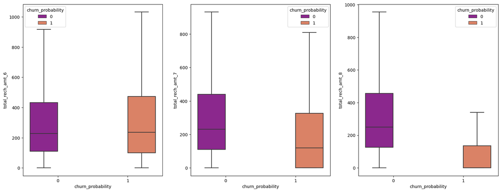

```python
# Ploting for total recharge amount:
plot_month_wise_box_chart('total_rech_amt', telecom)
```

We can see a drop in the total recharge amount for churned customers in the 8th Month.

#### Ploting for total recharge amount for data

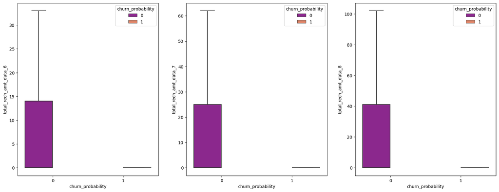

```python
# Ploting for total recharge amount for data:
plot_month_wise_box_chart('total_rech_amt_data', telecom)
```

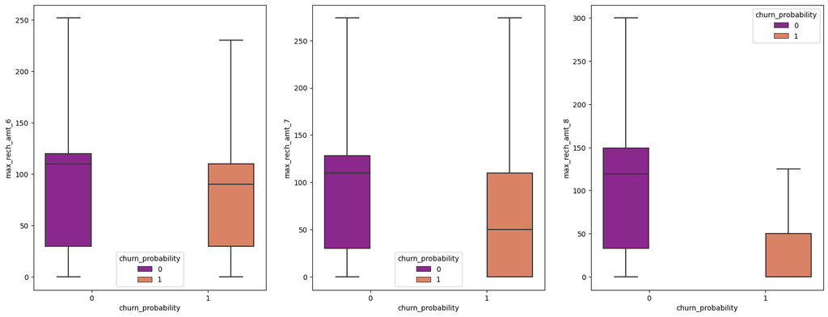

```python
# Ploting for max recharge amount for data:
plot_month_wise_box_chart('max_rech_amt', telecom)
```

```python
vbc_column = telecom.columns[telecom.columns.str.contains('vbc_3g',regex=True)]
vbc_column.tolist()
```

```
['vbc_3g_8', 'vbc_3g_7', 'vbc_3g_6']
```

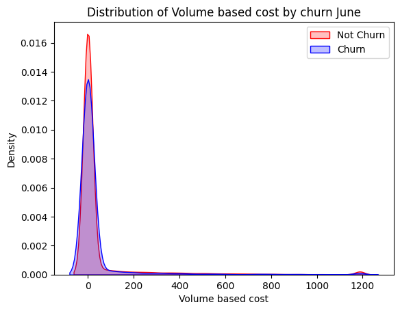

```python
ax = sns.kdeplot(telecom.vbc_3g_6[(telecom["churn_probability"] == 0)],
                color="Red", shade = True)
ax = sns.kdeplot(telecom.vbc_3g_6[(telecom["churn_probability"] == 1)],
                ax =ax, color="Blue", shade= True)
ax.legend(["Not Churn","Churn"],loc='upper right')
ax.set_ylabel('Density')
ax.set_xlabel('Volume based cost')
ax.set_title('Distribution of Volume based cost by churn June')
```

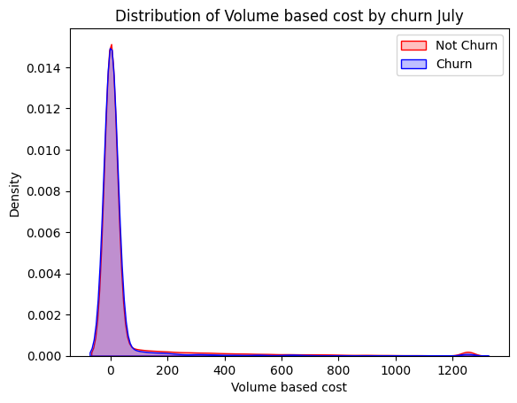

```python
ax = sns.kdeplot(telecom.vbc_3g_7[(telecom["churn_probability"] == 0)],
                color="Red", shade = True)
ax = sns.kdeplot(telecom.vbc_3g_7[(telecom["churn_probability"] == 1)],
                ax =ax, color="Blue", shade= True)
ax.legend(["Not Churn","Churn"],loc='upper right')
ax.set_ylabel('Density')
ax.set_xlabel('Volume based cost')
ax.set_title('Distribution of Volume based cost by churn July')
```

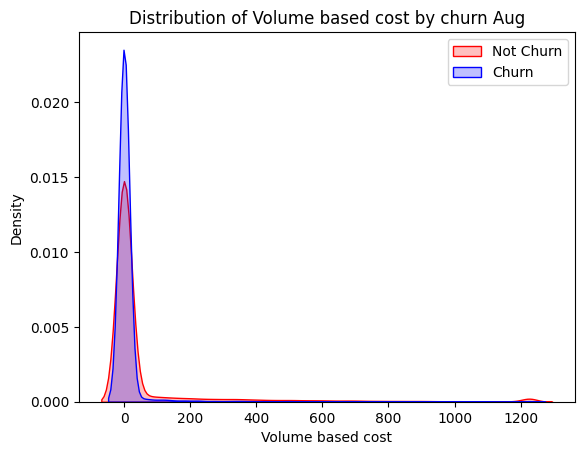

```python
ax = sns.kdeplot(telecom.vbc_3g_8[(telecom["churn_probability"] == 0)],
                color="Red", shade = True)
ax = sns.kdeplot(telecom.vbc_3g_8[(telecom["churn_probability"] == 1)],
                ax =ax, color="Blue", shade= True)
ax.legend(["Not Churn","Churn"],loc='upper right')
ax.set_ylabel('Density')
ax.set_xlabel('Volume based cost')
ax.set_title('Distribution of Volume based cost by churn Aug')
```

#### Average Revenue Per User

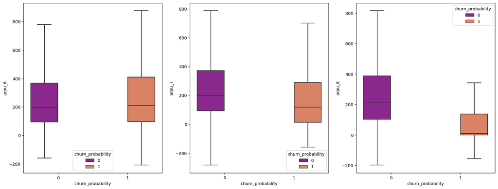

```python
# Checking columns for average revenue per user
arpu_cols = telecom.columns[telecom.columns.str.contains('arpu_')]

# Plotting arpu
plot_month_wise_box_chart('arpu', telecom)
```

We can see that huge drops for Arpu in 8th month for churned customers

#### MOU columns

```python
mou_cols = telecom.columns[telecom.columns.str.contains('mou')]
mou_cols
```

```
Index(['onnet_mou_6', 'onnet_mou_7', 'onnet_mou_8', 'offnet_mou_6',
       'offnet_mou_7', 'offnet_mou_8', 'roam_ic_mou_6', 'roam_ic_mou_7',
       'roam_ic_mou_8', 'roam_og_mou_6', 'roam_og_mou_7', 'roam_og_mou_8',
       'loc_og_t2t_mou_6', 'loc_og_t2t_mou_7', 'loc_og_t2t_mou_8',
       'loc_og_t2m_mou_6', 'loc_og_t2m_mou_7', 'loc_og_t2m_mou_8',
       'loc_og_t2f_mou_6', 'loc_og_t2f_mou_7', 'loc_og_t2f_mou_8',
       'loc_og_t2c_mou_6', 'loc_og_t2c_mou_7', 'loc_og_t2c_mou_8',
       'loc_og_mou_6', 'loc_og_mou_7', 'loc_og_mou_8', 'std_og_t2t_mou_6',
       'std_og_t2t_mou_7', 'std_og_t2t_mou_8', 'std_og_t2m_mou_6',
       'std_og_t2m_mou_7', 'std_og_t2m_mou_8', 'std_og_t2f_mou_6',
       'std_og_t2f_mou_7', 'std_og_t2f_mou_8', 'std_og_mou_6', 'std_og_mou_7',
       'std_og_mou_8', 'isd_og_mou_6', 'isd_og_mou_7', 'isd_og_mou_8',
       'spl_og_mou_6', 'spl_og_mou_7', 'spl_og_mou_8', 'total_og_mou_6',
       'total_og_mou_7', 'total_og_mou_8', 'loc_ic_t2t_mou_6',
       'loc_ic_t2t_mou_7', 'loc_ic_t2t_mou_8', 'loc_ic_t2m_mou_6',
       'loc_ic_t2m_mou_7', 'loc_ic_t2m_mou_8', 'loc_ic_t2f_mou_6',
       'loc_ic_t2f_mou_7', 'loc_ic_t2f_mou_8', 'loc_ic_mou_6', 'loc_ic_mou_7',
       'loc_ic_mou_8', 'std_ic_t2t_mou_6', 'std_ic_t2t_mou_7',
       'std_ic_t2t_mou_8', 'std_ic_t2m_mou_6', 'std_ic_t2m_mou_7',
       'std_ic_t2m_mou_8', 'std_ic_t2f_mou_6', 'std_ic_t2f_mou_7',
       'std_ic_t2f_mou_8', 'std_ic_mou_6', 'std_ic_mou_7', 'std_ic_mou_8',
       'total_ic_mou_6', 'total_ic_mou_7', 'total_ic_mou_8', 'spl_ic_mou_6',
       'spl_ic_mou_7', 'spl_ic_mou_8', 'isd_ic_mou_6', 'isd_ic_mou_7',
       'isd_ic_mou_8'],
      dtype='object')
```

```python
PlotAsTable(metadata_display(telecom[mou_cols], "Null_Percentage", False), "MOU Null Percentage Sorted")
```

```
-----------------------------------------------------------------------------------------------------
 Note: If you dont see the table 'MOU Null Percentage Sorted' below,
 please ensure the Jupyter Notebook is marked Trusted (File --> Trusted Notebook)
-----------------------------------------------------------------------------------------------------
```

MOU Null Percentage Sorted

| Columns | Datatype | Non_Null_Count | Null_Count | Null_Percentage | Unique_Values_Count |
| --- | --- | --- | --- | --- | --- |
| isd_ic_mou_8 | float64 | 66296 | 3703 | 5.29 | 4038 |
| loc_ic_t2t_mou_8 | float64 | 66296 | 3703 | 5.29 | 10786 |
| loc_ic_t2m_mou_8 | float64 | 66296 | 3703 | 5.29 | 18365 |
| std_og_t2t_mou_8 | float64 | 66296 | 3703 | 5.29 | 13826 |
| loc_og_t2c_mou_8 | float64 | 66296 | 3703 | 5.29 | 1636 |
| loc_ic_t2f_mou_8 | float64 | 66296 | 3703 | 5.29 | 5442 |
| loc_og_t2f_mou_8 | float64 | 66296 | 3703 | 5.29 | 2692 |
| loc_ic_mou_8 | float64 | 66296 | 3703 | 5.29 | 23523 |
| std_og_mou_8 | float64 | 66296 | 3703 | 5.29 | 21085 |
| loc_og_t2m_mou_8 | float64 | 66296 | 3703 | 5.29 | 16955 |
| std_ic_t2t_mou_8 | float64 | 66296 | 3703 | 5.29 | 4720 |
| spl_og_mou_8 | float64 | 66296 | 3703 | 5.29 | 3225 |
| loc_og_t2t_mou_8 | float64 | 66296 | 3703 | 5.29 | 10638 |
| std_ic_t2m_mou_8 | float64 | 66296 | 3703 | 5.29 | 7247 |
| std_og_t2m_mou_8 | float64 | 66296 | 3703 | 5.29 | 15312 |
| roam_og_mou_8 | float64 | 66296 | 3703 | 5.29 | 4564 |
| std_ic_t2f_mou_8 | float64 | 66296 | 3703 | 5.29 | 1968 |
| roam_ic_mou_8 | float64 | 66296 | 3703 | 5.29 | 3598 |
| std_ic_mou_8 | float64 | 66296 | 3703 | 5.29 | 9285 |
| isd_og_mou_8 | float64 | 66296 | 3703 | 5.29 | 407 |
| offnet_mou_8 | float64 | 66296 | 3703 | 5.29 | 25334 |
| spl_ic_mou_8 | float64 | 66296 | 3703 | 5.29 | 57 |
| std_og_t2f_mou_8 | float64 | 66296 | 3703 | 5.29 | 1354 |
| onnet_mou_8 | float64 | 66296 | 3703 | 5.29 | 19066 |
| loc_og_mou_8 | float64 | 66296 | 3703 | 5.29 | 21294 |
| spl_og_mou_6 | float64 | 67231 | 2768 | 3.95 | 2872 |
| loc_ic_t2t_mou_6 | float64 | 67231 | 2768 | 3.95 | 10969 |
| std_ic_t2t_mou_6 | float64 | 67231 | 2768 | 3.95 | 4666 |
| loc_ic_t2m_mou_6 | float64 | 67231 | 2768 | 3.95 | 18367 |
| loc_ic_t2f_mou_6 | float64 | 67231 | 2768 | 3.95 | 5549 |

[output cut: 51 more lines]

So for all minutes of usage columns the maximum missing % is 5.29 , means in these case the customer has not been used at all for that particular call type, thus we can fill the missing values with zero

```python
# replacing null values by 0 for minutes of usage variables
def ImputeMOUCols(df):
    df.loc[:,mou_cols] = df.loc[:,mou_cols].replace(np.NaN,0)

ImputeMOUCols(telecom)
```

```python
percent_missing = ReturnColumnsMissingPercentage(telecom)

PlotAsTable(percent_missing, "Missing Percentage EDA")
```

```
-----------------------------------------------------------------------------------------------------
 Note: If you dont see the table 'Missing Percentage EDA' below,
 please ensure the Jupyter Notebook is marked Trusted (File --> Trusted Notebook)
-----------------------------------------------------------------------------------------------------
```

Missing Percentage EDA

| index | MissingPercentage |
| --- | --- |
| id | 0 |
| arpu_6 | 0 |
| arpu_7 | 0 |
| arpu_8 | 0 |
| onnet_mou_6 | 0 |
| onnet_mou_7 | 0 |
| onnet_mou_8 | 0 |
| offnet_mou_6 | 0 |
| offnet_mou_7 | 0 |
| offnet_mou_8 | 0 |
| roam_ic_mou_6 | 0 |
| roam_ic_mou_7 | 0 |
| roam_ic_mou_8 | 0 |
| roam_og_mou_6 | 0 |
| roam_og_mou_7 | 0 |
| roam_og_mou_8 | 0 |
| loc_og_t2t_mou_6 | 0 |
| loc_og_t2t_mou_7 | 0 |
| loc_og_t2t_mou_8 | 0 |
| loc_og_t2m_mou_6 | 0 |
| loc_og_t2m_mou_7 | 0 |
| loc_og_t2m_mou_8 | 0 |
| loc_og_t2f_mou_6 | 0 |
| loc_og_t2f_mou_7 | 0 |
| loc_og_t2f_mou_8 | 0 |
| loc_og_t2c_mou_6 | 0 |
| loc_og_t2c_mou_7 | 0 |
| loc_og_t2c_mou_8 | 0 |
| loc_og_mou_6 | 0 |
| loc_og_mou_7 | 0 |

[output cut: 108 more lines]

```python
telecom.info()
```

```
<class 'pandas.core.frame.DataFrame'>
RangeIndex: 69999 entries, 0 to 69998
Columns: 138 entries, id to total_rech_amt_data_8
dtypes: category(13), datetime64[ns](3), float64(110), int64(12)
memory usage: 67.6 MB
```

```python
numeric_col = ['og_others_8', 'ic_others_8', 'og_others_6','ic_others_6', 'og_others_7', 'ic_others_7']
```

```python
def ImputeNumericColumns(df):
    for i in numeric_col:
        df.loc[df[i].isnull(),i]=0

ImputeNumericColumns(telecom)
```

```python
# Visalizing the correlation between the numerical variables
corr = telecom.corr()
```

```python
# function to correlate variables
def correlation(cor0) :
    type(cor0)
    cor0.where(np.triu(np.ones(cor0.shape),k=1).astype(np.bool))
    cor0=cor0.unstack().reset_index()
    cor0.columns=['VAR1','VAR2','CORR']
    cor0.dropna(subset=['CORR'], inplace=True)
    cor0.CORR=round(cor0['CORR'],2)
    cor0.CORR=cor0.CORR.abs()
    cor0.sort_values(by=['CORR'],ascending=False)
    cor0=cor0[~(cor0['VAR1']==cor0['VAR2'])]

    # removing duplicate correlations
    cor0['pair'] = cor0[['VAR1', 'VAR2']].apply(lambda x: '{}-{}'.format(*sorted((x[0], x[1]))), axis=1)

    cor0 = cor0.drop_duplicates(subset=['pair'], keep='first')
    cor0 = cor0[['VAR1', 'VAR2','CORR']]
    return pd.DataFrame(cor0.sort_values(by=['CORR'],ascending=False))
```

```python
cor_0 = correlation(corr)

# filtering for correlations >= 40%
condition = cor_0['CORR'] > 0.4
cor_0 = cor_0[condition]
PlotAsTable(cor_0, "Correlation Matrix (>40%) Sorted")
```

```
-----------------------------------------------------------------------------------------------------
 Note: If you dont see the table 'Correlation Matrix (>40%) Sorted' below,
 please ensure the Jupyter Notebook is marked Trusted (File --> Trusted Notebook)
-----------------------------------------------------------------------------------------------------
```

Correlation Matrix (>40%) Sorted

| VAR1 | VAR2 | CORR |
| --- | --- | --- |
| arpu_7 | total_rech_amt_7 | 0.95 |
| arpu_8 | total_rech_amt_8 | 0.95 |
| arpu_6 | total_rech_amt_6 | 0.95 |
| loc_ic_mou_7 | total_ic_mou_7 | 0.91 |
| loc_ic_mou_6 | total_ic_mou_6 | 0.91 |
| loc_ic_mou_8 | total_ic_mou_8 | 0.91 |
| loc_og_t2m_mou_6 | loc_og_mou_6 | 0.89 |
| loc_og_t2m_mou_8 | loc_og_mou_8 | 0.89 |
| loc_ic_t2m_mou_8 | loc_ic_mou_8 | 0.89 |
| loc_ic_t2m_mou_7 | loc_ic_mou_7 | 0.88 |
| onnet_mou_8 | std_og_t2t_mou_8 | 0.88 |
| loc_ic_t2m_mou_6 | loc_ic_mou_6 | 0.88 |
| loc_og_t2m_mou_7 | loc_og_mou_7 | 0.88 |
| onnet_mou_7 | std_og_t2t_mou_7 | 0.88 |
| std_ic_t2m_mou_8 | std_ic_mou_8 | 0.87 |
| std_ic_t2m_mou_7 | std_ic_mou_7 | 0.87 |
| std_ic_t2m_mou_6 | std_ic_mou_6 | 0.87 |
| onnet_mou_6 | std_og_t2t_mou_6 | 0.87 |
| total_rech_data_8 | total_rech_amt_data_8 | 0.86 |
| total_rech_data_7 | total_rech_amt_data_7 | 0.86 |
| total_rech_data_6 | total_rech_amt_data_6 | 0.86 |
| loc_og_mou_7 | loc_og_mou_8 | 0.85 |
| std_og_mou_7 | total_og_mou_7 | 0.85 |
| std_og_mou_8 | total_og_mou_8 | 0.85 |
| loc_ic_mou_7 | loc_ic_mou_8 | 0.84 |
| loc_og_t2t_mou_7 | loc_og_t2t_mou_8 | 0.83 |
| total_ic_mou_7 | total_ic_mou_8 | 0.83 |
| loc_og_mou_6 | loc_og_mou_7 | 0.83 |
| loc_og_t2m_mou_7 | loc_og_t2m_mou_8 | 0.83 |
| std_og_mou_6 | total_og_mou_6 | 0.83 |

[output cut: 558 more lines]

### Feature Engineering and Variable Transformation

#### Derived Features

##### Delta variables: Derived variables to measure change in usage/revenue between August and previous months average (June, July)

```python
# Derived variables to measure change in usage between August and previous months average (June, July)

# Usage
def CalculateDeltaCols(data):
    data['delta_vol_2g'] = data['vol_2g_mb_8'] - data['vol_2g_mb_6'].add(data['vol_2g_mb_7']).div(2)
    data['delta_vol_3g'] = data['vol_3g_mb_8'] - data['vol_3g_mb_6'].add(data['vol_3g_mb_7']).div(2)
    data['delta_total_og_mou'] = data['total_og_mou_8'] - data['total_og_mou_6'].add(data['total_og_mou_7']).div(2)
    data['delta_total_ic_mou'] = data['total_ic_mou_8'] - data['total_ic_mou_6'].add(data['total_ic_mou_7']).div(2)
    data['delta_vbc_3g'] = data['vbc_3g_8'] - data['vbc_3g_6'].add(data['vbc_3g_7']).div(2)

    # Revenue
    data['delta_arpu'] = data['arpu_8'] - data['arpu_6'].add(data['arpu_7']).div(2)
    data['delta_total_rech_amt'] = data['total_rech_amt_8'] - data['total_rech_amt_6'].add(data['total_rech_amt_7']).div(2)
    # Removing variables used for derivation :
    data.drop(columns=[
     'vol_2g_mb_8', 'vol_2g_mb_6', 'vol_2g_mb_7',
      'vol_3g_mb_8'  , 'vol_3g_mb_6', 'vol_3g_mb_7' ,
        'total_og_mou_8','total_og_mou_6', 'total_og_mou_7',
        'total_ic_mou_8','total_ic_mou_6', 'total_ic_mou_7',
        'vbc_3g_8','vbc_3g_6','vbc_3g_7',
        'arpu_8','arpu_6','arpu_7',
        'total_rech_amt_8', 'total_rech_amt_6', 'total_rech_amt_7'

    ], inplace=True)

CalculateDeltaCols(telecom)
```

```python
# AON convert from days to months

def ConvertAONToMonths(df):
    df["aon_months"] = (df.aon / 30).astype(int, errors='ignore')
    df.drop(columns=['aon'], inplace=True)


ConvertAONToMonths(telecom)
```

```python
telecom.head()
```

|  | id | onnet_mou_6 | onnet_mou_7 | onnet_mou_8 | offnet_mou_6 | offnet_mou_7 | offnet_mou_8 | roam_ic_mou_6 | roam_ic_mou_7 | roam_ic_mou_8 | ... | total_rech_amt_data_7 | total_rech_amt_data_8 | delta_vol_2g | delta_vol_3g | delta_total_og_mou | delta_total_ic_mou | delta_vbc_3g | delta_arpu | delta_total_rech_amt | aon_months |
| --- | --- | --- | --- | --- | --- | --- | --- | --- | --- | --- | --- | --- | --- | --- | --- | --- | --- | --- | --- | --- | --- |
| 0 | 0 | 48.58 | 124.38 | 1.29 | 32.24 | 96.68 | 2.33 | 0.00 | 0.0 | 0.0 | ... | 0.0 | 0.0 | 0.000 | 0.00 | -147.815 | 8.120 | 0.0 | -51.6160 | -61.0 | 65 |
| 1 | 1 | 0.00 | 0.00 | 0.00 | 0.00 | 25.99 | 30.89 | 0.00 | 0.0 | 0.0 | ... | 145.0 | 0.0 | -176.455 | -1.98 | 16.295 | 3.600 | 0.0 | -18.4405 | -22.5 | 23 |
| 2 | 2 | 0.53 | 15.93 | 0.00 | 53.99 | 82.05 | 0.00 | 0.00 | 0.0 | 0.0 | ... | 0.0 | 0.0 | 0.000 | 0.00 | -77.925 | -42.420 | 0.0 | -81.9910 | -95.0 | 29 |
| 3 | 3 | 7.26 | 16.01 | 0.00 | 68.76 | 78.48 | 50.23 | 0.00 | 0.0 | 0.0 | ... | 0.0 | 0.0 | 0.000 | 0.00 | -32.165 | 11.195 | 0.0 | -69.7160 | -70.0 | 32 |
| 4 | 4 | 21.28 | 4.83 | 6.13 | 56.99 | 38.11 | 9.63 | 53.64 | 0.0 | 0.0 | ... | 1337.0 | 852.0 | -136.375 | 0.00 | -37.340 | 12.860 | 0.0 | -82.8845 | -91.0 | 21 |

5 rows × 124 columns

```python
ShowSummary(telecom)
```

```
<class 'pandas.core.frame.DataFrame'>
RangeIndex: 69999 entries, 0 to 69998
Data columns (total 124 columns):
 #    Column                 Non-Null Count  Dtype
---   ------                 --------------  -----
 0    id                     69999 non-null  int64
 1    onnet_mou_6            69999 non-null  float64
 2    onnet_mou_7            69999 non-null  float64
 3    onnet_mou_8            69999 non-null  float64
 4    offnet_mou_6           69999 non-null  float64
 5    offnet_mou_7           69999 non-null  float64
 6    offnet_mou_8           69999 non-null  float64
 7    roam_ic_mou_6          69999 non-null  float64
 8    roam_ic_mou_7          69999 non-null  float64
 9    roam_ic_mou_8          69999 non-null  float64
```

[output cut: 116 more lines]

#### Grouping Categorical column values with less Contribution

```python
categorical = telecom.dtypes == 'category'
categorical_vars = telecom.columns[categorical].to_list()
ind_categorical_vars = list(set(categorical_vars) - {'churn_probability'}) #independent categorical variables
ind_categorical_vars
```

```
['sachet_3g_6',
 'sachet_2g_8',
 'monthly_2g_6',
 'monthly_2g_8',
 'sachet_2g_6',
 'monthly_3g_7',
 'sachet_3g_8',
 'sachet_2g_7',
 'monthly_3g_8',
 'sachet_3g_7',
 'monthly_3g_6',
 'monthly_2g_7']
```

```python
# Finding & Grouping categories with less than 1% contribution in each column into "Others"
def GroupAsOtherInCategorical(data):
    for col in ind_categorical_vars :
        category_counts = 100*data[col
                                  ].value_counts(normalize=True)
        PlotAsTable(pd.DataFrame(category_counts),f"{col} categorical_counts")
        low_count_categories = category_counts[category_counts <= 1].index.to_list()
        print(f"Replaced {low_count_categories} in {col} with category : Others")
        data[col].replace(low_count_categories,'Others',inplace=True)
```

```python
GroupAsOtherInCategorical(telecom)
ShowSummary(telecom)
```

```
-----------------------------------------------------------------------------------------------------
 Note: If you dont see the table 'sachet_3g_6 categorical_counts' below,
 please ensure the Jupyter Notebook is marked Trusted (File --> Trusted Notebook)
-----------------------------------------------------------------------------------------------------
```

sachet_3g_6 categorical_counts

| sachet_3g_6 |
| --- |
| 95.8414 |
| 2.9529 |
| 0.610009 |
| 0.21286 |
| 0.108573 |
| 0.0657152 |
| 0.0514293 |
| 0.0485721 |
| 0.0242861 |
| 0.0228575 |
| 0.0142859 |
| 0.0100001 |
| 0.00571437 |
| 0.00428578 |
| 0.00428578 |
| 0.00428578 |
| 0.00428578 |
| 0.00428578 |
| 0.00285718 |
| 0.00285718 |
| 0.00142859 |
| 0.00142859 |
| 0.00142859 |

```
Replaced [2, 3, 4, 5, 7, 6, 8, 9, 11, 10, 15, 12, 13, 14, 19, 23, 22, 29, 16, 17, 18] in sachet_3g_6 with category : Others
-----------------------------------------------------------------------------------------------------
 Note: If you dont see the table 'sachet_2g_8 categorical_counts' below,
 please ensure the Jupyter Notebook is marked Trusted (File --> Trusted Notebook)
-----------------------------------------------------------------------------------------------------
```

sachet_2g_8 categorical_counts

| sachet_2g_8 |
| --- |
| 85.9269 |
| 5.81723 |
| 2.44575 |
| 1.43859 |
| 1.1643 |
| 0.87287 |
| 0.614294 |
| 0.402863 |
| 0.357148 |
| 0.217146 |
| 0.198574 |
| 0.148574 |
| 0.132859 |
| 0.0585723 |
| 0.0557151 |
| 0.0357148 |
| 0.0285718 |
| 0.0142859 |
| 0.0142859 |
| 0.0114287 |
| 0.0100001 |
| 0.00571437 |
| 0.00571437 |
| 0.00428578 |
| 0.00285718 |
| 0.00285718 |
| 0.00285718 |
| 0.00285718 |
| 0.00285718 |
| 0.00142859 |
| 0.00142859 |
| 0.00142859 |

```
Replaced [5, 6, 7, 8, 9, 10, 11, 12, 14, 13, 16, 15, 17, 18, 20, 19, 22, 24, 29, 21, 23, 25, 27, 32, 31, 34, 44] in sachet_2g_8 with category : Others
-----------------------------------------------------------------------------------------------------
 Note: If you dont see the table 'monthly_2g_6 categorical_counts' below,
 please ensure the Jupyter Notebook is marked Trusted (File --> Trusted Notebook)
-----------------------------------------------------------------------------------------------------
```

monthly_2g_6 categorical_counts

| monthly_2g_6 |
| --- |
| 92.7099 |
| 6.69724 |
| 0.555722 |
| 0.0285718 |
| 0.00857155 |

```
Replaced [2, 3, 4] in monthly_2g_6 with category : Others
-----------------------------------------------------------------------------------------------------
 Note: If you dont see the table 'monthly_2g_8 categorical_counts' below,
 please ensure the Jupyter Notebook is marked Trusted (File --> Trusted Notebook)
-----------------------------------------------------------------------------------------------------
```

monthly_2g_8 categorical_counts

| monthly_2g_8 |
| --- |
| 92.597 |
| 6.76867 |
| 0.590008 |
| 0.0342862 |
| 0.00857155 |
| 0.00142859 |

```
Replaced [2, 3, 4, 5] in monthly_2g_8 with category : Others
-----------------------------------------------------------------------------------------------------
 Note: If you dont see the table 'sachet_2g_6 categorical_counts' below,
 please ensure the Jupyter Notebook is marked Trusted (File --> Trusted Notebook)
-----------------------------------------------------------------------------------------------------
```

sachet_2g_6 categorical_counts

| sachet_2g_6 |
| --- |
| 87.1184 |
| 5.56865 |
| 2.49146 |
| 1.33716 |
| 0.924299 |
| 0.591437 |
| 0.465721 |
| 0.337148 |
| 0.302861 |
| 0.217146 |
| 0.188574 |
| 0.130002 |
| 0.114287 |
| 0.0528579 |
| 0.0471435 |
| 0.0285718 |
| 0.0200003 |
| 0.0157145 |
| 0.0114287 |
| 0.00714296 |
| 0.00714296 |
| 0.00571437 |
| 0.00428578 |
| 0.00428578 |
| 0.00142859 |
| 0.00142859 |
| 0.00142859 |
| 0.00142859 |
| 0.00142859 |
| 0.00142859 |

```
Replaced [4, 5, 6, 7, 8, 9, 10, 11, 12, 13, 14, 15, 16, 17, 19, 18, 22, 21, 20, 25, 24, 28, 30, 32, 34, 42] in sachet_2g_6 with category : Others
-----------------------------------------------------------------------------------------------------
 Note: If you dont see the table 'monthly_3g_7 categorical_counts' below,
 please ensure the Jupyter Notebook is marked Trusted (File --> Trusted Notebook)
-----------------------------------------------------------------------------------------------------
```

monthly_3g_7 categorical_counts

| monthly_3g_7 |
| --- |
| 94.3756 |
| 4.22006 |
| 1.01573 |
| 0.23286 |
| 0.0685724 |
| 0.038572 |
| 0.0257147 |
| 0.00857155 |
| 0.00571437 |
| 0.00428578 |
| 0.00142859 |
| 0.00142859 |
| 0.00142859 |

```
Replaced [3, 4, 5, 6, 7, 8, 9, 10, 14, 16] in monthly_3g_7 with category : Others
-----------------------------------------------------------------------------------------------------
 Note: If you dont see the table 'sachet_3g_8 categorical_counts' below,
 please ensure the Jupyter Notebook is marked Trusted (File --> Trusted Notebook)
-----------------------------------------------------------------------------------------------------
```

sachet_3g_8 categorical_counts

| sachet_3g_8 |
| --- |
| 95.7999 |
| 2.8129 |
| 0.621437 |
| 0.270004 |
| 0.132859 |
| 0.108573 |
| 0.0514293 |
| 0.0442863 |
| 0.0357148 |
| 0.0228575 |
| 0.0185717 |
| 0.0142859 |
| 0.0128573 |
| 0.0128573 |
| 0.00714296 |
| 0.00428578 |
| 0.00428578 |
| 0.00428578 |
| 0.00428578 |
| 0.00285718 |
| 0.00285718 |
| 0.00285718 |
| 0.00142859 |
| 0.00142859 |
| 0.00142859 |
| 0.00142859 |
| 0.00142859 |
| 0.00142859 |

```
Replaced [2, 3, 4, 5, 6, 7, 8, 9, 10, 12, 11, 13, 15, 18, 20, 14, 16, 17, 21, 23, 19, 25, 29, 30, 38, 41] in sachet_3g_8 with category : Others
-----------------------------------------------------------------------------------------------------
 Note: If you dont see the table 'sachet_2g_7 categorical_counts' below,
 please ensure the Jupyter Notebook is marked Trusted (File --> Trusted Notebook)
-----------------------------------------------------------------------------------------------------
```

sachet_2g_7 categorical_counts

| sachet_2g_7 |
| --- |
| 86.6827 |
| 5.21722 |
| 2.44718 |
| 1.36716 |
| 1.09573 |
| 0.800011 |
| 0.607152 |
| 0.438578 |
| 0.33429 |
| 0.254289 |
| 0.19286 |
| 0.168574 |
| 0.132859 |
| 0.0600009 |
| 0.0500007 |
| 0.038572 |
| 0.0185717 |
| 0.0157145 |
| 0.0142859 |
| 0.0114287 |
| 0.0100001 |
| 0.00857155 |
| 0.00714296 |
| 0.00714296 |
| 0.00428578 |
| 0.00428578 |
| 0.00285718 |
| 0.00142859 |
| 0.00142859 |
| 0.00142859 |
| 0.00142859 |
| 0.00142859 |
| 0.00142859 |

```
Replaced [5, 6, 7, 8, 10, 9, 11, 12, 14, 13, 15, 16, 19, 18, 17, 20, 23, 21, 22, 26, 27, 32, 24, 25, 30, 35, 42, 48] in sachet_2g_7 with category : Others
-----------------------------------------------------------------------------------------------------
 Note: If you dont see the table 'monthly_3g_8 categorical_counts' below,
 please ensure the Jupyter Notebook is marked Trusted (File --> Trusted Notebook)
-----------------------------------------------------------------------------------------------------
```

monthly_3g_8 categorical_counts

| monthly_3g_8 |
| --- |
| 93.9856 |
| 4.54292 |
| 1.0543 |
| 0.261432 |
| 0.0928585 |
| 0.0342862 |
| 0.0100001 |
| 0.00857155 |
| 0.00428578 |
| 0.00285718 |
| 0.00142859 |
| 0.00142859 |

```
Replaced [3, 4, 5, 6, 7, 8, 9, 10, 16] in monthly_3g_8 with category : Others
-----------------------------------------------------------------------------------------------------
 Note: If you dont see the table 'sachet_3g_7 categorical_counts' below,
 please ensure the Jupyter Notebook is marked Trusted (File --> Trusted Notebook)
-----------------------------------------------------------------------------------------------------
```

sachet_3g_7 categorical_counts

| sachet_3g_7 |
| --- |
| 95.8599 |
| 2.78718 |
| 0.652866 |
| 0.237146 |
| 0.124287 |
| 0.102859 |
| 0.070001 |
| 0.038572 |
| 0.0200003 |
| 0.0171431 |
| 0.0157145 |
| 0.0157145 |
| 0.0128573 |
| 0.00857155 |
| 0.00714296 |
| 0.00428578 |
| 0.00428578 |
| 0.00428578 |
| 0.00285718 |
| 0.00285718 |
| 0.00285718 |
| 0.00285718 |
| 0.00142859 |
| 0.00142859 |
| 0.00142859 |
| 0.00142859 |

```
Replaced [2, 3, 4, 5, 6, 7, 8, 11, 9, 10, 12, 14, 15, 20, 22, 18, 24, 13, 19, 17, 21, 16, 31, 33] in sachet_3g_7 with category : Others
-----------------------------------------------------------------------------------------------------
 Note: If you dont see the table 'monthly_3g_6 categorical_counts' below,
 please ensure the Jupyter Notebook is marked Trusted (File --> Trusted Notebook)
-----------------------------------------------------------------------------------------------------
```

monthly_3g_6 categorical_counts

| monthly_3g_6 |
| --- |
| 94.2728 |
| 4.50006 |
| 0.850012 |
| 0.238575 |
| 0.0842869 |
| 0.0228575 |
| 0.0142859 |
| 0.0114287 |
| 0.00285718 |
| 0.00285718 |

```
Replaced [2, 3, 4, 5, 6, 7, 8, 9] in monthly_3g_6 with category : Others
-----------------------------------------------------------------------------------------------------
 Note: If you dont see the table 'monthly_2g_7 categorical_counts' below,
 please ensure the Jupyter Notebook is marked Trusted (File --> Trusted Notebook)
-----------------------------------------------------------------------------------------------------
```

monthly_2g_7 categorical_counts

| monthly_2g_7 |
| --- |
| 92.4227 |
| 6.86581 |
| 0.667152 |
| 0.038572 |
| 0.00428578 |
| 0.00142859 |

```
Replaced [2, 3, 4, 5] in monthly_2g_7 with category : Others
<class 'pandas.core.frame.DataFrame'>
RangeIndex: 69999 entries, 0 to 69998
Data columns (total 124 columns):
 #    Column                 Non-Null Count  Dtype
---   ------                 --------------  -----
 0    id                     69999 non-null  int64
 1    onnet_mou_6            69999 non-null  float64
 2    onnet_mou_7            69999 non-null  float64
 3    onnet_mou_8            69999 non-null  float64
 4    offnet_mou_6           69999 non-null  float64
 5    offnet_mou_7           69999 non-null  float64
 6    offnet_mou_8           69999 non-null  float64
 7    roam_ic_mou_6          69999 non-null  float64
 8    roam_ic_mou_7          69999 non-null  float64
```

[output cut: 117 more lines]

#### Dummy Variable

```python
def CreateDummyVars(data):
    dummy_vars = pd.get_dummies(data[ind_categorical_vars], drop_first=False, prefix=ind_categorical_vars, prefix_sep='_')
    dummy_vars.head()
    reference_cols = dummy_vars.filter(regex='.*Others$').columns.to_list() # Using category 'Others' in each column as reference.
    dummy_vars.drop(columns=reference_cols, inplace=True)
    reference_cols
    data.drop(columns=ind_categorical_vars, inplace=True) # dropping original categorical columns
    data = pd.concat([data, dummy_vars], axis=1)
    data.head()
    dummy_cols = dummy_vars.columns.to_list()
    data[dummy_cols] = data[dummy_cols].astype('category')
    return data

def DropDateCols(data):
    data.drop(data.filter(regex='date_').columns,axis=1,inplace=True)

telecom = CreateDummyVars(telecom)
DropDateCols(telecom)
ShowSummary(telecom)
```

```
<class 'pandas.core.frame.DataFrame'>
RangeIndex: 69999 entries, 0 to 69998
Data columns (total 143 columns):
 #    Column                 Non-Null Count  Dtype
---   ------                 --------------  -----
 0    id                     69999 non-null  int64
 1    onnet_mou_6            69999 non-null  float64
 2    onnet_mou_7            69999 non-null  float64
 3    onnet_mou_8            69999 non-null  float64
 4    offnet_mou_6           69999 non-null  float64
 5    offnet_mou_7           69999 non-null  float64
 6    offnet_mou_8           69999 non-null  float64
 7    roam_ic_mou_6          69999 non-null  float64
 8    roam_ic_mou_7          69999 non-null  float64
 9    roam_ic_mou_8          69999 non-null  float64
```

[output cut: 135 more lines]

```python
telecom.shape
```

```
(69999, 143)
```

### Next section contains:

#### Test Train Split

#### Class Imbalance

#### Standardization

#### Modelling

- Model 1 : Logistic Regression with RFE & Manual Elimination ( Interpretable Model )
- Model 2 : PCA + Logistic Regression
- Model 3 : PCA + Random Forest Classifier
- Model 4 : PCA + XGBoost

### Test Train Split

```python
telecom.dropna()
y = telecom["churn_probability"].astype(int, errors='ignore')
X = telecom.drop(["churn_probability","id"],axis=1)
X.index = telecom["id"]

X_train, X_test, y_train, y_test = train_test_split(X,y, train_size=0.7, random_state=42)
```

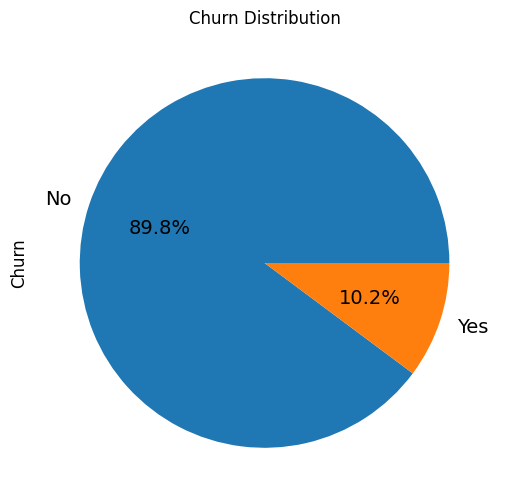

```python
#Churn Distribution
pie_chart = y.value_counts()*100.0 /len(y)
ax = pie_chart.plot.pie(autopct='%.1f%%', labels = ['No', 'Yes'],figsize =(8,6), fontsize = 14 )
ax.set_ylabel('Churn',fontsize = 12)
ax.set_title('Churn Distribution', fontsize = 12)
plt.show()
```

### Standardizing Columns

```python
# columns with numerical data
condition1 = X.dtypes == 'int'
condition2 = X.dtypes == 'float'
numerical_vars = X.columns[condition1 | condition2].to_list()
```

```python
# Standard scaling
scaler = StandardScaler()

# Fit and transform train set
X_train[numerical_vars] = scaler.fit_transform(X_train[numerical_vars])

# Transform test set
X_test[numerical_vars] = scaler.transform(X_test[numerical_vars])

X_train.describe()
```

|  | onnet_mou_6 | onnet_mou_7 | onnet_mou_8 | offnet_mou_6 | offnet_mou_7 | offnet_mou_8 | roam_ic_mou_6 | roam_ic_mou_7 | roam_ic_mou_8 | roam_og_mou_6 | ... | total_rech_amt_data_7 | total_rech_amt_data_8 | delta_vol_2g | delta_vol_3g | delta_total_og_mou | delta_total_ic_mou | delta_vbc_3g | delta_arpu | delta_total_rech_amt | aon_months |
| --- | --- | --- | --- | --- | --- | --- | --- | --- | --- | --- | --- | --- | --- | --- | --- | --- | --- | --- | --- | --- | --- |
| count | 4.899900e+04 | 4.899900e+04 | 4.899900e+04 | 4.899900e+04 | 4.899900e+04 | 4.899900e+04 | 4.899900e+04 | 4.899900e+04 | 4.899900e+04 | 4.899900e+04 | ... | 4.899900e+04 | 4.899900e+04 | 4.899900e+04 | 4.899900e+04 | 4.899900e+04 | 4.899900e+04 | 4.899900e+04 | 4.899900e+04 | 4.899900e+04 | 4.899900e+04 |
| mean | 3.364271e-17 | -2.624711e-17 | -8.700701e-18 | 9.048729e-17 | 6.017985e-17 | -1.226799e-16 | 7.540607e-18 | -9.570771e-18 | -1.595128e-17 | -4.582369e-17 | ... | -6.815549e-17 | -4.350350e-18 | 1.392112e-17 | -1.377611e-17 | -6.960561e-18 | 4.930397e-18 | 1.602379e-17 | -5.800467e-19 | 2.320187e-18 | 1.856150e-17 |
| std | 1.000010e+00 | 1.000010e+00 | 1.000010e+00 | 1.000010e+00 | 1.000010e+00 | 1.000010e+00 | 1.000010e+00 | 1.000010e+00 | 1.000010e+00 | 1.000010e+00 | ... | 1.000010e+00 | 1.000010e+00 | 1.000010e+00 | 1.000010e+00 | 1.000010e+00 | 1.000010e+00 | 1.000010e+00 | 1.000010e+00 | 1.000010e+00 | 1.000010e+00 |
| min | -5.056733e-01 | -4.958513e-01 | -4.921167e-01 | -6.952121e-01 | -6.855406e-01 | -6.818200e-01 | -2.474371e-01 | -2.239588e-01 | -2.202920e-01 | -2.669667e-01 | ... | -3.158894e-01 | -3.198908e-01 | -7.939264e+00 | -8.337432e+00 | -7.535326e+00 | -9.412602e+00 | -8.811266e+00 | -7.010198e+00 | -6.720701e+00 | -1.078905e+00 |
| 25% | -4.830130e-01 | -4.756027e-01 | -4.750416e-01 | -5.860899e-01 | -5.837791e-01 | -5.903120e-01 | -2.474371e-01 | -2.239588e-01 | -2.202920e-01 | -2.669667e-01 | ... | -3.158894e-01 | -3.198908e-01 | 9.286588e-03 | -3.642018e-02 | -2.213436e-01 | -2.895331e-01 | -3.928852e-02 | -4.101719e-01 | -4.277242e-01 | -7.946275e-01 |
| 50% | -3.770007e-01 | -3.765103e-01 | -3.766423e-01 | -3.576343e-01 | -3.627562e-01 | -3.648741e-01 | -2.474371e-01 | -2.239588e-01 | -2.202920e-01 | -2.669667e-01 | ... | -3.158894e-01 | -3.198908e-01 | 9.286588e-03 | -3.642018e-02 | 8.077982e-03 | 3.145085e-03 | -3.928852e-02 | -1.257410e-02 | -1.588357e-03 | -3.524183e-01 |
| 75% | -3.288779e-02 | -5.411525e-02 | -5.010574e-02 | 1.440601e-01 | 1.333803e-01 | 1.401526e-01 | -2.474371e-01 | -2.239588e-01 | -2.202920e-01 | -2.669667e-01 | ... | -2.795715e-01 | -2.671443e-01 | 9.286588e-03 | -3.642018e-02 | 2.138192e-01 | 2.877976e-01 | -3.928852e-02 | 3.926950e-01 | 4.186014e-01 | 6.267593e-01 |
| max | 5.522230e+00 | 5.503825e+00 | 5.595738e+00 | 5.131937e+00 | 5.098242e+00 | 5.115873e+00 | 7.102132e+00 | 7.451739e+00 | 7.651199e+00 | 6.769081e+00 | ... | 6.550457e+00 | 6.466103e+00 | 7.868771e+00 | 8.714964e+00 | 7.526624e+00 | 9.295670e+00 | 8.771378e+00 | 9.479331e+00 | 6.771078e+00 | 3.280015e+00 |

8 rows × 107 columns

### Modelling

### Model 1 : Baseline Logistic Regression Model (Interpretable Model) :

```python
baseline_model = LogisticRegression(random_state=100, class_weight='balanced') # `weight of class` balancing technique used
baseline_model = baseline_model.fit(X_train, y_train)

baseline_coefficients = baseline_model.coef_

y_train_pred = baseline_model.predict_proba(X_train)[:,1]
y_test_pred  = baseline_model.predict_proba(X_test)[:,1]
```

```python
y_train_pred = pd.Series(y_train_pred,index = X_train.index, ) # converting test and train to a series to preserve index
y_test_pred = pd.Series(y_test_pred,index = X_test.index)
```

```python
# Prediction at threshold of 0.5
classification_threshold = 0.5

y_train_pred_classified = y_train_pred.map(lambda x : 1 if x > classification_threshold else 0)
y_test_pred_classified = y_test_pred.map(lambda x : 1 if x > classification_threshold else 0)
```

```python
train_matrix = confusion_matrix(y_train, y_train_pred_classified)
print('Confusion Matrix for train:\n', train_matrix)
test_matrix = confusion_matrix(y_test, y_test_pred_classified)
print('\nConfusion Matrix for test: \n', test_matrix)
```

```
Confusion Matrix for train:
 [[34842  9180]
 [  747  4230]]

Confusion Matrix for test:
 [[14844  4001]
 [  297  1858]]
```

```python
def DisplayClassificationReport(y, y_p):
    rep = classification_report(y, y_p, labels=[0, 1])
    print(rep)
    return rep



report_train = DisplayClassificationReport(y_train, y_train_pred_classified)
report_test = DisplayClassificationReport(y_test, y_test_pred_classified)
```

```
              precision    recall  f1-score   support

           0       0.98      0.79      0.88     44022
           1       0.32      0.85      0.46      4977

    accuracy                           0.80     48999
   macro avg       0.65      0.82      0.67     48999
weighted avg       0.91      0.80      0.83     48999

              precision    recall  f1-score   support

           0       0.98      0.79      0.87     18845
           1       0.32      0.86      0.46      2155

    accuracy                           0.80     21000
   macro avg       0.65      0.82      0.67     21000
weighted avg       0.91      0.80      0.83     21000
```

**Baseline model Coeeficients**

```python
coeffient_df = pd.DataFrame({"columns" : list(X_train.columns) , "baseline_coefficients" : list(baseline_coefficients[0]) })

PlotAsTable(coeffient_df.sort_values(by='baseline_coefficients', ascending = False, key=abs), "Baseline model Coefficients")
```

```
-----------------------------------------------------------------------------------------------------
 Note: If you dont see the table 'Baseline model Coefficients' below,
 please ensure the Jupyter Notebook is marked Trusted (File --> Trusted Notebook)
-----------------------------------------------------------------------------------------------------
```

Baseline model Coefficients

| columns | baseline_coefficients |
| --- | --- |
| aon_months | -0.327769 |
| delta_total_ic_mou | -0.327664 |
| spl_ic_mou_8 | -0.326426 |
| roam_og_mou_8 | 0.26992 |
| loc_ic_t2m_mou_8 | -0.241128 |
| loc_ic_mou_8 | -0.239868 |
| loc_ic_t2t_mou_8 | -0.178816 |
| loc_ic_t2f_mou_8 | -0.160829 |
| loc_og_t2m_mou_8 | -0.138874 |
| roam_ic_mou_8 | 0.134955 |
| isd_og_mou_8 | 0.132096 |
| spl_ic_mou_7 | -0.131111 |
| loc_og_mou_8 | -0.129051 |
| std_ic_t2f_mou_8 | -0.119395 |
| delta_total_og_mou | -0.116189 |
| delta_vbc_3g | -0.103887 |
| isd_og_mou_7 | 0.0994905 |
| std_ic_mou_8 | -0.0991107 |
| loc_og_t2t_mou_8 | -0.0955863 |
| total_rech_num_8 | -0.0948075 |
| std_ic_t2m_mou_8 | -0.0930518 |
| loc_ic_t2m_mou_7 | -0.0908159 |
| total_rech_data_8 | -0.0870278 |
| spl_ic_mou_6 | -0.0869539 |
| isd_og_mou_6 | 0.0861188 |
| delta_arpu | -0.0726869 |
| ic_others_8 | -0.0725407 |
| delta_vol_2g | -0.071264 |
| std_og_t2f_mou_8 | -0.0674591 |
| delta_vol_3g | -0.0614914 |

[output cut: 111 more lines]

```python
def model_metrics(matrix, name) :
    TN = matrix[0][0]
    TP = matrix[1][1]
    FP = matrix[0][1]
    FN = matrix[1][0]
    print(f'{name} : \n' )
    accuracy = round((TP + TN)/float(TP+TN+FP+FN),3)
    print('Accuracy :' ,accuracy )
    sensitivity = round(TP/float(FN + TP),3)
    print('Sensitivity / True Positive Rate / Recall :', sensitivity)
    specificity = round(TN/float(TN + FP),3)
    print('Specificity / True Negative Rate : ', specificity)
    precision = round(TP/float(TP + FP),3)
    print('Precision / Positive Predictive Value :', precision)
    f1_score = round(2*precision*sensitivity/(precision + sensitivity),3)
    print('F1-score :', f1_score)
    return accuracy,sensitivity,specificity,precision,f1_score
```

```python
# Baseline Model Performance :
model_perf_df = pd.DataFrame(columns=['model','accuracy','sensitivity/recall', 'specificity',  'precision', 'f1-score'])

def PlotMetricsComparission(t = "Metrics by Model (sorted by accuracy)"):
    PlotAsTable(model_perf_df.sort_values(by='accuracy', ascending = False), t)

def AppendToModelPerfDF(corr_matrix, name):
    metrics = model_metrics(corr_matrix, name)
     #Combining the "name" value with the NumPy array metrics
    new_row = np.concatenate([[name], metrics])
    # Inserting the new row into the DataFrame using the loc method
    new_row_index = len(model_perf_df)
    model_perf_df.loc[new_row_index] = new_row

AppendToModelPerfDF(train_matrix,"Logistic Regr Train (0.5 Thres)")
AppendToModelPerfDF(test_matrix,"Logistic Regr Test (0.5 Thres)")
```

```
Logistic Regr Train (0.5 Thres) :

Accuracy : 0.797
Sensitivity / True Positive Rate / Recall : 0.85
Specificity / True Negative Rate :  0.791
Precision / Positive Predictive Value : 0.315
F1-score : 0.46
Logistic Regr Test (0.5 Thres) :

Accuracy : 0.795
Sensitivity / True Positive Rate / Recall : 0.862
Specificity / True Negative Rate :  0.788
Precision / Positive Predictive Value : 0.317
F1-score : 0.464
```

##### Baseline Performance - Finding Optimum Probability Cutoff

```python
# Specificity / Sensitivity Tradeoff

# Classification at probability thresholds between 0 and 1
def thresholder(x, thresh) :
    if x > thresh :
        return 1
    else :
        return 0

def CalculateProbablityThresholds(y_pred_now, X_now):
  y_train_pred_thres = pd.DataFrame(index=X_now.index)
  thresholds = [float(x)/10 for x in range(10)]
  for i in thresholds:
      y_train_pred_thres[i]= y_pred_now.map(lambda x : thresholder(x,i))
  print("Y pred by threshold: \n")
  print(y_train_pred_thres.head())
  return (thresholds, y_train_pred_thres)
```

```
Y pred by threshold:

       0.0  0.1  0.2  0.3  0.4  0.5  0.6  0.7  0.8  0.9
id
61787    1    1    1    0    0    0    0    0    0    0
19961    1    1    1    0    0    0    0    0    0    0
11040    1    0    0    0    0    0    0    0    0    0
27673    1    1    1    1    1    1    1    1    1    0
22876    1    1    1    0    0    0    0    0    0    0
Y pred metrics by threshold:

     precision  sensitivity/recall  specificity  accuracy
0.0      0.102               1.000        0.000     0.102
0.1      0.137               0.972        0.310     0.377
0.2      0.167               0.947        0.467     0.516
0.3      0.203               0.919        0.592     0.625
0.4      0.250               0.887        0.699     0.718
0.5      0.315               0.850        0.791     0.797
0.6      0.397               0.798        0.863     0.856
0.7      0.495               0.716        0.917     0.897
0.8      0.583               0.511        0.959     0.913
0.9      0.561               0.143        0.987     0.902
```

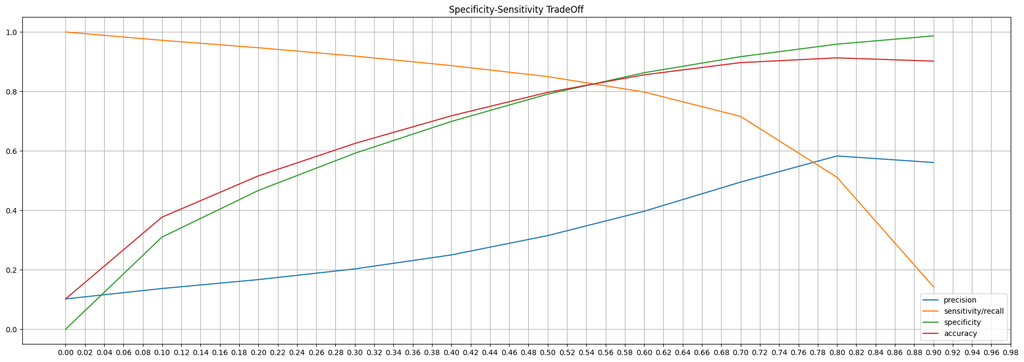

```python
# # sensitivity, specificity, accuracy for each threshold
# Function for calculation of metrics for each threshold
def model_metrics_thres(matrix) :
    TN = matrix[0][0]
    TP = matrix[1][1]
    FP = matrix[0][1]
    FN = matrix[1][0]
    accuracy = round((TP + TN)/float(TP+TN+FP+FN),3)
    sensitivity = round(TP/float(FN + TP),3)
    specificity = round(TN/float(TN + FP),3)
    precision = round(TP/float(TP + FP),3)
    return sensitivity,specificity,accuracy,precision

def ViewMetricsByThreshold(y_act, y_pred_now, X_now):
  metrics_df = pd.DataFrame(columns=['precision','sensitivity/recall', 'specificity', 'accuracy'])
  (thresholds, y_train_pred_thres) = CalculateProbablityThresholds(y_pred_now, X_now)
  # generating a data frame for metrics for each threshold
  for thres,column in zip(thresholds,y_train_pred_thres.columns.to_list()) :
      confusion = confusion_matrix(y_act, y_train_pred_thres.loc[:,column])
      sensitivity,specificity,accuracy,precision = model_metrics_thres(confusion)

      metrics_df =  metrics_df.append({
          'precision' : precision,
          'sensitivity/recall' :sensitivity,
          'specificity' : specificity,
          'accuracy' : accuracy
      }, ignore_index = True)

  metrics_df.index = thresholds
  print("Y pred metrics by threshold: \n")
  print(metrics_df)
  metrics_df.plot(kind='line', figsize=(24,8), grid=True, xticks=np.arange(0,1,0.02),
                title='Specificity-Sensitivity TradeOff');




ViewMetricsByThreshold(y_train, y_train_pred, X_train)
```

```python
optimum_cutoff = 0.53
y_train_pred_final = y_train_pred.map(lambda x : 1 if x > optimum_cutoff else 0)
y_test_pred_final = y_test_pred.map(lambda x : 1 if x > optimum_cutoff else 0)

train_matrix = confusion_matrix(y_train, y_train_pred_final)
print('Confusion Matrix for train:\n', train_matrix)
test_matrix = confusion_matrix(y_test, y_test_pred_final)
print('\nConfusion Matrix for test: \n', test_matrix)
```

```
Confusion Matrix for train:
 [[35854  8168]
 [  812  4165]]

Confusion Matrix for test:
 [[15290  3555]
 [  331  1824]]
```

```python
AppendToModelPerfDF(train_matrix,f"Logistic Regr Train (Optimal:{str(optimum_cutoff)} Thres)")
AppendToModelPerfDF(test_matrix,f"Logistic Regr Test (Optimal:{str(optimum_cutoff)} Thres)")
```

```
Logistic Regr Train (Optimal:0.53 Thres) :

Accuracy : 0.817
Sensitivity / True Positive Rate / Recall : 0.837
Specificity / True Negative Rate :  0.814
Precision / Positive Predictive Value : 0.338
F1-score : 0.482
Logistic Regr Test (Optimal:0.53 Thres) :

Accuracy : 0.815
Sensitivity / True Positive Rate / Recall : 0.846
Specificity / True Negative Rate :  0.811
Precision / Positive Predictive Value : 0.339
F1-score : 0.484
```

```python
report_train = DisplayClassificationReport(y_train, y_train_pred_classified)
report_test = DisplayClassificationReport(y_test, y_test_pred_classified)
```

```
              precision    recall  f1-score   support

           0       0.98      0.79      0.88     44022
           1       0.32      0.85      0.46      4977

    accuracy                           0.80     48999
   macro avg       0.65      0.82      0.67     48999
weighted avg       0.91      0.80      0.83     48999

              precision    recall  f1-score   support

           0       0.98      0.79      0.87     18845
           1       0.32      0.86      0.46      2155

    accuracy                           0.80     21000
   macro avg       0.65      0.82      0.67     21000
weighted avg       0.91      0.80      0.83     21000
```

```python
PlotMetricsComparission()
```

```
-----------------------------------------------------------------------------------------------------
 Note: If you dont see the table 'Metrics by Model (sorted by accuracy)' below,
 please ensure the Jupyter Notebook is marked Trusted (File --> Trusted Notebook)
-----------------------------------------------------------------------------------------------------
```

Metrics by Model (sorted by accuracy)

| model | accuracy | sensitivity/recall | specificity | precision | f1-score |
| --- | --- | --- | --- | --- | --- |
| Logistic Regr Train (Optimal:0.53 Thres) | 0.817 | 0.837 | 0.814 | 0.338 | 0.482 |
| Logistic Regr Test (Optimal:0.53 Thres) | 0.815 | 0.846 | 0.811 | 0.339 | 0.484 |
| Logistic Regr Train (0.5 Thres) | 0.797 | 0.85 | 0.791 | 0.315 | 0.46 |
| Logistic Regr Test (0.5 Thres) | 0.795 | 0.862 | 0.788 | 0.317 | 0.464 |

**Logistin Regression with RFE**

**RFE Feature selection**

```python
lr = LogisticRegression(random_state=100 , class_weight='balanced')
rfe = RFE(estimator=lr, n_features_to_select=15)
results = rfe.fit(X_train,y_train)
results.support_
```

```
array([False, False, False, False, False,  True, False, False, False,
       False, False, False, False, False, False, False, False,  True,
       False, False, False, False, False, False, False, False, False,
       False, False,  True, False, False, False, False, False, False,
       False, False,  True, False, False, False, False, False, False,
       False, False, False, False, False,  True, False, False,  True,
       False, False,  True, False, False,  True, False, False, False,
       False, False, False, False, False, False, False, False, False,
       False, False,  True, False, False, False, False, False, False,
       False, False, False, False, False, False, False, False, False,
       False, False,  True, False, False, False, False, False, False,
       False, False, False, False, False, False,  True,  True, False,
       False, False, False, False, False, False, False, False, False,
        True, False, False, False, False, False, False, False, False,
       False, False, False, False, False, False, False, False, False,
       False, False, False, False,  True,  True])
```

```python
# DataFrame with features supported by RFE
rfe_support = pd.DataFrame({'Column' : X.columns.to_list(), 'Rank' : rfe.ranking_,
                                      'Support' :  rfe.support_}).sort_values(by=
                                       'Rank', ascending=True)
PlotAsTable(rfe_support, "RFE Feature Selection")
```

```
-----------------------------------------------------------------------------------------------------
 Note: If you dont see the table 'RFE Feature Selection' below,
 please ensure the Jupyter Notebook is marked Trusted (File --> Trusted Notebook)
-----------------------------------------------------------------------------------------------------
```

RFE Feature Selection

| Column | Rank | Support |
| --- | --- | --- |
| monthly_2g_7_1 | 1 | True |
| loc_ic_t2m_mou_8 | 1 | True |
| loc_ic_t2f_mou_8 | 1 | True |
| std_og_mou_8 | 1 | True |
| loc_ic_mou_8 | 1 | True |
| monthly_2g_7_0 | 1 | True |
| std_og_t2t_mou_8 | 1 | True |
| spl_ic_mou_8 | 1 | True |
| total_rech_data_8 | 1 | True |
| aon_months | 1 | True |
| loc_og_t2m_mou_8 | 1 | True |
| monthly_2g_8_1 | 1 | True |
| delta_total_rech_amt | 1 | True |
| loc_ic_t2t_mou_8 | 1 | True |
| offnet_mou_8 | 1 | True |
| loc_og_t2t_mou_8 | 2 | False |
| loc_og_mou_8 | 3 | False |
| roam_og_mou_8 | 4 | False |
| monthly_3g_8_0 | 5 | False |
| sachet_2g_7_1 | 6 | False |
| monthly_3g_6_1 | 7 | False |
| std_ic_t2f_mou_8 | 8 | False |
| sachet_2g_8_2 | 9 | False |
| monthly_3g_7_2 | 10 | False |
| monthly_3g_6_0 | 11 | False |
| sachet_2g_7_4 | 12 | False |
| delta_total_ic_mou | 13 | False |
| monthly_3g_8_1 | 14 | False |
| av_rech_amt_data_8 | 15 | False |
| std_ic_t2m_mou_8 | 16 | False |

[output cut: 111 more lines]

```python
# RFE Selected columns
rfe_selected_columns = rfe_support.loc[rfe_support['Rank'] == 1,'Column'].to_list()
rfe_selected_columns
```

```
['monthly_2g_7_1',
 'loc_ic_t2m_mou_8',
 'loc_ic_t2f_mou_8',
 'std_og_mou_8',
 'loc_ic_mou_8',
 'monthly_2g_7_0',
 'std_og_t2t_mou_8',
 'spl_ic_mou_8',
 'total_rech_data_8',
 'aon_months',
 'loc_og_t2m_mou_8',
 'monthly_2g_8_1',
 'delta_total_rech_amt',
 'loc_ic_t2t_mou_8',
 'offnet_mou_8']
```

**Logistic Regression using RFE Columns**

**Model 1**

```python
# Note that the SMOTE resampled Train set is used with statsmodels.api.GLM since it doesnot support class_weight
logr = sm.GLM(y_train,(sm.add_constant(X_train[rfe_selected_columns])), family = sm.families.Binomial())
logr_fit = logr.fit()
logr_fit.summary()
```

Generalized Linear Model Regression Results

| Dep. Variable: | churn_probability | No. Observations: | 48999 |
| --- | --- | --- | --- |
| Model: | GLM | Df Residuals: | 48983 |
| Model Family: | Binomial | Df Model: | 15 |
| Link Function: | Logit | Scale: | 1.0000 |
| Method: | IRLS | Log-Likelihood: | -11177. |
| Date: | Tue, 08 Aug 2023 | Deviance: | 22354. |
| Time: | 22:01:12 | Pearson chi2: | 9.19e+07 |
| No. Iterations: | 9 | Pseudo R-squ. (CS): | 0.1820 |
| Covariance Type: | nonrobust |  |  |

|  | coef | std err | z | P>\|z\| | [0.025 | 0.975] |
| --- | --- | --- | --- | --- | --- | --- |
| const | -5.9077 | 0.478 | -12.364 | 0.000 | -6.844 | -4.971 |
| monthly_2g_7_1 | 1.1766 | 0.483 | 2.435 | 0.015 | 0.230 | 2.124 |
| loc_ic_t2m_mou_8 | -2.8351 | 0.149 | -18.966 | 0.000 | -3.128 | -2.542 |
| loc_ic_t2f_mou_8 | -0.8691 | 0.084 | -10.383 | 0.000 | -1.033 | -0.705 |
| std_og_mou_8 | -0.7844 | 0.123 | -6.387 | 0.000 | -1.025 | -0.544 |
| loc_ic_mou_8 | 1.7571 | 0.197 | 8.923 | 0.000 | 1.371 | 2.143 |
| monthly_2g_7_0 | 1.7485 | 0.475 | 3.679 | 0.000 | 0.817 | 2.680 |
| std_og_t2t_mou_8 | 0.2000 | 0.082 | 2.436 | 0.015 | 0.039 | 0.361 |
| spl_ic_mou_8 | -0.9475 | 0.061 | -15.458 | 0.000 | -1.068 | -0.827 |
| total_rech_data_8 | -0.6301 | 0.042 | -15.094 | 0.000 | -0.712 | -0.548 |
| aon_months | -0.3161 | 0.022 | -14.056 | 0.000 | -0.360 | -0.272 |
| loc_og_t2m_mou_8 | -0.9796 | 0.089 | -11.032 | 0.000 | -1.154 | -0.806 |
| monthly_2g_8_1 | -0.8322 | 0.143 | -5.838 | 0.000 | -1.112 | -0.553 |
| delta_total_rech_amt | -0.4774 | 0.019 | -25.210 | 0.000 | -0.515 | -0.440 |
| loc_ic_t2t_mou_8 | -1.7059 | 0.119 | -14.354 | 0.000 | -1.939 | -1.473 |
| offnet_mou_8 | 0.3185 | 0.087 | 3.647 | 0.000 | 0.147 | 0.490 |

```python
def vif(X_train_resampled, logr_fit, selected_columns) :
    vif = pd.DataFrame()
    vif['Features'] = rfe_selected_columns
    vif['VIF'] = [variance_inflation_factor(X_train_resampled[selected_columns].values, i) for i in range(X_train_resampled[selected_columns].shape[1])]
    vif['VIF'] = round(vif['VIF'], 2)
    vif = vif.set_index('Features')
    vif['P-value'] = round(logr_fit.pvalues,4)
    vif = vif.sort_values(by = ["VIF",'P-value'], ascending = [False,False])
    return vif
```

```python
# vif and p-values
vif(X_train, logr_fit,  rfe_selected_columns)
```

| Features | VIF | P-value |
| --- | --- | --- |
| loc_ic_mou_8 | 28.61 | 0.0000 |
| std_og_mou_8 | 23.81 | 0.0000 |
| loc_ic_t2m_mou_8 | 15.45 | 0.0000 |
| offnet_mou_8 | 14.76 | 0.0003 |
| std_og_t2t_mou_8 | 11.03 | 0.0148 |
| loc_ic_t2t_mou_8 | 6.34 | 0.0000 |
| loc_og_t2m_mou_8 | 6.10 | 0.0000 |
| loc_ic_t2f_mou_8 | 1.80 | 0.0000 |
| monthly_2g_8_1 | 1.39 | 0.0000 |
| monthly_2g_7_1 | 1.35 | 0.0149 |
| delta_total_rech_amt | 1.13 | 0.0000 |
| aon_months | 1.12 | 0.0000 |
| total_rech_data_8 | 1.04 | 0.0000 |
| spl_ic_mou_8 | 1.03 | 0.0000 |
| monthly_2g_7_0 | 1.02 | 0.0002 |

loc_ic_mou_8 has very high VIF, hence can be eliminated

```python
selected_columns = rfe_selected_columns
selected_columns.remove('loc_ic_mou_8')
selected_columns
```

```
['monthly_2g_7_1',
 'loc_ic_t2m_mou_8',
 'loc_ic_t2f_mou_8',
 'std_og_mou_8',
 'monthly_2g_7_0',
 'std_og_t2t_mou_8',
 'spl_ic_mou_8',
 'total_rech_data_8',
 'aon_months',
 'loc_og_t2m_mou_8',
 'monthly_2g_8_1',
 'delta_total_rech_amt',
 'loc_ic_t2t_mou_8',
 'offnet_mou_8']
```

**Manual elimination, Model 2**

```python
logr2 = sm.GLM(y_train,(sm.add_constant(X_train[selected_columns])), family = sm.families.Binomial())
logr2_fit = logr2.fit()
logr2_fit.summary()
```

Generalized Linear Model Regression Results

| Dep. Variable: | churn_probability | No. Observations: | 48999 |
| --- | --- | --- | --- |
| Model: | GLM | Df Residuals: | 48984 |
| Model Family: | Binomial | Df Model: | 14 |
| Link Function: | Logit | Scale: | 1.0000 |
| Method: | IRLS | Log-Likelihood: | -11196. |
| Date: | Tue, 08 Aug 2023 | Deviance: | 22391. |
| Time: | 23:02:01 | Pearson chi2: | 2.15e+08 |
| No. Iterations: | 9 | Pseudo R-squ. (CS): | 0.1813 |
| Covariance Type: | nonrobust |  |  |

|  | coef | std err | z | P>\|z\| | [0.025 | 0.975] |
| --- | --- | --- | --- | --- | --- | --- |
| const | -5.9173 | 0.478 | -12.387 | 0.000 | -6.854 | -4.981 |
| monthly_2g_7_1 | 1.1763 | 0.483 | 2.435 | 0.015 | 0.230 | 2.123 |
| loc_ic_t2m_mou_8 | -1.6930 | 0.089 | -18.949 | 0.000 | -1.868 | -1.518 |
| loc_ic_t2f_mou_8 | -0.5776 | 0.073 | -7.873 | 0.000 | -0.721 | -0.434 |
| std_og_mou_8 | -0.7873 | 0.123 | -6.410 | 0.000 | -1.028 | -0.547 |
| monthly_2g_7_0 | 1.7506 | 0.475 | 3.685 | 0.000 | 0.819 | 2.682 |
| std_og_t2t_mou_8 | 0.2006 | 0.082 | 2.444 | 0.015 | 0.040 | 0.361 |
| spl_ic_mou_8 | -0.9481 | 0.061 | -15.469 | 0.000 | -1.068 | -0.828 |
| total_rech_data_8 | -0.6297 | 0.042 | -15.093 | 0.000 | -0.712 | -0.548 |
| aon_months | -0.3196 | 0.022 | -14.215 | 0.000 | -0.364 | -0.275 |
| loc_og_t2m_mou_8 | -0.9921 | 0.089 | -11.144 | 0.000 | -1.167 | -0.818 |
| monthly_2g_8_1 | -0.8348 | 0.142 | -5.859 | 0.000 | -1.114 | -0.556 |
| delta_total_rech_amt | -0.4787 | 0.019 | -25.275 | 0.000 | -0.516 | -0.442 |
| loc_ic_t2t_mou_8 | -1.0085 | 0.077 | -13.142 | 0.000 | -1.159 | -0.858 |
| offnet_mou_8 | 0.3218 | 0.087 | 3.685 | 0.000 | 0.151 | 0.493 |

```python
# vif and p-values
vif(X_train,logr2_fit,selected_columns)
```

| Features | VIF | P-value |
| --- | --- | --- |
| std_og_mou_8 | 23.81 | 0.0000 |
| offnet_mou_8 | 14.75 | 0.0002 |
| std_og_t2t_mou_8 | 11.03 | 0.0145 |
| loc_og_t2m_mou_8 | 6.08 | 0.0000 |
| loc_ic_t2m_mou_8 | 1.78 | 0.0000 |
| monthly_2g_8_1 | 1.39 | 0.0000 |
| monthly_2g_7_1 | 1.35 | 0.0149 |
| loc_ic_t2t_mou_8 | 1.19 | 0.0000 |
| loc_ic_t2f_mou_8 | 1.17 | 0.0000 |
| delta_total_rech_amt | 1.13 | 0.0000 |
| aon_months | 1.11 | 0.0000 |
| total_rech_data_8 | 1.04 | 0.0000 |
| spl_ic_mou_8 | 1.03 | 0.0000 |
| monthly_2g_7_0 | 1.02 | 0.0002 |

std_og_mou_8 has high VIF hence can be eliminated

```python
selected_columns.remove('std_og_mou_8')
selected_columns
```

```
['monthly_2g_7_1',
 'loc_ic_t2m_mou_8',
 'loc_ic_t2f_mou_8',
 'monthly_2g_7_0',
 'std_og_t2t_mou_8',
 'spl_ic_mou_8',
 'total_rech_data_8',
 'aon_months',
 'loc_og_t2m_mou_8',
 'monthly_2g_8_1',
 'delta_total_rech_amt',
 'loc_ic_t2t_mou_8',
 'offnet_mou_8']
```

**Manual elimination, Model 3**

```python
logr3 = sm.GLM(y_train,(sm.add_constant(X_train[selected_columns])), family = sm.families.Binomial())
logr3_fit = logr3.fit()
logr3_fit.summary()
```

Generalized Linear Model Regression Results

| Dep. Variable: | churn_probability | No. Observations: | 48999 |
| --- | --- | --- | --- |
| Model: | GLM | Df Residuals: | 48985 |
| Model Family: | Binomial | Df Model: | 13 |
| Link Function: | Logit | Scale: | 1.0000 |
| Method: | IRLS | Log-Likelihood: | -11214. |
| Date: | Tue, 08 Aug 2023 | Deviance: | 22428. |
| Time: | 23:02:36 | Pearson chi2: | 3.03e+08 |
| No. Iterations: | 9 | Pseudo R-squ. (CS): | 0.1807 |
| Covariance Type: | nonrobust |  |  |

|  | coef | std err | z | P>\|z\| | [0.025 | 0.975] |
| --- | --- | --- | --- | --- | --- | --- |
| const | -5.9299 | 0.478 | -12.415 | 0.000 | -6.866 | -4.994 |
| monthly_2g_7_1 | 1.1920 | 0.483 | 2.468 | 0.014 | 0.245 | 2.139 |
| loc_ic_t2m_mou_8 | -1.7135 | 0.090 | -19.128 | 0.000 | -1.889 | -1.538 |
| loc_ic_t2f_mou_8 | -0.5702 | 0.073 | -7.777 | 0.000 | -0.714 | -0.427 |
| monthly_2g_7_0 | 1.7619 | 0.475 | 3.709 | 0.000 | 0.831 | 2.693 |
| std_og_t2t_mou_8 | -0.2925 | 0.029 | -10.254 | 0.000 | -0.348 | -0.237 |
| spl_ic_mou_8 | -0.9522 | 0.061 | -15.533 | 0.000 | -1.072 | -0.832 |
| total_rech_data_8 | -0.6211 | 0.042 | -14.961 | 0.000 | -0.702 | -0.540 |
| aon_months | -0.3149 | 0.022 | -14.016 | 0.000 | -0.359 | -0.271 |
| loc_og_t2m_mou_8 | -0.7237 | 0.079 | -9.105 | 0.000 | -0.879 | -0.568 |
| monthly_2g_8_1 | -0.8239 | 0.142 | -5.791 | 0.000 | -1.103 | -0.545 |
| delta_total_rech_amt | -0.4799 | 0.019 | -25.254 | 0.000 | -0.517 | -0.443 |
| loc_ic_t2t_mou_8 | -1.0143 | 0.077 | -13.191 | 0.000 | -1.165 | -0.864 |
| offnet_mou_8 | -0.2220 | 0.033 | -6.818 | 0.000 | -0.286 | -0.158 |

```python
# vif and p-values
vif(X_train,logr3_fit,selected_columns)
```

| Features | VIF | P-value |
| --- | --- | --- |
| loc_og_t2m_mou_8 | 2.23 | 0.0000 |
| loc_ic_t2m_mou_8 | 1.77 | 0.0000 |
| offnet_mou_8 | 1.68 | 0.0000 |
| monthly_2g_8_1 | 1.39 | 0.0000 |
| monthly_2g_7_1 | 1.35 | 0.0136 |
| loc_ic_t2t_mou_8 | 1.19 | 0.0000 |
| loc_ic_t2f_mou_8 | 1.17 | 0.0000 |
| delta_total_rech_amt | 1.13 | 0.0000 |
| aon_months | 1.11 | 0.0000 |
| std_og_t2t_mou_8 | 1.09 | 0.0000 |
| total_rech_data_8 | 1.04 | 0.0000 |
| spl_ic_mou_8 | 1.03 | 0.0000 |
| monthly_2g_7_0 | 1.02 | 0.0002 |

**Final GLM Model selected:**

```python
logr5 = sm.GLM(y_train,(sm.add_constant(X_train[selected_columns])), family = sm.families.Binomial())
logr5_fit = logr5.fit()
logr5_fit.summary()
```

Generalized Linear Model Regression Results

| Dep. Variable: | churn_probability | No. Observations: | 48999 |
| --- | --- | --- | --- |
| Model: | GLM | Df Residuals: | 48985 |
| Model Family: | Binomial | Df Model: | 13 |
| Link Function: | Logit | Scale: | 1.0000 |
| Method: | IRLS | Log-Likelihood: | -11214. |
| Date: | Tue, 08 Aug 2023 | Deviance: | 22428. |
| Time: | 23:03:04 | Pearson chi2: | 3.03e+08 |
| No. Iterations: | 9 | Pseudo R-squ. (CS): | 0.1807 |
| Covariance Type: | nonrobust |  |  |

|  | coef | std err | z | P>\|z\| | [0.025 | 0.975] |
| --- | --- | --- | --- | --- | --- | --- |
| const | -5.9299 | 0.478 | -12.415 | 0.000 | -6.866 | -4.994 |
| monthly_2g_7_1 | 1.1920 | 0.483 | 2.468 | 0.014 | 0.245 | 2.139 |
| loc_ic_t2m_mou_8 | -1.7135 | 0.090 | -19.128 | 0.000 | -1.889 | -1.538 |
| loc_ic_t2f_mou_8 | -0.5702 | 0.073 | -7.777 | 0.000 | -0.714 | -0.427 |
| monthly_2g_7_0 | 1.7619 | 0.475 | 3.709 | 0.000 | 0.831 | 2.693 |
| std_og_t2t_mou_8 | -0.2925 | 0.029 | -10.254 | 0.000 | -0.348 | -0.237 |
| spl_ic_mou_8 | -0.9522 | 0.061 | -15.533 | 0.000 | -1.072 | -0.832 |
| total_rech_data_8 | -0.6211 | 0.042 | -14.961 | 0.000 | -0.702 | -0.540 |
| aon_months | -0.3149 | 0.022 | -14.016 | 0.000 | -0.359 | -0.271 |
| loc_og_t2m_mou_8 | -0.7237 | 0.079 | -9.105 | 0.000 | -0.879 | -0.568 |
| monthly_2g_8_1 | -0.8239 | 0.142 | -5.791 | 0.000 | -1.103 | -0.545 |
| delta_total_rech_amt | -0.4799 | 0.019 | -25.254 | 0.000 | -0.517 | -0.443 |
| loc_ic_t2t_mou_8 | -1.0143 | 0.077 | -13.191 | 0.000 | -1.165 | -0.864 |
| offnet_mou_8 | -0.2220 | 0.033 | -6.818 | 0.000 | -0.286 | -0.158 |

```python
# vif and p-values
vif(X_train,logr5_fit,selected_columns)
```

| Features | VIF | P-value |
| --- | --- | --- |
| loc_og_t2m_mou_8 | 2.23 | 0.0000 |
| loc_ic_t2m_mou_8 | 1.77 | 0.0000 |
| offnet_mou_8 | 1.68 | 0.0000 |
| monthly_2g_8_1 | 1.39 | 0.0000 |
| monthly_2g_7_1 | 1.35 | 0.0136 |
| loc_ic_t2t_mou_8 | 1.19 | 0.0000 |
| loc_ic_t2f_mou_8 | 1.17 | 0.0000 |
| delta_total_rech_amt | 1.13 | 0.0000 |
| aon_months | 1.11 | 0.0000 |
| std_og_t2t_mou_8 | 1.09 | 0.0000 |
| total_rech_data_8 | 1.04 | 0.0000 |
| spl_ic_mou_8 | 1.03 | 0.0000 |
| monthly_2g_7_0 | 1.02 | 0.0002 |

- All features have low p-values(<0.05) and VIF (<5)
- This model could be used as the interpretable logistic regression model.

### Final Logistic Regression Model with RFE and Manual Elimination

```python
logr5_fit.summary()
```

Generalized Linear Model Regression Results

| Dep. Variable: | churn_probability | No. Observations: | 48999 |
| --- | --- | --- | --- |
| Model: | GLM | Df Residuals: | 48985 |
| Model Family: | Binomial | Df Model: | 13 |
| Link Function: | Logit | Scale: | 1.0000 |
| Method: | IRLS | Log-Likelihood: | -11214. |
| Date: | Tue, 08 Aug 2023 | Deviance: | 22428. |
| Time: | 23:03:05 | Pearson chi2: | 3.03e+08 |
| No. Iterations: | 9 | Pseudo R-squ. (CS): | 0.1807 |
| Covariance Type: | nonrobust |  |  |

|  | coef | std err | z | P>\|z\| | [0.025 | 0.975] |
| --- | --- | --- | --- | --- | --- | --- |
| const | -5.9299 | 0.478 | -12.415 | 0.000 | -6.866 | -4.994 |
| monthly_2g_7_1 | 1.1920 | 0.483 | 2.468 | 0.014 | 0.245 | 2.139 |
| loc_ic_t2m_mou_8 | -1.7135 | 0.090 | -19.128 | 0.000 | -1.889 | -1.538 |
| loc_ic_t2f_mou_8 | -0.5702 | 0.073 | -7.777 | 0.000 | -0.714 | -0.427 |
| monthly_2g_7_0 | 1.7619 | 0.475 | 3.709 | 0.000 | 0.831 | 2.693 |
| std_og_t2t_mou_8 | -0.2925 | 0.029 | -10.254 | 0.000 | -0.348 | -0.237 |
| spl_ic_mou_8 | -0.9522 | 0.061 | -15.533 | 0.000 | -1.072 | -0.832 |
| total_rech_data_8 | -0.6211 | 0.042 | -14.961 | 0.000 | -0.702 | -0.540 |
| aon_months | -0.3149 | 0.022 | -14.016 | 0.000 | -0.359 | -0.271 |
| loc_og_t2m_mou_8 | -0.7237 | 0.079 | -9.105 | 0.000 | -0.879 | -0.568 |
| monthly_2g_8_1 | -0.8239 | 0.142 | -5.791 | 0.000 | -1.103 | -0.545 |
| delta_total_rech_amt | -0.4799 | 0.019 | -25.254 | 0.000 | -0.517 | -0.443 |
| loc_ic_t2t_mou_8 | -1.0143 | 0.077 | -13.191 | 0.000 | -1.165 | -0.864 |
| offnet_mou_8 | -0.2220 | 0.033 | -6.818 | 0.000 | -0.286 | -0.158 |

```python
# Prediction
y_train_pred_lr = logr5_fit.predict(sm.add_constant(X_train[selected_columns]))
y_train_pred_lr.head()
```

```
id
61787    0.020542
19961    0.011175
11040    0.000185
27673    0.418900
22876    0.002049
dtype: float64
```

```python
y_test_pred_lr = logr5_fit.predict(sm.add_constant(X_test[selected_columns]))
y_test_pred_lr.head()
```

```
id
57621    0.279476
39559    0.000669
41415    0.078137
47731    0.079754
64801    0.000105
dtype: float64
```

#### Select Optimal threshold

```
Y pred by threshold:

       0.0  0.1  0.2  0.3  0.4  0.5  0.6  0.7  0.8  0.9
id
61787    1    0    0    0    0    0    0    0    0    0
19961    1    0    0    0    0    0    0    0    0    0
11040    1    0    0    0    0    0    0    0    0    0
27673    1    1    1    1    1    0    0    0    0    0
22876    1    0    0    0    0    0    0    0    0    0
Y pred metrics by threshold:

     precision  sensitivity/recall  specificity  accuracy
0.0      0.102               1.000        0.000     0.102
0.1      0.281               0.862        0.751     0.762
0.2      0.412               0.780        0.874     0.864
0.3      0.548               0.654        0.939     0.910
0.4      0.641               0.409        0.974     0.917
0.5      0.668               0.150        0.992     0.906
0.6      0.681               0.062        0.997     0.902
0.7      0.701               0.026        0.999     0.900
0.8      0.800               0.009        1.000     0.899
0.9      0.889               0.002        1.000     0.899
```

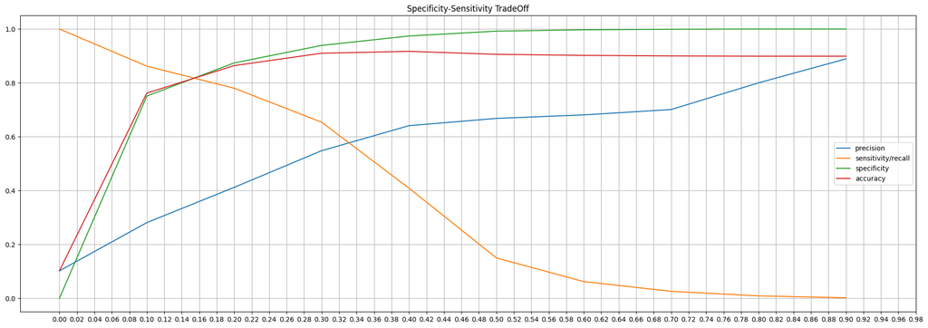

```python
# View metricsthreshold
ViewMetricsByThreshold(y_train, y_train_pred_lr, X_train)
```

```python
optimum_cutoff = 0.19
y_train_pred_lr_final = y_train_pred_lr.map(lambda x : 1 if x > optimum_cutoff else 0)
y_test_pred_lr_final = y_test_pred_lr.map(lambda x : 1 if x > optimum_cutoff else 0)

train_matrix = confusion_matrix(y_train, y_train_pred_lr_final)
print('Confusion Matrix for train:\n', train_matrix)
test_matrix = confusion_matrix(y_test, y_test_pred_lr_final)
print('\nConfusion Matrix for test: \n', test_matrix)
```

```
Confusion Matrix for train:
 [[38107  5915]
 [ 1054  3923]]

Confusion Matrix for test:
 [[16313  2532]
 [  419  1736]]
```

```python
AppendToModelPerfDF(train_matrix,f"Logistic Regr RFE Train (Optimal:{str(optimum_cutoff)} Thres)")
AppendToModelPerfDF(test_matrix,f"Logistic Regr RFE Test (Optimal:{str(optimum_cutoff)} Thres)")
```

```
Logistic Regr RFE Train (Optimal:0.19 Thres) :

Accuracy : 0.858
Sensitivity / True Positive Rate / Recall : 0.788
Specificity / True Negative Rate :  0.866
Precision / Positive Predictive Value : 0.399
F1-score : 0.53
Logistic Regr RFE Test (Optimal:0.19 Thres) :

Accuracy : 0.859
Sensitivity / True Positive Rate / Recall : 0.806
Specificity / True Negative Rate :  0.866
Precision / Positive Predictive Value : 0.407
F1-score : 0.541
```

```python
PlotMetricsComparission()
```

```
-----------------------------------------------------------------------------------------------------
 Note: If you dont see the table 'Metrics by Model (sorted by accuracy)' below,
 please ensure the Jupyter Notebook is marked Trusted (File --> Trusted Notebook)
-----------------------------------------------------------------------------------------------------
```

Metrics by Model (sorted by accuracy)

| model | accuracy | sensitivity/recall | specificity | precision | f1-score |
| --- | --- | --- | --- | --- | --- |
| Logistic Regr RFE Test (Optimal:0.19 Thres) | 0.859 | 0.806 | 0.866 | 0.407 | 0.541 |
| Logistic Regr RFE Train (Optimal:0.19 Thres) | 0.858 | 0.788 | 0.866 | 0.399 | 0.53 |
| Logistic Regr Train (Optimal:0.53 Thres) | 0.817 | 0.837 | 0.814 | 0.338 | 0.482 |
| Logistic Regr Test (Optimal:0.53 Thres) | 0.815 | 0.846 | 0.811 | 0.339 | 0.484 |
| Logistic Regr Train (0.5 Thres) | 0.797 | 0.85 | 0.791 | 0.315 | 0.46 |
| Logistic Regr Test (0.5 Thres) | 0.795 | 0.862 | 0.788 | 0.317 | 0.464 |

```python
type(logr5_fit.summary().tables[1])
val = logr5_fit.summary().tables[1]
valdf = pd.DataFrame(val.data)
valdf.columns = valdf.iloc[0]
valdf.rename(columns= {'' : "columns", "coef": "rfe_coef" }, inplace = True)
valdf = valdf[2:]

valdf["rfe_coef"] = pd.to_numeric(valdf["rfe_coef"])
valdf.head(len(valdf))
```

|  | columns | rfe_coef | std err | z | P>\|z\| | [0.025 | 0.975] |
| --- | --- | --- | --- | --- | --- | --- | --- |
| 2 | monthly_2g_7_1 | 1.1920 | 0.483 | 2.468 | 0.014 | 0.245 | 2.139 |
| 3 | loc_ic_t2m_mou_8 | -1.7135 | 0.090 | -19.128 | 0.000 | -1.889 | -1.538 |
| 4 | loc_ic_t2f_mou_8 | -0.5702 | 0.073 | -7.777 | 0.000 | -0.714 | -0.427 |
| 5 | monthly_2g_7_0 | 1.7619 | 0.475 | 3.709 | 0.000 | 0.831 | 2.693 |
| 6 | std_og_t2t_mou_8 | -0.2925 | 0.029 | -10.254 | 0.000 | -0.348 | -0.237 |
| 7 | spl_ic_mou_8 | -0.9522 | 0.061 | -15.533 | 0.000 | -1.072 | -0.832 |
| 8 | total_rech_data_8 | -0.6211 | 0.042 | -14.961 | 0.000 | -0.702 | -0.540 |
| 9 | aon_months | -0.3149 | 0.022 | -14.016 | 0.000 | -0.359 | -0.271 |
| 10 | loc_og_t2m_mou_8 | -0.7237 | 0.079 | -9.105 | 0.000 | -0.879 | -0.568 |
| 11 | monthly_2g_8_1 | -0.8239 | 0.142 | -5.791 | 0.000 | -1.103 | -0.545 |
| 12 | delta_total_rech_amt | -0.4799 | 0.019 | -25.254 | 0.000 | -0.517 | -0.443 |
| 13 | loc_ic_t2t_mou_8 | -1.0143 | 0.077 | -13.191 | 0.000 | -1.165 | -0.864 |
| 14 | offnet_mou_8 | -0.2220 | 0.033 | -6.818 | 0.000 | -0.286 | -0.158 |

```python
coeffient_df = pd.merge(coeffient_df, valdf, how="left", on=["columns"])
coeffient_df.drop(columns=coeffient_df.columns[-5:], axis=1,  inplace=True)
PlotAsTable(coeffient_df.sort_values(by='rfe_coef', ascending = False, key=abs), "Important predictors of Churn: BaseLine & RFE Coefficients (Sorted by RFE Coeff)")
```

```
-----------------------------------------------------------------------------------------------------
 Note: If you dont see the table 'Important predictors of Churn: BaseLine & RFE Coefficients (Sorted by RFE Coeff)' below,
 please ensure the Jupyter Notebook is marked Trusted (File --> Trusted Notebook)
-----------------------------------------------------------------------------------------------------
```

Important predictors of Churn: BaseLine & RFE Coefficients (Sorted by RFE Coeff)

| columns | baseline_coefficients | rfe_coef |
| --- | --- | --- |
| monthly_2g_7_0 | 0.034233 | 1.7619 |
| loc_ic_t2m_mou_8 | -0.241128 | -1.7135 |
| monthly_2g_7_1 | -0.0265288 | 1.192 |
| loc_ic_t2t_mou_8 | -0.178816 | -1.0143 |
| spl_ic_mou_8 | -0.326426 | -0.9522 |
| monthly_2g_8_1 | -0.038206 | -0.8239 |
| loc_og_t2m_mou_8 | -0.138874 | -0.7237 |
| total_rech_data_8 | -0.0870278 | -0.6211 |
| loc_ic_t2f_mou_8 | -0.160829 | -0.5702 |
| delta_total_rech_amt | -0.0286255 | -0.4799 |
| aon_months | -0.327769 | -0.3149 |
| std_og_t2t_mou_8 | -0.0256217 | -0.2925 |
| offnet_mou_8 | -0.0346231 | -0.222 |
| onnet_mou_6 | 0.0218306 | nan |
| onnet_mou_7 | 0.0197463 | nan |
| onnet_mou_8 | -0.026879 | nan |
| offnet_mou_6 | 0.0173414 | nan |
| offnet_mou_7 | 0.0434486 | nan |
| roam_ic_mou_6 | -0.00998974 | nan |
| roam_ic_mou_7 | 0.0354719 | nan |
| roam_ic_mou_8 | 0.134955 | nan |
| roam_og_mou_6 | 0.0434897 | nan |
| roam_og_mou_7 | 0.0609883 | nan |
| roam_og_mou_8 | 0.26992 | nan |
| loc_og_t2t_mou_6 | 0.00306849 | nan |
| loc_og_t2t_mou_7 | -0.00193069 | nan |
| loc_og_t2t_mou_8 | -0.0955863 | nan |
| loc_og_t2m_mou_6 | -0.00689465 | nan |
| loc_og_t2m_mou_7 | -0.0243136 | nan |
| loc_og_t2f_mou_6 | 0.00378966 | nan |

[output cut: 111 more lines]

### PCA

```python
pca = PCA(random_state = 42)
pca.fit(X_train)
pca.components_
```

```
array([[ 1.00437883e-03,  1.14422393e-03,  1.14824869e-03, ...,
         3.50929273e-04, -3.14626085e-04,  2.76577257e-04],
       [ 1.06420343e-03,  1.32184433e-04, -1.09073273e-03, ...,
         2.95725056e-04, -4.50004070e-05,  4.30949588e-05],
       [-7.99189378e-05,  9.27217192e-04,  5.36918894e-04, ...,
        -1.58240252e-04, -3.17126815e-04,  2.76680250e-04],
       ...,
       [-8.67143445e-05,  5.61315293e-04, -7.82393253e-04, ...,
         2.35412120e-02, -1.52928659e-01, -8.42646738e-02],
       [-0.00000000e+00, -8.27094485e-16,  1.09755187e-15, ...,
        -2.63026552e-16,  2.26483875e-16,  6.01925167e-17],
       [ 0.00000000e+00,  2.76536144e-16,  1.82550678e-16, ...,
        -6.76754267e-17,  9.95267837e-17, -6.41768102e-17]])
```

```python
pca.explained_variance_ratio_
```

```
array([5.61761442e-01, 1.42716583e-01, 1.29311366e-01, 6.86965952e-02,
       4.94133244e-02, 4.34914560e-02, 2.04828166e-03, 4.54334087e-04,
       2.26230894e-04, 2.01765639e-04, 1.59856077e-04, 1.15456793e-04,
       8.52193517e-05, 7.28107072e-05, 7.08258069e-05, 6.28824571e-05,
       6.03474318e-05, 5.59696033e-05, 5.49110163e-05, 4.74050609e-05,
       4.59038168e-05, 4.09884168e-05, 3.87767544e-05, 3.70356766e-05,
       3.20303146e-05, 3.04129518e-05, 2.87079232e-05, 2.78125952e-05,
       2.55554498e-05, 2.52398996e-05, 2.42494707e-05, 2.39135896e-05,
       2.26698539e-05, 2.06533222e-05, 1.96343046e-05, 1.86375061e-05,
       1.84329369e-05, 1.75119246e-05, 1.70607817e-05, 1.66017570e-05,
       1.64002344e-05, 1.52864944e-05, 1.51240658e-05, 1.42132740e-05,
       1.34937193e-05, 1.34171650e-05, 1.26126514e-05, 1.19039037e-05,
       1.18073089e-05, 1.15712952e-05, 1.09706379e-05, 9.55073321e-06,
       9.14672824e-06, 9.03747088e-06, 8.90980978e-06, 8.67591803e-06,
       7.59453973e-06, 7.38471641e-06, 7.31797992e-06, 7.22025305e-06,
       6.93426502e-06, 6.77553066e-06, 6.69069023e-06, 6.27746337e-06,
       6.19615313e-06, 6.12832658e-06, 5.89052021e-06, 5.30737103e-06,
       5.19637983e-06, 5.05512822e-06, 4.85669067e-06, 4.72368962e-06,
       4.62773855e-06, 4.32902476e-06, 4.21330146e-06, 4.00434161e-06,
       3.42622147e-06, 3.30734176e-06, 3.20103522e-06, 2.94428527e-06,
       2.93302184e-06, 2.59428572e-06, 2.47210294e-06, 2.14273432e-06,
       2.04771573e-06, 1.93702787e-06, 1.79866712e-06, 1.54132515e-06,
       1.45823709e-06, 1.40163258e-06, 1.34819252e-06, 1.32825617e-06,
       1.24477595e-06, 1.07912818e-06, 9.89103908e-07, 9.01827502e-07,
       8.61779520e-07, 8.08496229e-07, 7.86852772e-07, 7.73999638e-07,
       6.20386341e-07, 5.86265060e-07, 5.53908804e-07, 5.47955216e-07,
       4.79750260e-07, 4.57722728e-07, 4.31277728e-07, 4.21051047e-07,
       3.71381448e-07, 3.29995113e-07, 3.28517893e-07, 3.21561436e-07,
       2.94515624e-07, 2.78426340e-07, 2.67228145e-07, 2.44124924e-07,
       2.27590603e-07, 2.19393639e-07, 2.06888838e-07, 2.05169823e-07,
       1.71370513e-07, 1.62491346e-07, 1.59153213e-07, 1.48114982e-07,
       1.41725188e-07, 1.22533734e-07, 9.46516089e-08, 8.45475803e-08,
       7.53550710e-08, 7.23249706e-08, 6.36767447e-08, 6.13896711e-08,
       4.60094811e-08, 4.45821567e-08, 2.82162063e-08, 2.25988981e-08,
       1.76363957e-08, 1.47214497e-08, 1.00040620e-08, 5.05582192e-33,
       5.05582192e-33])
```

**Scree Plot**

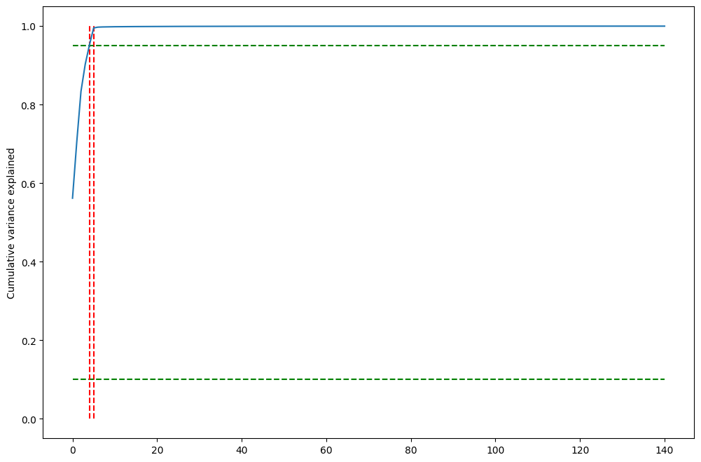

```python
def Plot_ScreePlot(evr):
  var_cumu = np.cumsum(evr)
  fig = plt.figure(figsize=[12,8])
  plt.vlines(x=5, ymax=1, ymin=0, colors="r", linestyles="--")
  plt.hlines(y=0.1, xmax=140, xmin=0, colors="g", linestyles="--")
  plt.vlines(x=4, ymax=1, ymin=0, colors="r", linestyles="--")
  plt.hlines(y=0.95, xmax=140, xmin=0, colors="g", linestyles="--")
  plt.plot(var_cumu)
  plt.ylabel("Cumulative variance explained")
  plt.show()


Plot_ScreePlot(pca.explained_variance_ratio_)
```

```
(48999, 31)
```

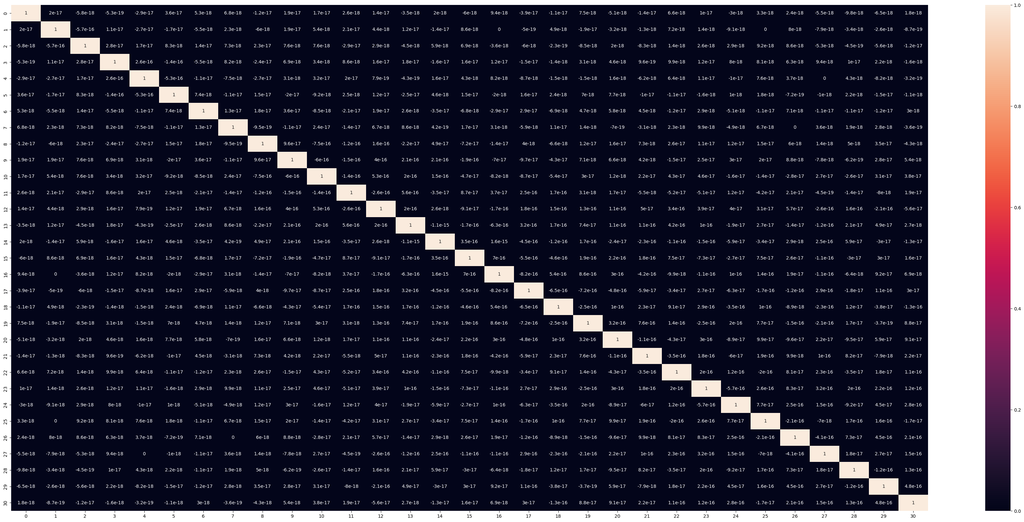

```python
# Perform PCA using the first 45 components
comp_count = 31
pca_final = PCA(n_components=comp_count, random_state=42)
transformed_pca_df = pca_final.fit_transform(X_train)
print(transformed_pca_df.shape)
corrmat = np.corrcoef(transformed_pca_df.transpose())
plt.figure(figsize=[45,20])
sns.heatmap(corrmat, annot=True)
```

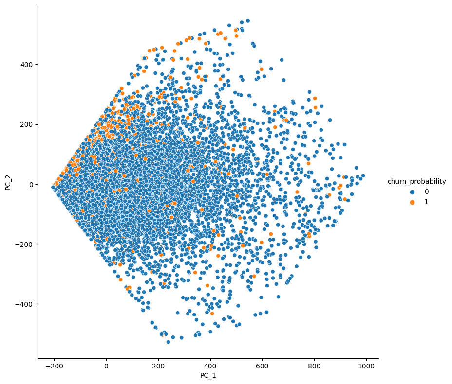

```python
X_train_pca = pd.DataFrame(transformed_pca_df, columns=["PC_"+str(x) for x in range(1,comp_count + 1)], index = X_train.index)
telecom_train_pca = pd.concat([X_train_pca, y_train], axis=1)

telecom_train_pca.head()
## Plotting principal components
sns.pairplot(data=telecom_train_pca, x_vars=["PC_1"], y_vars=["PC_2"], hue = "churn_probability", size=8);
```

```python
def ApplyPCATransformation(df):
  return pca_final.transform(df)
```

### Model 2 : PCA + Logistic Regression Model

```python
# Transforming test set with pca ( 45 components)
X_test_pca = ApplyPCATransformation(X_test)
```

```python
# Logistic Regression
lr_pca = LogisticRegression(random_state=100, class_weight='balanced')
lr_pca.fit(X_train_pca, y_train)
```

```
LogisticRegression(class_weight='balanced', random_state=100)
```

```python
# y_train predictions
y_train_pred_lr_pca = lr_pca.predict(X_train_pca)
y_train_pred_lr_pca[:5]
```

```
array([0, 0, 0, 1, 0])
```

```python
# Test Prediction
y_test_pred_lr_pca = lr_pca.predict(X_test_pca)
y_test_pred_lr_pca[:5]
```

```
array([1, 0, 0, 0, 0])
```

```python
train_matrix = confusion_matrix(y_train, y_train_pred_lr_pca)
print('Confusion Matrix for train:\n', train_matrix)
test_matrix = confusion_matrix(y_test, y_test_pred_lr_pca)
print('\nConfusion Matrix for test: \n', test_matrix)
```

```
Confusion Matrix for train:
 [[34478  9544]
 [  786  4191]]

Confusion Matrix for test:
 [[14719  4126]
 [  320  1835]]
```

```python
AppendToModelPerfDF(train_matrix,f"Logistic Regr PCA Train Baseline)")
AppendToModelPerfDF(test_matrix,f"Logistic Regr PCA Test Baseline")
```

```
Logistic Regr PCA Train Baseline) :

Accuracy : 0.789
Sensitivity / True Positive Rate / Recall : 0.842
Specificity / True Negative Rate :  0.783
Precision / Positive Predictive Value : 0.305
F1-score : 0.448
Logistic Regr PCA Test Baseline :

Accuracy : 0.788
Sensitivity / True Positive Rate / Recall : 0.852
Specificity / True Negative Rate :  0.781
Precision / Positive Predictive Value : 0.308
F1-score : 0.452
```

#### Hyperparameter tuning using GRIDSEARCH

```python
param_grid = {
    'C': [0,1,2,3,4,5,10,50,100],  # Regularization strength
    'solver': ['lbfgs', 'liblinear', 'sag', 'saga'],  # Solver options
    'penalty' : ['l1','l2','none']
}

# Create the GridSearchCV object
grid_search = GridSearchCV(lr_pca, param_grid, scoring='accuracy', cv=20, verbose=True, n_jobs=-1)

# Fit the GridSearchCV to your data
grid_search.fit(X_train_pca, y_train)

# Get the best hyperparameters and best accuracy
best_params = grid_search.best_params_
best_accuracy = grid_search.best_score_

print("Best Hyperparameters:", best_params)
print("Best Accuracy:", best_accuracy)
```

```
Fitting 20 folds for each of 108 candidates, totalling 2160 fits
Best Hyperparameters: {'C': 50, 'penalty': 'l2', 'solver': 'liblinear'}
Best Accuracy: 0.7879138757177023
```

```python
y_train_pred_lr_pca_grid = grid_search.best_estimator_.predict(X_train_pca)
y_test_pred_lr_pca_grid = grid_search.best_estimator_.predict(X_test_pca)

train_matrix = confusion_matrix(y_train, y_train_pred_lr_pca_grid)
print('Confusion Matrix for train:\n', train_matrix)
test_matrix = confusion_matrix(y_test, y_test_pred_lr_pca_grid)
print('\nConfusion Matrix for test: \n', test_matrix)
```

```
Confusion Matrix for train:
 [[34434  9588]
 [  780  4197]]

Confusion Matrix for test:
 [[14724  4121]
 [  321  1834]]
```

```python
AppendToModelPerfDF(train_matrix,f"Logistic Regr PCA GRIDSEARCH Train Baseline")
AppendToModelPerfDF(test_matrix,f"Logistic Regr PCA GRIDSEARCH Test Baseline")
```

```
Logistic Regr PCA GRIDSEARCH Train Baseline :

Accuracy : 0.788
Sensitivity / True Positive Rate / Recall : 0.843
Specificity / True Negative Rate :  0.782
Precision / Positive Predictive Value : 0.304
F1-score : 0.447
Logistic Regr PCA GRIDSEARCH Test Baseline :

Accuracy : 0.788
Sensitivity / True Positive Rate / Recall : 0.851
Specificity / True Negative Rate :  0.781
Precision / Positive Predictive Value : 0.308
F1-score : 0.452
```

### Model 3 : PCA + Random Forest

```python
# Ratio of classes
class_0 = y[y == 0].count()
class_1 = y[y == 1].count()

pca_rf = RandomForestClassifier(random_state=42, class_weight= {0 : class_1/(class_0 + class_1) , 1 : class_0/(class_0 + class_1) } , oob_score=True, n_jobs=-1,verbose=1)
pca_rf
```

```
RandomForestClassifier(class_weight={0: 0.10188716981671167,
                                     1: 0.8981128301832884},
                       n_jobs=-1, oob_score=True, random_state=42, verbose=1)
```

```python
# Hyper parameter Tuning
params = {
    'n_estimators'  : [30,40,50,100],
    'max_depth' : [3,4,5,6,7],
    'min_samples_leaf' : [15,20,25,30]
}
folds = StratifiedKFold(n_splits=4, shuffle=True, random_state=42)
pca_rf_model_search = GridSearchCV(estimator=pca_rf, param_grid=params,
                                   cv=folds, scoring='roc_auc', verbose=True, n_jobs=-1 )

pca_rf_model_search.fit(X_train_pca, y_train)
```

```
Fitting 4 folds for each of 80 candidates, totalling 320 fits
```

```
[Parallel(n_jobs=-1)]: Using backend ThreadingBackend with 8 concurrent workers.
[Parallel(n_jobs=-1)]: Done  34 tasks      | elapsed:    1.3s
[Parallel(n_jobs=-1)]: Done 100 out of 100 | elapsed:    3.4s finished
```

```
GridSearchCV(cv=StratifiedKFold(n_splits=4, random_state=42, shuffle=True),
             estimator=RandomForestClassifier(class_weight={0: 0.10188716981671167,
                                                            1: 0.8981128301832884},
                                              n_jobs=-1, oob_score=True,
                                              random_state=42, verbose=1),
             n_jobs=-1,
             param_grid={'max_depth': [3, 4, 5, 6, 7],
                         'min_samples_leaf': [15, 20, 25, 30],
                         'n_estimators': [30, 40, 50, 100]},
             scoring='roc_auc', verbose=True)
```

```python
# Optimum Hyperparametersprint('Best ROC-AUC score :', pca_rf_model_search.best_score_)
print('Best Parameters :', pca_rf_model_search.best_params_)
```

```
Best Parameters : {'max_depth': 7, 'min_samples_leaf': 30, 'n_estimators': 100}
```

```python
# Modelling using the best PCA-RandomForest Estimator
pca_rf_best = pca_rf_model_search.best_estimator_
pca_rf_best_fit = pca_rf_best.fit(X_train_pca, y_train)

# Prediction on Train set
y_train_pred_pca_rf_best = pca_rf_best_fit.predict(X_train_pca)
```

```
[Parallel(n_jobs=-1)]: Using backend ThreadingBackend with 8 concurrent workers.
[Parallel(n_jobs=-1)]: Done  34 tasks      | elapsed:    1.3s
[Parallel(n_jobs=-1)]: Done 100 out of 100 | elapsed:    3.4s finished
[Parallel(n_jobs=8)]: Using backend ThreadingBackend with 8 concurrent workers.
[Parallel(n_jobs=8)]: Done  34 tasks      | elapsed:    0.0s
[Parallel(n_jobs=8)]: Done 100 out of 100 | elapsed:    0.0s finished
```

```python
# Prediction on test set
y_test_pred_pca_rf_best = pca_rf_best_fit.predict(X_test_pca)
```

```
[Parallel(n_jobs=8)]: Using backend ThreadingBackend with 8 concurrent workers.
[Parallel(n_jobs=8)]: Done  34 tasks      | elapsed:    0.0s
[Parallel(n_jobs=8)]: Done 100 out of 100 | elapsed:    0.0s finished
```

```python
## PCA - RandomForest Model Performance - Hyper Parameter Tuned

train_matrix = confusion_matrix(y_train, y_train_pred_pca_rf_best)
test_matrix = confusion_matrix(y_test, y_test_pred_pca_rf_best)
```

```python
AppendToModelPerfDF(train_matrix,f"Randomforest PCA GRIDSEARCH Train Baseline")
AppendToModelPerfDF(test_matrix,f"Randomforest PCA GRIDSEARCH Test Baseline")
```

```
Randomforest PCA GRIDSEARCH Train Baseline :

Accuracy : 0.864
Sensitivity / True Positive Rate / Recall : 0.798
Specificity / True Negative Rate :  0.872
Precision / Positive Predictive Value : 0.413
F1-score : 0.544
Randomforest PCA GRIDSEARCH Test Baseline :

Accuracy : 0.857
Sensitivity / True Positive Rate / Recall : 0.77
Specificity / True Negative Rate :  0.867
Precision / Positive Predictive Value : 0.398
F1-score : 0.525
```

```python
PlotMetricsComparission()
```

```
-----------------------------------------------------------------------------------------------------
 Note: If you dont see the table 'Metrics by Model (sorted by accuracy)' below,
 please ensure the Jupyter Notebook is marked Trusted (File --> Trusted Notebook)
-----------------------------------------------------------------------------------------------------
```

Metrics by Model (sorted by accuracy)

| model | accuracy | sensitivity/recall | specificity | precision | f1-score |
| --- | --- | --- | --- | --- | --- |
| Randomforest PCA GRIDSEARCH Train Baseline | 0.864 | 0.798 | 0.872 | 0.413 | 0.544 |
| Logistic Regr RFE Test (Optimal:0.19 Thres) | 0.859 | 0.806 | 0.866 | 0.407 | 0.541 |
| Logistic Regr RFE Train (Optimal:0.19 Thres) | 0.858 | 0.788 | 0.866 | 0.399 | 0.53 |
| Randomforest PCA GRIDSEARCH Test Baseline | 0.857 | 0.77 | 0.867 | 0.398 | 0.525 |
| Logistic Regr Train (Optimal:0.53 Thres) | 0.817 | 0.837 | 0.814 | 0.338 | 0.482 |
| Logistic Regr Test (Optimal:0.53 Thres) | 0.815 | 0.846 | 0.811 | 0.339 | 0.484 |
| Logistic Regr Train (0.5 Thres) | 0.797 | 0.85 | 0.791 | 0.315 | 0.46 |
| Logistic Regr Test (0.5 Thres) | 0.795 | 0.862 | 0.788 | 0.317 | 0.464 |
| Logistic Regr PCA Train Baseline) | 0.789 | 0.842 | 0.783 | 0.305 | 0.448 |
| Logistic Regr PCA Test Baseline | 0.788 | 0.852 | 0.781 | 0.308 | 0.452 |
| Logistic Regr PCA GRIDSEARCH Train Baseline | 0.788 | 0.843 | 0.782 | 0.304 | 0.447 |
| Logistic Regr PCA GRIDSEARCH Test Baseline | 0.788 | 0.851 | 0.781 | 0.308 | 0.452 |

### Model 4 : PCA + XGBoost

```python
pca_xgb = xgb.XGBClassifier(random_state=42, scale_pos_weight= class_0/class_1 ,
                                    tree_method='hist',
                                   objective='binary:logistic',


                                  )  # scale_pos_weight takes care of class imbalance
pca_xgb.fit(X_train_pca, y_train)
```

```
XGBClassifier(base_score=None, booster=None, callbacks=None,
              colsample_bylevel=None, colsample_bynode=None,
              colsample_bytree=None, early_stopping_rounds=None,
              enable_categorical=False, eval_metric=None, feature_types=None,
              gamma=None, gpu_id=None, grow_policy=None, importance_type=None,
              interaction_constraints=None, learning_rate=None, max_bin=None,
              max_cat_threshold=None, max_cat_to_onehot=None,
              max_delta_step=None, max_depth=None, max_leaves=None,
              min_child_weight=None, missing=nan, monotone_constraints=None,
              n_estimators=100, n_jobs=None, num_parallel_tree=None,
              predictor=None, random_state=42, ...)
```

```python
print('Baseline Train AUC Score')
print(roc_auc_score(y_train, pca_xgb.predict_proba(X_train_pca)[:, 1]))

print('Baseline Test AUC Score')
print(roc_auc_score(y_test, pca_xgb.predict_proba(X_test_pca)[:, 1]))
```

```
Baseline Train AUC Score
0.9927243051899077
Baseline Test AUC Score
0.895996661001121
```

```python
# A parameter grid for XGBoost
params = {
        'n_estimators' : [400, 500, 600], # no of trees
        'learning_rate' : [0.04, 0.05, 0.07, 0.06],  # et
        'gamma': [0.05, 0.1, 0.2],
        'max_depth': [ 11, 12, 14, 15]
        }

## Hyper parameter Tuning
parameters = {
              'learning_rate': [0.1, 0.2, 0.3],
              'gamma' : [10,20,50],
              'max_depth': [2,3,4]}
folds = 3

param_comb = 100

#pca_xgb_search = RandomizedSearchCV(pca_xgb, param_distributions=params, n_iter=param_comb, scoring='accuracy', n_jobs=-1, cv=3, verbose=3, random_state=42)
pca_xgb_search = GridSearchCV(estimator=pca_xgb , param_grid=params,scoring='roc_auc', cv=3, n_jobs=-1, verbose=1)
pca_xgb_search.fit(X_train_pca, y_train)
```

```
Fitting 3 folds for each of 144 candidates, totalling 432 fits
```

```
GridSearchCV(cv=3,
             estimator=XGBClassifier(base_score=None, booster=None,
                                     callbacks=None, colsample_bylevel=None,
                                     colsample_bynode=None,
                                     colsample_bytree=None,
                                     early_stopping_rounds=None,
                                     enable_categorical=False, eval_metric=None,
                                     feature_types=None, gamma=None,
                                     gpu_id=None, grow_policy=None,
                                     importance_type=None,
                                     interaction_constraints=None,
                                     learning_rate=None,...
                                     max_delta_step=None, max_depth=None,
                                     max_leaves=None, min_child_weight=None,
                                     missing=nan, monotone_constraints=None,
                                     n_estimators=100, n_jobs=None,
                                     num_parallel_tree=None, predictor=None,
                                     random_state=42, ...),
             n_jobs=-1,
             param_grid={'gamma': [0.05, 0.1, 0.2],
                         'learning_rate': [0.04, 0.05, 0.07, 0.06],
                         'max_depth': [11, 12, 14, 15],
                         'n_estimators': [400, 500, 600]},
             scoring='roc_auc', verbose=1)
```

```python
# Optimum Hyperparameters
print('Best ROC-AUC score :', pca_xgb_search.best_score_)
print('Best Parameters :', pca_xgb_search.best_params_)
```

```
Best ROC-AUC score : 0.9046821389020542
Best Parameters : {'gamma': 0.05, 'learning_rate': 0.05, 'max_depth': 12, 'n_estimators': 600}
```

```python
# Modelling using the best PCA-XGBoost Estimator
pca_xgb_best_1 = pca_xgb_search.best_estimator_
pca_xgb_best_fit = pca_xgb_best_1.fit(X_train_pca, y_train)

# Prediction on Train set
y_train_pred_pca_xgb_best = pca_xgb_best_fit.predict(X_train_pca)
y_test_pred_pca_xgb_best = pca_xgb_best_fit.predict(X_test_pca)
```

```python
## PCA - XGBOOST [Hyper parameter tuned] Model Performance

train_matrix = confusion_matrix(y_train, y_train_pred_pca_xgb_best)
test_matrix = confusion_matrix(y_test, y_test_pred_pca_xgb_best)
```

```python
AppendToModelPerfDF(train_matrix,f"XGBoost PCA RandomSEARCH Train ")
AppendToModelPerfDF(test_matrix,f"XGBoost PCA RandomSEARCH Test ")
```

```
XGBoost PCA RandomSEARCH Train  :

Accuracy : 1.0
Sensitivity / True Positive Rate / Recall : 1.0
Specificity / True Negative Rate :  1.0
Precision / Positive Predictive Value : 1.0
F1-score : 1.0
XGBoost PCA RandomSEARCH Test  :

Accuracy : 0.922
Sensitivity / True Positive Rate / Recall : 0.548
Specificity / True Negative Rate :  0.965
Precision / Positive Predictive Value : 0.642
F1-score : 0.591
```

```python
PlotMetricsComparission()
```

```
-----------------------------------------------------------------------------------------------------
 Note: If you dont see the table 'Metrics by Model (sorted by accuracy)' below,
 please ensure the Jupyter Notebook is marked Trusted (File --> Trusted Notebook)
-----------------------------------------------------------------------------------------------------
```

Metrics by Model (sorted by accuracy)

| model | accuracy | sensitivity/recall | specificity | precision | f1-score |
| --- | --- | --- | --- | --- | --- |
| XGBoost PCA RandomSEARCH Train | 1 | 1 | 1 | 1 | 1 |
| XGBoost PCA RandomSEARCH Test | 0.922 | 0.548 | 0.965 | 0.642 | 0.591 |
| Randomforest PCA GRIDSEARCH Train Baseline | 0.864 | 0.798 | 0.872 | 0.413 | 0.544 |
| Logistic Regr RFE Test (Optimal:0.19 Thres) | 0.859 | 0.806 | 0.866 | 0.407 | 0.541 |
| Logistic Regr RFE Train (Optimal:0.19 Thres) | 0.858 | 0.788 | 0.866 | 0.399 | 0.53 |
| Randomforest PCA GRIDSEARCH Test Baseline | 0.857 | 0.77 | 0.867 | 0.398 | 0.525 |
| Logistic Regr Train (Optimal:0.53 Thres) | 0.817 | 0.837 | 0.814 | 0.338 | 0.482 |
| Logistic Regr Test (Optimal:0.53 Thres) | 0.815 | 0.846 | 0.811 | 0.339 | 0.484 |
| Logistic Regr Train (0.5 Thres) | 0.797 | 0.85 | 0.791 | 0.315 | 0.46 |
| Logistic Regr Test (0.5 Thres) | 0.795 | 0.862 | 0.788 | 0.317 | 0.464 |
| Logistic Regr PCA Train Baseline) | 0.789 | 0.842 | 0.783 | 0.305 | 0.448 |
| Logistic Regr PCA Test Baseline | 0.788 | 0.852 | 0.781 | 0.308 | 0.452 |
| Logistic Regr PCA GRIDSEARCH Train Baseline | 0.788 | 0.843 | 0.782 | 0.304 | 0.447 |
| Logistic Regr PCA GRIDSEARCH Test Baseline | 0.788 | 0.851 | 0.781 | 0.308 | 0.452 |

```python
print(pca_xgb_best_fit.scale_pos_weight)
```

```
8.814778463264162
```

```python
print(pca_xgb.scale_pos_weight)
```

```
8.814778463264162
```

### Preparing the Kaggle TEST data set

```python
# reading the dataset
telecom_test = pd.read_csv("test.csv")
```

```python
ShowSummary(telecom_test)
```

```
<class 'pandas.core.frame.DataFrame'>
RangeIndex: 30000 entries, 0 to 29999
Data columns (total 171 columns):
 #    Column                    Non-Null Count  Dtype
---   ------                    --------------  -----
 0    id                        30000 non-null  int64
 1    circle_id                 30000 non-null  int64
 2    loc_og_t2o_mou            29684 non-null  float64
 3    std_og_t2o_mou            29684 non-null  float64
 4    loc_ic_t2o_mou            29684 non-null  float64
 5    last_date_of_month_6      30000 non-null  object
 6    last_date_of_month_7      29798 non-null  object
 7    last_date_of_month_8      29633 non-null  object
 8    arpu_6                    30000 non-null  float64
 9    arpu_7                    30000 non-null  float64
```

[output cut: 163 more lines]

### PreProcess kaggle dataset by applying required transformations for predictions

```python
ConvertDateTimeColumns(telecom_test)
ApplyMeaningfulName(telecom_test)
ShowSummary(telecom_test)

ReplaceRechargeColsForNoRecharge(telecom_test)
ShowSummary(telecom_test)

CreateTotalRechAmtDataCols(telecom_test)
telecom_test.describe()


DropHighMissingColumns(telecom_test)

DropUniqueValColumns(telecom_test)

ConverToCategorical(telecom_test,change_to_cat.drop("churn_probability"))

HandleOutliers(telecom, 0.9, 0.99)

ShowSummary(telecom_test)

ImputeMOUCols(telecom_test)

ImputeNumericColumns(telecom_test)

CalculateDeltaCols(telecom_test)
ConvertAONToMonths(telecom_test)

GroupAsOtherInCategorical(telecom_test)
ShowSummary(telecom_test)

telecom_test = CreateDummyVars(telecom_test)
DropDateCols(telecom_test)
ShowSummary(telecom_test)

telecom_test.dropna()


X_K_test = telecom_test.drop(["id", "sachet_2g_6_4"],axis=1)
X_K_test.index = telecom_test["id"]

# Transform test set
X_K_test[numerical_vars] = scaler.transform(X_K_test[numerical_vars])

# Transforming test set with pca
X_K_test_pca = ApplyPCATransformation(X_K_test)
```

```
<class 'pandas.core.frame.DataFrame'>
RangeIndex: 30000 entries, 0 to 29999
Data columns (total 171 columns):
 #    Column                    Non-Null Count  Dtype
---   ------                    --------------  -----
 0    id                        30000 non-null  int64
 1    circle_id                 30000 non-null  int64
 2    loc_og_t2o_mou            29684 non-null  float64
 3    std_og_t2o_mou            29684 non-null  float64
 4    loc_ic_t2o_mou            29684 non-null  float64
 5    last_date_of_month_6      30000 non-null  datetime64[ns]
 6    last_date_of_month_7      29798 non-null  datetime64[ns]
 7    last_date_of_month_8      29633 non-null  datetime64[ns]
 8    arpu_6                    30000 non-null  float64
 9    arpu_7                    30000 non-null  float64
```

[output cut: 348 more lines]

Outliers handled(above 99.0 percentile)

| Column | Outlier Threshold | Outliers replaced |
| --- | --- | --- |
| delta_vol_3g | 1114.54 | 700 |
| delta_total_og_mou | 1011.39 | 700 |
| delta_total_ic_mou | 462.635 | 700 |
| delta_vbc_3g | 587.457 | 700 |
| delta_arpu | 619.774 | 700 |
| delta_total_rech_amt | 769.01 | 700 |

```
<class 'pandas.core.frame.DataFrame'>
RangeIndex: 30000 entries, 0 to 29999
Data columns (total 137 columns):
 #    Column                 Non-Null Count  Dtype
---   ------                 --------------  -----
 0    id                     30000 non-null  int64
 1    arpu_6                 30000 non-null  float64
 2    arpu_7                 30000 non-null  float64
 3    arpu_8                 30000 non-null  float64
 4    onnet_mou_6            28831 non-null  float64
 5    onnet_mou_7            28828 non-null  float64
 6    onnet_mou_8            28325 non-null  float64
 7    offnet_mou_6           28831 non-null  float64
 8    offnet_mou_7           28828 non-null  float64
 9    offnet_mou_8           28325 non-null  float64
```

[output cut: 133 more lines]

sachet_3g_6 categorical_counts

| sachet_3g_6 |
| --- |
| 95.7667 |
| 3.07667 |
| 0.6 |
| 0.223333 |
| 0.106667 |
| 0.0633333 |
| 0.0366667 |
| 0.03 |
| 0.0266667 |
| 0.0166667 |
| 0.01 |
| 0.00666667 |
| 0.00666667 |
| 0.00333333 |
| 0.00333333 |
| 0.00333333 |
| 0.00333333 |
| 0.00333333 |
| 0.00333333 |
| 0.00333333 |
| 0.00333333 |
| 0.00333333 |

```
Replaced [2, 3, 4, 5, 6, 7, 9, 10, 8, 18, 11, 14, 15, 16, 17, 12, 19, 21, 22, 28] in sachet_3g_6 with category : Others
-----------------------------------------------------------------------------------------------------
 Note: If you dont see the table 'sachet_2g_8 categorical_counts' below,
 please ensure the Jupyter Notebook is marked Trusted (File --> Trusted Notebook)
-----------------------------------------------------------------------------------------------------
```

sachet_2g_8 categorical_counts

| sachet_2g_8 |
| --- |
| 85.9467 |
| 5.72333 |
| 2.48 |
| 1.46333 |
| 1.11 |
| 0.92 |
| 0.606667 |
| 0.386667 |
| 0.343333 |
| 0.283333 |
| 0.21 |
| 0.15 |
| 0.09 |
| 0.0866667 |
| 0.0633333 |
| 0.0466667 |
| 0.0233333 |
| 0.02 |
| 0.01 |
| 0.00666667 |
| 0.00666667 |
| 0.00666667 |
| 0.00333333 |
| 0.00333333 |
| 0.00333333 |
| 0.00333333 |
| 0.00333333 |

```
Replaced [5, 6, 7, 8, 9, 10, 11, 12, 14, 13, 15, 16, 19, 18, 17, 24, 25, 20, 21, 26, 33, 34] in sachet_2g_8 with category : Others
-----------------------------------------------------------------------------------------------------
 Note: If you dont see the table 'monthly_2g_6 categorical_counts' below,
 please ensure the Jupyter Notebook is marked Trusted (File --> Trusted Notebook)
-----------------------------------------------------------------------------------------------------
```

monthly_2g_6 categorical_counts

| monthly_2g_6 |
| --- |
| 92.5933 |
| 6.8 |
| 0.576667 |
| 0.0266667 |
| 0.00333333 |

```
Replaced [2, 3, 4] in monthly_2g_6 with category : Others
-----------------------------------------------------------------------------------------------------
 Note: If you dont see the table 'monthly_2g_8 categorical_counts' below,
 please ensure the Jupyter Notebook is marked Trusted (File --> Trusted Notebook)
-----------------------------------------------------------------------------------------------------
```

monthly_2g_8 categorical_counts

| monthly_2g_8 |
| --- |
| 92.58 |
| 6.79 |
| 0.576667 |
| 0.0433333 |
| 0.00666667 |
| 0.00333333 |

```
Replaced [2, 3, 4, 5] in monthly_2g_8 with category : Others
-----------------------------------------------------------------------------------------------------
 Note: If you dont see the table 'sachet_2g_6 categorical_counts' below,
 please ensure the Jupyter Notebook is marked Trusted (File --> Trusted Notebook)
-----------------------------------------------------------------------------------------------------
```

sachet_2g_6 categorical_counts

| sachet_2g_6 |
| --- |
| 87.0467 |
| 5.69667 |
| 2.39 |
| 1.32333 |
| 1.01 |
| 0.566667 |
| 0.46 |
| 0.356667 |
| 0.263333 |
| 0.26 |
| 0.206667 |
| 0.103333 |
| 0.0933333 |
| 0.0533333 |
| 0.0366667 |
| 0.0266667 |
| 0.0266667 |
| 0.0233333 |
| 0.0166667 |
| 0.01 |
| 0.00666667 |
| 0.00666667 |
| 0.00666667 |
| 0.00333333 |
| 0.00333333 |
| 0.00333333 |

```
Replaced [5, 6, 7, 8, 9, 10, 12, 11, 13, 14, 15, 18, 17, 19, 20, 16, 22, 24, 21, 27, 39] in sachet_2g_6 with category : Others
-----------------------------------------------------------------------------------------------------
 Note: If you dont see the table 'monthly_3g_7 categorical_counts' below,
 please ensure the Jupyter Notebook is marked Trusted (File --> Trusted Notebook)
-----------------------------------------------------------------------------------------------------
```

monthly_3g_7 categorical_counts

| monthly_3g_7 |
| --- |
| 94.2133 |
| 4.36333 |
| 1.01667 |
| 0.213333 |
| 0.0866667 |
| 0.05 |
| 0.0266667 |
| 0.0133333 |
| 0.00666667 |
| 0.00333333 |
| 0.00333333 |
| 0.00333333 |

```
Replaced [3, 4, 5, 6, 7, 11, 8, 9, 12] in monthly_3g_7 with category : Others
-----------------------------------------------------------------------------------------------------
 Note: If you dont see the table 'sachet_3g_8 categorical_counts' below,
 please ensure the Jupyter Notebook is marked Trusted (File --> Trusted Notebook)
-----------------------------------------------------------------------------------------------------
```

sachet_3g_8 categorical_counts

| sachet_3g_8 |
| --- |
| 95.8333 |
| 2.71667 |
| 0.676667 |
| 0.276667 |
| 0.166667 |
| 0.0966667 |
| 0.07 |
| 0.0466667 |
| 0.0266667 |
| 0.0166667 |
| 0.0133333 |
| 0.0133333 |
| 0.0133333 |
| 0.01 |
| 0.00666667 |
| 0.00333333 |
| 0.00333333 |
| 0.00333333 |
| 0.00333333 |
| 0.00333333 |

```
Replaced [2, 3, 4, 5, 6, 7, 8, 9, 12, 14, 10, 13, 15, 11, 16, 21, 27, 30] in sachet_3g_8 with category : Others
-----------------------------------------------------------------------------------------------------
 Note: If you dont see the table 'sachet_2g_7 categorical_counts' below,
 please ensure the Jupyter Notebook is marked Trusted (File --> Trusted Notebook)
-----------------------------------------------------------------------------------------------------
```

sachet_2g_7 categorical_counts

| sachet_2g_7 |
| --- |
| 86.7233 |
| 5.08333 |
| 2.71 |
| 1.23333 |
| 1.07333 |
| 0.773333 |
| 0.633333 |
| 0.41 |
| 0.393333 |
| 0.23 |
| 0.22 |
| 0.136667 |
| 0.123333 |
| 0.0666667 |
| 0.0466667 |
| 0.0433333 |
| 0.03 |
| 0.02 |
| 0.02 |
| 0.0133333 |
| 0.00333333 |
| 0.00333333 |
| 0.00333333 |
| 0.00333333 |
| 0.00333333 |

```
Replaced [5, 6, 8, 7, 9, 10, 11, 12, 13, 16, 14, 18, 15, 17, 20, 19, 24, 28, 29, 30] in sachet_2g_7 with category : Others
-----------------------------------------------------------------------------------------------------
 Note: If you dont see the table 'monthly_3g_8 categorical_counts' below,
 please ensure the Jupyter Notebook is marked Trusted (File --> Trusted Notebook)
-----------------------------------------------------------------------------------------------------
```

monthly_3g_8 categorical_counts

| monthly_3g_8 |
| --- |
| 93.8133 |
| 4.62333 |
| 1.14667 |
| 0.226667 |
| 0.11 |
| 0.0333333 |
| 0.0233333 |
| 0.0166667 |
| 0.00333333 |
| 0.00333333 |

```
Replaced [3, 4, 5, 6, 7, 9, 10] in monthly_3g_8 with category : Others
-----------------------------------------------------------------------------------------------------
 Note: If you dont see the table 'sachet_3g_7 categorical_counts' below,
 please ensure the Jupyter Notebook is marked Trusted (File --> Trusted Notebook)
-----------------------------------------------------------------------------------------------------
```

sachet_3g_7 categorical_counts

| sachet_3g_7 |
| --- |
| 95.8933 |
| 2.86333 |
| 0.593333 |
| 0.21 |
| 0.14 |
| 0.1 |
| 0.05 |
| 0.03 |
| 0.0233333 |
| 0.02 |
| 0.0133333 |
| 0.0133333 |
| 0.00666667 |
| 0.00666667 |
| 0.00666667 |
| 0.00666667 |
| 0.00666667 |
| 0.00333333 |
| 0.00333333 |
| 0.00333333 |
| 0.00333333 |
| 0.00333333 |

```
Replaced [2, 3, 4, 5, 6, 9, 7, 8, 12, 13, 15, 19, 18, 11, 10, 16, 17, 14, 21, 35] in sachet_3g_7 with category : Others
-----------------------------------------------------------------------------------------------------
 Note: If you dont see the table 'monthly_3g_6 categorical_counts' below,
 please ensure the Jupyter Notebook is marked Trusted (File --> Trusted Notebook)
-----------------------------------------------------------------------------------------------------
```

monthly_3g_6 categorical_counts

| monthly_3g_6 |
| --- |
| 94.3333 |
| 4.40667 |
| 0.886667 |
| 0.233333 |
| 0.06 |
| 0.0566667 |
| 0.00666667 |
| 0.00666667 |
| 0.00333333 |
| 0.00333333 |
| 0.00333333 |

```
Replaced [2, 3, 5, 4, 6, 11, 7, 8, 14] in monthly_3g_6 with category : Others
-----------------------------------------------------------------------------------------------------
 Note: If you dont see the table 'monthly_2g_7 categorical_counts' below,
 please ensure the Jupyter Notebook is marked Trusted (File --> Trusted Notebook)
-----------------------------------------------------------------------------------------------------
```

monthly_2g_7 categorical_counts

| monthly_2g_7 |
| --- |
| 92.4667 |
| 6.83 |
| 0.673333 |
| 0.02 |
| 0.00666667 |
| 0.00333333 |

```
Replaced [2, 3, 4, 5] in monthly_2g_7 with category : Others
<class 'pandas.core.frame.DataFrame'>
RangeIndex: 30000 entries, 0 to 29999
Data columns (total 123 columns):
 #    Column                 Non-Null Count  Dtype
---   ------                 --------------  -----
 0    id                     30000 non-null  int64
 1    onnet_mou_6            30000 non-null  float64
 2    onnet_mou_7            30000 non-null  float64
 3    onnet_mou_8            30000 non-null  float64
 4    offnet_mou_6           30000 non-null  float64
 5    offnet_mou_7           30000 non-null  float64
 6    offnet_mou_8           30000 non-null  float64
 7    roam_ic_mou_6          30000 non-null  float64
 8    roam_ic_mou_7          30000 non-null  float64
```

[output cut: 266 more lines]

```python
# From train test split
print("Train Test Split: ")
ShowSummary(X_test)

print("\n \ n Kaggle dataset: ")
# Kaggle dataset
ShowSummary(X_K_test)
```

```
Train Test Split:
<class 'pandas.core.frame.DataFrame'>
Int64Index: 21000 entries, 57621 to 2571
Data columns (total 141 columns):
 #    Column                 Non-Null Count  Dtype
---   ------                 --------------  -----
 0    onnet_mou_6            21000 non-null  float64
 1    onnet_mou_7            21000 non-null  float64
 2    onnet_mou_8            21000 non-null  float64
 3    offnet_mou_6           21000 non-null  float64
 4    offnet_mou_7           21000 non-null  float64
 5    offnet_mou_8           21000 non-null  float64
 6    roam_ic_mou_6          21000 non-null  float64
 7    roam_ic_mou_7          21000 non-null  float64
 8    roam_ic_mou_8          21000 non-null  float64
```

[output cut: 284 more lines]

```python
print("Mismatched columns if any:")
X_K_test.columns.difference(X_test.columns).tolist()
```

```
Mismatched columns if any:
```

```
[]
```

```python
def ConvertToDFAndSave(ser, name_file):
    df = ser.to_frame().reset_index()
    ShowSummary(df)
    t = datetime.now().strftime("%Y_%m_%d-%I_%M_%S_%p")
    df.to_csv(f"Godwin-Paul-Vincent_{name_file}_{t}.csv", index = False)
```

## Kaggle Predict using Baseline Logistic Regressions Model

```python
y_train_pred_kaggle = baseline_model.predict_proba(X_K_test)[:,1]

y_train_pred_kaggle = pd.Series(y_train_pred_kaggle,index = X_K_test.index, name='churn_probability') # converting test and train to a series to preserve index

optimum_cutoff = 0.55
y_train_pred_kaggle_final = y_train_pred_kaggle.map(lambda x : 1 if x > optimum_cutoff else 0)
y_train_pred_kaggle_final = pd.Series(y_train_pred_kaggle_final,index = X_K_test.index, name='churn_probability') # converting test and train to a series to preserve index

ConvertToDFAndSave(y_train_pred_kaggle_final, "baseline_log_regr")
```

```
<class 'pandas.core.frame.DataFrame'>
RangeIndex: 30000 entries, 0 to 29999
Data columns (total 2 columns):
 #   Column             Non-Null Count  Dtype
---  ------             --------------  -----
 0   id                 30000 non-null  int64
 1   churn_probability  30000 non-null  int64
dtypes: int64(2)
memory usage: 468.9 KB
```

```python
y_train_pred_kaggle_final
```

```
id
69999    0
70000    0
70001    1
70002    0
70003    0
        ..
99994    0
99995    0
99996    1
99997    1
99998    0
Name: churn_probability, Length: 30000, dtype: int64
```

## Kaggle Predict using RandomForest PCA

```python
# Prediction on RandomForest test set
y_k_test_pred_pca_rf_best = pca_rf_best_fit.predict(X_K_test_pca)
y_k_test_pred_pca_rf_best = pd.Series(y_k_test_pred_pca_rf_best,index = X_K_test.index, name='churn_probability')

ConvertToDFAndSave(y_k_test_pred_pca_rf_best, "rf_pca")
```

```
<class 'pandas.core.frame.DataFrame'>
RangeIndex: 30000 entries, 0 to 29999
Data columns (total 2 columns):
 #   Column             Non-Null Count  Dtype
---  ------             --------------  -----
 0   id                 30000 non-null  int64
 1   churn_probability  30000 non-null  int32
dtypes: int32(1), int64(1)
memory usage: 351.7 KB
```

```
[Parallel(n_jobs=8)]: Using backend ThreadingBackend with 8 concurrent workers.
[Parallel(n_jobs=8)]: Done  34 tasks      | elapsed:    0.0s
[Parallel(n_jobs=8)]: Done 100 out of 100 | elapsed:    0.0s finished
```

## Kaggle Predict using XGBoost PCA GridSearch Best Estimator

```python
y_k_test_pred_pca_xgb_best = pca_xgb_best_fit.predict(X_K_test_pca)
y_k_test_pred_pca_xgb_best = pd.Series(y_k_test_pred_pca_xgb_best,index = X_K_test.index, name='churn_probability')
ConvertToDFAndSave(y_k_test_pred_pca_xgb_best, "xgb_pca")
```

```
<class 'pandas.core.frame.DataFrame'>
RangeIndex: 30000 entries, 0 to 29999
Data columns (total 2 columns):
 #   Column             Non-Null Count  Dtype
---  ------             --------------  -----
 0   id                 30000 non-null  int64
 1   churn_probability  30000 non-null  int32
dtypes: int32(1), int64(1)
memory usage: 351.7 KB
```

```python
class_0 = y[y == 0].count()
class_1 = y[y == 1].count()

pca_xgb_org = xgb.XGBClassifier(random_state=42, scale_pos_weight= class_0/class_1 ,
                                    tree_method='hist',
                                   objective='binary:logistic',enable_categorical = True


                                  )  # scale_pos_weight takes care of class imbalance
pca_xgb_org.fit(X_train, y_train)

print('Baseline Train AUC Score')
print(roc_auc_score(y_train, pca_xgb_org.predict_proba(X_train)[:, 1]))

print('Baseline Test AUC Score')
print(roc_auc_score(y_test, pca_xgb_org.predict_proba(X_test)[:, 1]))
```

```
Baseline Train AUC Score
0.9946002349072965
Baseline Test AUC Score
0.938009380469196
```

```python
# Prediction on RandomForest test set
y_k_test_pred_pca_rf_best = pca_rf_best_fit.predict(X_K_test_pca)
y_k_test_pred_xgb_org_best = pca_xgb_org.predict(X_K_test)
y_k_test_pred_xgb_org_best = pd.Series(y_k_test_pred_xgb_org_best,index = X_K_test.index, name='churn_probability')

ConvertToDFAndSave(y_k_test_pred_pca_rf_best, "xgb_org_data")
```

```
[Parallel(n_jobs=8)]: Using backend ThreadingBackend with 8 concurrent workers.
[Parallel(n_jobs=8)]: Done  34 tasks      | elapsed:    0.0s
[Parallel(n_jobs=8)]: Done 100 out of 100 | elapsed:    0.0s finished
```

```
<class 'pandas.core.frame.DataFrame'>
RangeIndex: 30000 entries, 0 to 29999
Data columns (total 2 columns):
 #   Column             Non-Null Count  Dtype
---  ------             --------------  -----
 0   id                 30000 non-null  int64
 1   churn_probability  30000 non-null  int32
dtypes: int32(1), int64(1)
memory usage: 351.7 KB
```

## Kaggle Predict using GridSearch BestEstimator for XGBoost Orginal Data ( Non PCA transformed data)

```python
# A parameter grid for XGBoost
params = {
        'n_estimators' : [400, 500, 600], # no of trees
        'learning_rate' : [0.04, 0.05, 0.07, 0.06],  # et
        'gamma': [0.05, 0.1, 0.2],
        'max_depth': [ 11, 12, 14, 15]
        }

## Hyper parameter Tuning
parameters = {
              'learning_rate': [0.1, 0.2, 0.3],
              'gamma' : [10,20,50],
              'max_depth': [2,3,4]}
folds = 3

param_comb = 100

#pca_xgb_search = RandomizedSearchCV(pca_xgb, param_distributions=params, n_iter=param_comb, scoring='accuracy', n_jobs=-1, cv=3, verbose=3, random_state=42)
pca_xgb_search_org = GridSearchCV(estimator=pca_xgb_org , param_grid=params,scoring='roc_auc', cv=3, n_jobs=-1, verbose=1)
pca_xgb_search_org.fit(X_train, y_train)
```

```
Fitting 3 folds for each of 144 candidates, totalling 432 fits
```

```
GridSearchCV(cv=3,
             estimator=XGBClassifier(base_score=None, booster=None,
                                     callbacks=None, colsample_bylevel=None,
                                     colsample_bynode=None,
                                     colsample_bytree=None,
                                     early_stopping_rounds=None,
                                     enable_categorical=True, eval_metric=None,
                                     feature_types=None, gamma=None,
                                     gpu_id=None, grow_policy=None,
                                     importance_type=None,
                                     interaction_constraints=None,
                                     learning_rate=None, m...
                                     max_delta_step=None, max_depth=None,
                                     max_leaves=None, min_child_weight=None,
                                     missing=nan, monotone_constraints=None,
                                     n_estimators=100, n_jobs=None,
                                     num_parallel_tree=None, predictor=None,
                                     random_state=42, ...),
             n_jobs=-1,
             param_grid={'gamma': [0.05, 0.1, 0.2],
                         'learning_rate': [0.04, 0.05, 0.07, 0.06],
                         'max_depth': [11, 12, 14, 15],
                         'n_estimators': [400, 500, 600]},
             scoring='roc_auc', verbose=1)
```

```python
pca_xgb_best_1 = pca_xgb_search_org.best_estimator_
pca_xgb_best_fit = pca_xgb_best_1.fit(X_train, y_train)

# Prediction on Train set
y_train_pred_xgb_org = pca_xgb_best_fit.predict(X_train)
y_test_pred_xgb_org = pca_xgb_best_fit.predict(X_test)


train_matrix = confusion_matrix(y_train, y_train_pred_xgb_org)
test_matrix = confusion_matrix(y_test, y_test_pred_xgb_org)

AppendToModelPerfDF(train_matrix,f"XGBoost ORG Grid data Train ")
AppendToModelPerfDF(test_matrix,f"XGBoost ORG Grid data Test ")
```

```
XGBoost ORG Grid data Train  :

Accuracy : 1.0
Sensitivity / True Positive Rate / Recall : 1.0
Specificity / True Negative Rate :  1.0
Precision / Positive Predictive Value : 0.999
F1-score : 0.999
XGBoost ORG Grid data Test  :

Accuracy : 0.941
Sensitivity / True Positive Rate / Recall : 0.696
Specificity / True Negative Rate :  0.969
Precision / Positive Predictive Value : 0.719
F1-score : 0.707
```

```python
#prediction
y_k_test_pred_xgb_org_best = pca_xgb_best_fit.predict(X_K_test)
y_k_test_pred_xgb_org_best = pd.Series(y_k_test_pred_xgb_org_best,index = X_K_test.index, name='churn_probability')

ConvertToDFAndSave(y_k_test_pred_xgb_org_best, "xgb_org_data_grid_search")
```

```
<class 'pandas.core.frame.DataFrame'>
RangeIndex: 30000 entries, 0 to 29999
Data columns (total 2 columns):
 #   Column             Non-Null Count  Dtype
---  ------             --------------  -----
 0   id                 30000 non-null  int64
 1   churn_probability  30000 non-null  int32
dtypes: int32(1), int64(1)
memory usage: 351.7 KB
```

# Conclusions

### Rank Model by accuracy performance on Test dataset (train-test split data)

```python
testterms = ['Test', 'test']
model_performance_testdata = model_perf_df[model_perf_df['model'].str.contains('|'.join(testterms))]
model_performance_testdata.sort_values(by='accuracy', ascending = False).head(len(model_performance_testdata))
```

|  | model | accuracy | sensitivity/recall | specificity | precision | f1-score |
| --- | --- | --- | --- | --- | --- | --- |
| 15 | XGBoost ORG Grid data Test | 0.941 | 0.696 | 0.969 | 0.719 | 0.707 |
| 13 | XGBoost PCA RandomSEARCH Test | 0.922 | 0.548 | 0.965 | 0.642 | 0.591 |
| 5 | Logistic Regr RFE Test (Optimal:0.19 Thres) | 0.859 | 0.806 | 0.866 | 0.407 | 0.541 |
| 11 | Randomforest PCA GRIDSEARCH Test Baseline | 0.857 | 0.77 | 0.867 | 0.398 | 0.525 |
| 3 | Logistic Regr Test (Optimal:0.53 Thres) | 0.815 | 0.846 | 0.811 | 0.339 | 0.484 |
| 1 | Logistic Regr Test (0.5 Thres) | 0.795 | 0.862 | 0.788 | 0.317 | 0.464 |
| 7 | Logistic Regr PCA Test Baseline | 0.788 | 0.852 | 0.781 | 0.308 | 0.452 |
| 9 | Logistic Regr PCA GRIDSEARCH Test Baseline | 0.788 | 0.851 | 0.781 | 0.308 | 0.452 |

#### Interestingly Recall/Sensitivity is higher for Logistic regression

### Important predictors of Churn: Logistic Regression BaseLine & RFE Coefficients (Sorted by RFE Coeff)

```python
## Important predictors of Churn: Logistic Regression BaseLine & RFE Coefficients (Sorted by RFE Coeff)

coeffient_df.sort_values(by='rfe_coef', ascending = False, key=abs).head(25)
```

|  | columns | baseline_coefficients | rfe_coef |
| --- | --- | --- | --- |
| 139 | monthly_2g_7_0 | 0.034233 | 1.7619 |
| 53 | loc_ic_t2m_mou_8 | -0.241128 | -1.7135 |
| 140 | monthly_2g_7_1 | -0.026529 | 1.1920 |
| 50 | loc_ic_t2t_mou_8 | -0.178816 | -1.0143 |
| 74 | spl_ic_mou_8 | -0.326426 | -0.9522 |
| 117 | monthly_2g_8_1 | -0.038206 | -0.8239 |
| 17 | loc_og_t2m_mou_8 | -0.138874 | -0.7237 |
| 92 | total_rech_data_8 | -0.087028 | -0.6211 |
| 56 | loc_ic_t2f_mou_8 | -0.160829 | -0.5702 |
| 105 | delta_total_rech_amt | -0.028625 | -0.4799 |
| 106 | aon_months | -0.327769 | -0.3149 |
| 29 | std_og_t2t_mou_8 | -0.025622 | -0.2925 |
| 5 | offnet_mou_8 | -0.034623 | -0.2220 |
| 0 | onnet_mou_6 | 0.021831 | NaN |
| 1 | onnet_mou_7 | 0.019746 | NaN |
| 2 | onnet_mou_8 | -0.026879 | NaN |
| 3 | offnet_mou_6 | 0.017341 | NaN |
| 4 | offnet_mou_7 | 0.043449 | NaN |
| 6 | roam_ic_mou_6 | -0.009990 | NaN |
| 7 | roam_ic_mou_7 | 0.035472 | NaN |
| 8 | roam_ic_mou_8 | 0.134955 | NaN |
| 9 | roam_og_mou_6 | 0.043490 | NaN |
| 10 | roam_og_mou_7 | 0.060988 | NaN |
| 11 | roam_og_mou_8 | 0.269920 | NaN |
| 12 | loc_og_t2t_mou_6 | 0.003068 | NaN |

### Noteworthy factors identified during the exploratory data analysis (EDA) that can be combined for these insights:

1. Monitoring and tagging users whose total recharge amount shows a significant difference from the previous 2 month averages, as this indicates a high likelihood of churn.
2. Applying a tag to users whose maximum recharge amount remains below 200 even during the prevous 2 months, and re-evaluating their status periodically, given their increased likelihood to churn.
3. Keeping a close watch on users who have been part of the network for less than 4 years, as data suggests that those with less than 4 years of association are more prone to churning.
4. While Minutes of Usage (MOU) is a significant factor, it's important to also consider data usage, particularly Voluntary Base Contribution (VBC), for users not utilizing data packs, as it presents another important churn indicator.